# Concentration in the economic discipline.

Ernest Aigner and Florentin Glötzl

August 2018

# Intro

The following code has been used to investigate six dimensions of concentration in economics The data was retrieved by Thompson Reuters Web of Science. The insights drawn from this research are published by Florentin Glötzl and Ernest Aigner (2018) under the title ‘Six Dimensions of Concentration in Economics: Evidence from a large-scale data set’ in the Journal ‘Science in Context’. We gratefully acknolwedge financial support by the Forschungsinstitut für Gesellschaftliche Weiterentwicklung (Research Institute for Societal Development). Both authors are located at the Institute for Ecological Economics, Department for Socioeconomics, Vienna University of Economics and Business; Welthandelsplatz 2/D5, 1020 Vienna, Austria. For questions regarding the code please contact Ernest Aigner (ernest.aigner@gmail.com).

# Data Import

## WOS Data

```r
# List files and read them into list
## Before 2017
files <- as.list(list.files("C:/Files/Files/CA/WOS/Records", recursive=T))
nl <- lapply(files,function(x) try(fread(paste0("C:/Files/Files/CA/WOS/Records/",x),sep="\t")))
# # show files quality
# length(files)
# length(nl)
# di <- lapply(nl,dim)
# table(unlist(lapply(di,"[[",2)))
# table(unlist(lapply(di,"[[",1)))
rm(files)
# Merge to one list
nl <- rbindlist(nl)
# Name columns
head <- as.character(names(fread("C:/Files/Files/CA/WOS/Header.txt",header=T)))
head <- c(head[-1],"ZZ")
setnames(nl,head)

## 2017
files <- as.list(list.files("C:/Files/Files/CA/WOS/Records2017", recursive=T))
nl2017 <- lapply(files,function(x) try(fread(paste0("C:/Files/Files/CA/WOS/Records2017/",x),sep="\t")))
# # show files quality
# length(files)
# length(nl2017)
# di <- lapply(nl2017,dim)
# table(unlist(lapply(di,"[[",2)))
# table(unlist(lapply(di,"[[",1)))
rm(files)
# Merge to one list
nl2017 <- rbindlist(nl2017)
# Name columns
head <- names(fread("C:/Files/Files/CA/WOS/Header2017.txt"))
head <- c(head,"ZZ")
setnames(nl2017,head)
nl <- rbindlist(list(nl2017,nl),fill=T,use.names=T)

# Remove entries that have been downloaded twice
nl <- nl[!duplicated(nl$UT)]

# # Add entries from crawler download
# nlFF <- fread("D:/Desktop/CA - Not Dropbox/Citation Analysis/rLee/rFetchFull/nlFullFF.csv")
# nlFF <- nlFF[!is.na(EP)]
# nlFF[,c("AbstractEd","hetort","titleEd","V1","Pages","PID"):=NULL]
# setnames(nlFF,1:10,c("SO","AF","TI","VL","IS","PY","AB","DE","TC","NR"))
# nl[,c("ZZ","U1","U2"):=NULL]
# nl <- rbind(nlFF,nl,use.names=T,fill=F)

# Make everything upper case
cols <- colnames(nl)[lapply(nl,class) == "character"]
nl[,(cols) := lapply(.SD,toupper),.SDcols=cols]

# Merge with Hetorodox Directory
setnames(nl,"SO","journal")
nl[grep("ADVANCES IN ECONOMETRICS",journal),journal:="ADVANCES IN ECONOMETRICS"]
nl[grep("ANNUAL REVIEW OF ECONOMICS",journal),journal:="ANNUAL REVIEW OF ECONOMICS"]
nl[grep("ANNUAL REVIEW OF FINANCIAL ECONOMICS",journal),journal:="ANNUAL REVIEW OF FINANCIAL ECONOMICS"]
nl[grep("ANNUAL REVIEW OF RESOURCE ECONOMICS",journal),journal:="ANNUAL REVIEW OF RESOURCE ECONOMICS"]
nl[grep("NBER MACROECONOMICS ANNUAL",journal),journal:="NBER MACROECONOMICS ANNUAL"]
nl[grep("ADVANCES ECOOMETRICS",journal),journal:="ADVANCES IN ECONOMETRICS"]

# jou <- unique(nl$journal)
# jou <- gsub("[[:punct:]]"," ",jou)
# jou <- gsub("AND"," ",jou)
# jou <- gsub("OR"," ",jou)
# jou <- iconv(jou, "UTF-8", "ASCII//TRANSLIT")
# write.csv(unique(nl$journal)[order(unique(nl$journal))],file="../../Daten/wosjournals.csv")

hetort <- setDT(read.xlsx("../../Daten/hetort_table.xlsx",1,as.data.frame=TRUE,stringsAsFactors = F))
hetort <- hetort[,c("journal","hencat","leeho"),with=F]
hetort <- hetort[hencat == "FALSE",hencat:=NA]
hetort <- hetort[,henho:=ifelse(is.na(hencat),0,1)]
nl <- merge(nl,hetort,by.x="journal",by.y="journal")

# Keep only Document Types that include "Article"
# This is problematic as we have seen with the modigliani paper
# nl <- nl[grep("article",DT,ignore.case=T),]
nl[,PID:=unlist(lapply(strsplit(UT,split=":"),"[[",2))]

# Remove punctuation from journals
nl[,journal:=gsub("[[:punct:]]"," ",journal)]
for (i in 1:5) nl[,journal:=gsub("  "," ",journal)]

# colnames(nl)[] <- "note"
# colnames(nl)[] <- "url"
# colnames(nl)[] <- "TC"
# colnames(nl)[] <- "NumberCR"
# colnames(nl)[] <- "titleEd"
# colnames(nl)[] <- "hetort"
# colnames(nl)[] <- "AbstractEd"
# colnames(nl)[] <- "KeywordsEd"
# colnames(nl)[] <- "dom"
# colnames(nl)[] <- "dom1st"
# colnames(nl)[] <- "NumberCRFF"
# colnames(nl)[] <- "NumberCRFFEr"
# colnames(nl)[] <- "TCFF"
# colnames(nl)[] <- "TCFFEr"

setnames(nl,"DI","doi")
#recode that empty fields are NA
setnames(nl,"DE","keywords")
nl[,keywords_orig:=keywords]
setnames(nl,"AB","abstract")
nl[,abstract_orig:=abstract]
setnames(nl,"TI","title")
nl[,title_orig:=title]
setnames(nl,"AU","author") # refers to AU
nl[,author_orig:=author]
setnames(nl,"VL","volume")
setnames(nl,"PG","page") # refers to PG
setnames(nl,"PY","year")
```

## Incites Data

```r
files <- as.list(list.files("C:/Files/Files/CA/InCite/records", recursive=T))
recs <- lapply(files,function(x) try(fread(paste0("C:/Files/Files/CA/InCite/records/",x),sep=",")))

# Test Reading Quality
# length(files)
# length(recs)
# di <- lapply(recs,dim)
# table(unlist(lapply(di,"[[",2)))
# table(unlist(lapply(di,"[[",1)))

files <- gsub(".csv","",files)
files <- gsub("^\\w+ \\w+\\/\\w+\\/","",files)
files <- strsplit(files,split="/")

# Institutional Data
inst <- lapply(files,function(x) grep("[[:lower:]]",x,value=T))

#shorten institution names
fun.clean.inst <- function(x) {  x <- toupper(x)
                            x <- gsub(".+\\(","",x,perl=T)
                            x <- gsub("\\).+|\\)$","",x,perl=T)
                            x <- gsub("[[:punct:]]|\\d","",x,perl=T)
                            x <- gsub(paste0(" ",paste(toupper(stopwords()),collapse=" | ")," ")," ",x,perl=T)
                            for (i in 1:10) x <- gsub("  "," ",x,perl=T)
                            paste(substring(unlist(strsplit(x," ")),1,6),collapse="_")
                        }
# Export List with Institutions and Short Version
# dt <- data.table(inst_name=unique(unlist(inst)))
# dt[,inst_shortname:=fun.clean.inst(inst_name),by=inst_name]
# write.csv(dt,"../../Daten/selection_lists/institutions.csv",row.names=F)
inst <- lapply(inst ,fun.clean.inst)
# Add institutions to the record list
for (i in 1:length(inst)) recs[[i]][,inst:=paste(inst[[i]],collapse=",")]

# Territorial Data
cou <-  lapply(files,function(x) grep("[[:lower:]]",x,value=T,invert=T))
fun.clean.cou <- function(x) {  x <- toupper(x)
                            x <- gsub("[[:punct:]]","",x,perl=T)
                            for (i in 1:10) x <- gsub("  "," ",x,perl=T)
                            x <- gsub(" ","_",x,perl=T)
                            x
                        }
# Export List with Institutions and Short Version
# dt <- data.table(cou_name=unique(unlist(cou)))
# dt[,cou_shortname:=fun.clean.cou(cou_name),by=cou_name]
# write.csv(dt,"../../Daten/selection_lists/countries.csv",row.names=F)
cou <- lapply(cou ,fun.clean.cou)
# Add territories to the record list
for (i in 1:length(cou)) recs[[i]][,cou:=paste(cou[[i]],collapse=",")]

# Create list with the countries of the respective institutions
# inst_cou <- files[lapply(inst,nchar) > 0 & lapply(cou,length) > 0]
# inst_cou <- transpose(as.data.table(inst_cou))
# setnames(inst_cou,c("cou","inst"))
# inst_cou[,inst:=fun.clean.inst(inst),by=inst]
# inst_cou[,cou:=fun.clean.cou(cou),by=cou]
# write.csv(inst_cou,"../../Daten/selection_lists/countries_institutions.csv",row.names=F)

# Merge and clean records
recs <- rbindlist(recs)

# Remove ASIA_PACIFIC and EU28
recs[,cou:=gsub("ASIA_PACIFIC|EU28","",cou)]
recs[,cou:=gsub(",+",",",cou)]
recs[,cou:=gsub("^,|,$","",cou)]

# Remove not needed volumns and clean data
recs <- recs[,names(recs)[c(1,14:21)],with=F]
setnames(recs,1,"PID")
recs[,PID:=unlist(lapply(strsplit(PID,split=":"),"[[",2))]
recs[,(names(recs)):=lapply(.SD,function(x) gsub("n/a",NA,x)),.SDcols=names(recs)]
setnames(recs,-1,gsub(" ","_",tolower(names(recs)[-1])))

# Remove US states
remCou <- c(grep("_USA",unique(unlist(cou)),value=T))
recs[,cou:=gsub(paste(remCou,collapse="|"),"",cou)]
recs[,cou:=gsub(",+",",",cou)]
recs[,cou:=gsub(",$","",cou)]

# Merge in one field - cou
recs[,cou:=paste(cou,collapse=","),by=PID]
recs[,cou:=gsub(",+",",",cou),by=PID]
recs[,cou:=gsub("^,+|,+$","",cou),by=PID]

# Merge in one field - inst
recs[,inst:=paste(inst,collapse=","),by=PID]
recs[,inst:=gsub(",+",",",inst),by=PID]
recs[,inst:=gsub("^,+|,+$","",inst),by=PID]

#Remove duplicated entries
recs <- unique(recs)

# Check and remove duplicates
# dupl <- function(x) duplicated(x) | duplicated(x, fromLast=T)
# dims_recs <- list()
# for (i in 1:dim(recs)[2]) dims_recs[[i]] <- dim(unique(recs[,1:i,with=F]))
# shows that there are duplicates in the impact factors --> exclude them from data set and fix some time in future
recs <- recs[,unique(data.table(PID,inst,cou))]

# Combine data with records from WOS
nl <- merge(nl,recs,by="PID",all.x=T)
```

# Preprocessing

## Remove Empty Fields

```r
cols <- names(nl)
nl[,(cols):=lapply(.SD,function(x) ifelse(nchar(x) ==0,NA,x)),.SDcols=cols]

## Remove duplicates
nl <- unique(nl)
```

```r
dupl <- function(x) duplicated(x) | duplicated(x, fromLast=T)
```

# Article keys

This section prepares the keys from the articles. First, we clean the needed columns, second we merge them to six different key sets. Finally, we give an overview over the final dataset. ## Create keys

```r
# Clean columns used for keys
## Doi
nl[nchar(doi) < 2, doi:=NA]
nl[,keycol_doi:=gsub("[[:punct:]]","",doi)]

## Author
nl[,author:=gsub("[^;A-z\\s]","",author,perl=T)]
nl[,author:=gsub(" +"," ",author,perl=T)]
nl[,author:=gsub("; ",",",author,perl=T)]
nl[,author:=gsub(" ","_",author)]
nl[,keycol_firstauthor:=gsub("^([^,]*),.*","\\1",author)]

## Other key columns
nl[,keycol_journal:=J9]
nl[,keycol_year:=year]
nl[,keycol_page:=paste0("P",gsub("[^[:digit:]]","",BP))]
nl[,keycol_volume:=paste0("V",gsub("[^[:digit:]]","",volume))]

## Remove punctuation and spaces
keycols <- c("keycol_firstauthor","keycol_year","keycol_journal","keycol_volume","keycol_page","keycol_doi")
nl[,(keycols):=lapply(.SD,function(x) gsub("[[:punct:]]| ","",x)),.SDcols=keycols]

# Create keys
## Define keys
keys <- list("CR",c("CR",keycols),keycols,keycols[-5],keycols[6],keycols[-6],keycols[-5:-6],keycols[-4:-6])

## Create Key Columns
keys <- lapply(keys,function(x) gsub("CR|PID-CR","PID",x))
for (i in keys)  nl[complete.cases(nl[,i,with=F]),(paste0(c("key_",strtrim(gsub("keycol_","",i),1)),collapse="")):=paste0(mget(i),collapse=""),by=PID]

## Calculate statistics on keys
fun.key_stats <- function(y) {
                ks <- list(
                    # Has key
                    haskey=y[,lapply(.SD,function(x) length(x[is.na(x)==FALSE])),.SDcols=grep("key_",names(y),value=T)],
                    # Has no key
                    hasnokey=y[,lapply(.SD,function(x) length(x[is.na(x)==TRUE])),.SDcols=grep("key_",names(y),value=T)],
                    # Has key and no duplicated key
                    hasnodupl=y[,lapply(.SD,function(x) unique(data.table(PID,x))[!is.na(x) & unique(data.table(PID,x))[,!dupl(x)],.N]),.SDcols=grep("key_",names(y),value=T)],
                    # Has key but duplicated
                    hasdupl=y[,lapply(.SD,function(x) unique(data.table(PID,x))[!is.na(x) & unique(data.table(PID,x))[,dupl(x)],.N]),.SDcols=grep("key_",names(y),value=T)],
                    # Has key but duplicated without duplicates
                    hasduplunique=y[,lapply(.SD,function(x) length(unique(x[!is.na(x) & dupl(x)==TRUE]))),.SDcols=grep("key_",names(y),value=T)]
                )
                ks
                stats <- t(rbindlist(ks))
                colnames(stats) <- names(ks)

                stats <- cbind(stats,
                      addkeys = c(NA,NA,NA,
                            y[is.na(key_Pfyjvpd) & is.na(key_fyjvpd) & !is.na(key_fyjvp),.N],
                            y[is.na(key_Pfyjvpd) & is.na(key_fyjvpd) & is.na(key_fyjvp) & !is.na(key_fyjv),.N],
                            y[is.na(key_Pfyjvpd) & is.na(key_fyjvpd) & is.na(key_fyjvp) & is.na(key_fyjv) & !is.na(key_fyj),.N],
                            NA
                        )
                    )
                rbind(stats,
                    consideredKeys = colSums(stats[3:7,])
                )

            }

key_stats_nl <- fun.key_stats(nl)
```

## Overview articles keys

The final sample only includes articles that can be matched with a unique key from the cited reference field. The following table gives an overview on the number of non-duplicated, and duplicated articles for each key.

|  | haskey | hasnokey | hasnodupl | hasdupl | hasduplunique | addkeys |
| --- | --- | --- | --- | --- | --- | --- |
| key_P | 696129 | 0 | 696129 | 0 | 0 |  |
| key_Pfyjvpd | 412701 | 283428 | 412701 | 0 | 0 |  |
| key_fyjvpd | 412701 | 283428 | 408586 | 4115 | 1641 |  |
| key_fyjvd | 412701 | 283428 | 408578 | 4123 | 1645 | 283345 |
| key_d | 412709 | 283420 | 408269 | 4440 | 1782 | 0 |
| key_fyjvp | 696046 | 83 | 660086 | 35960 | 14733 | 0 |
| key_fyjv | 696046 | 83 | 561188 | 134858 | 43602 |  |
| key_fyj | 696046 | 83 | 553294 | 142752 | 46713 |  |
| consideredKeys | 2630203 | 850442 | 2446707 | 183496 | 63403 |  |

# Cited references keys

In the following the six relevant columns ar extracted from the cited references field and merged to six different keys.

```r
# Create edgelist with PID and CR with ID for each edges
el <- nl[nchar(CR)>2,strsplit(CR,split="; "),by=PID][,ELID:=1:.N]
setnames(el,2,"CR")

# Export list with papers that cite picketty
write.csv(merge(nl,el[grep("PIKET",CR)],by="PID",all.x=F,all.y=T),"../InequalityEconomics/exported_data/piket_citations.csv")

write.csv(el,"C:/Files/Files/CA/el_full.csv")
write.csv(nl,"C:/Files/Files/CA/nl_full.csv")
```

## Remove references that do not refer to a journal list in the nodelist

```r
# Journal
## Select anything but komma, proceeded by komma + four digits + komma, followed by komma or end
el[grep("(.*, |^)(\\d{4}, )([^,]+)",CR),keycol_journal:=gsub("(.*, |^)(\\d{4}, )([^,]+)(,.*|$)","\\3",CR)]
el[,keycol_journal:=gsub(" |[[:punct:]]|[[:digit:]]","",keycol_journal)] # remove also digits, since some journals are miss coded and include digits
```

Of 13413501 references, 4594738 refer to journals listed in the references data set. We remove 8818763 references from the sample that refer to other items, such as book, articles in other disciplines or non-peer reviewed articles.

```r
el <- el[keycol_journal %chin% nl[,gsub("[[:punct:]]| |[[:digit:]]","",unique(J9))]]
```

```r
# Doi
## Select all entries which have DOI in their cited refereces
el[grep("DOI",CR),keycol_doi:=CR]
## Keep only letters after the first DOI
el[,keycol_doi:=gsub("(.*?)(DOI.+)", "\\2", keycol_doi)]
## Remove non needed signs
el[,keycol_doi:=gsub("\\[|\\]|,|DOI ","",keycol_doi)]
## Replace not needed but splitting signs with space
el[grep("HTTP",keycol_doi),keycol_doi:=gsub("HTTP:\\/\\/DOI.APA.ORG\\/|HTTP:\\/\\/DX\\.DOI\\.ORG\\/|HTTP:\\/\\/DX.D0L0RG\\/|DOI=|HTTP:\\/\\/DOI.ORG\\/|HTTP:\\/\\/DX.D0I.0RG\\/|HTTP:\\/\\/|HTTP:\\/\\/DOI.ACM.ORG\\/"," ",keycol_doi)]
## Remove space after "1111/J. " as that leads to problems in the step where short words are removed
el[,keycol_doi:=gsub("(\\d{4}\\/J\\.) ","\\1",keycol_doi)]
## Remove double, end and beginning spaces
el[,keycol_doi:=gsub("^ | $","",keycol_doi)]
el[,keycol_doi:=gsub(" +"," ",keycol_doi)]
## Remove duplicated DOIs
el[grep(" ",keycol_doi),keycol_doi:=paste(unique(unlist(strsplit(keycol_doi,split=" "))),collapse=" "),by=keycol_doi]
## Remove entries without number
el <- el[!grepl("[[:digit:]]",keycol_doi),keycol_doi:=NA]
## Remove entries without any .
el <- el[!grepl("\\.",keycol_doi),keycol_doi:=NA]
## Remove punctuation
el[,keycol_doi:=gsub("[[:punct:]]","",keycol_doi)]
## Remove words shorter than six signs
for (i in 1:5) el[grep(" ",keycol_doi),keycol_doi:=gsub("(^| )\\w{0,6}($| )"," ",keycol_doi)]
## Remove words without digits
for (i in 1:5) el[grep(" ",keycol_doi),keycol_doi:=gsub("(^| )[A-z]*($| )"," ",keycol_doi)]
## Remove double, end and beginning spaces
el[,keycol_doi:=gsub("^ | $","",keycol_doi)]
el[,keycol_doi:=gsub(" +"," ",keycol_doi)]
## Remove space before TB (entries with a space in URL are lost otherwhise...)
el[,keycol_doi:=gsub(" TB","TB",keycol_doi)]
## Remove duplicated dois
el[grep(" ",keycol_doi),keycol_doi:=paste(unique(unlist(strsplit(keycol_doi,split=" "))),collapse=" "),by=keycol_doi]

# Author
## Select letters or signs from the beginning until the first komma.
el[grep("^([[:alpha:]]|[[:punct:]]| )+, ",CR),keycol_firstauthor:=gsub("^(([[:alpha:]]|[[:punct:]]| )+)(, .*)","\\1",CR)] # Volumen Field
## Remove not needed characters (necessary for replacement)
el[,keycol_firstauthor:=gsub("[^;A-z\\s]","",keycol_firstauthor,perl=T)]
el[,keycol_firstauthor:=gsub(" +"," ",keycol_firstauthor,perl=T)]
el[,keycol_firstauthor:=gsub("^ | $","",keycol_firstauthor,perl=T)]
# recode authors where second name is full: deprecated, as the articles also use full names
# el[,keycol_firstauthor:=gsub("( [[:alpha:]])([[:alpha:]]*)","\\1",keycol_firstauthor,perl=T)]
# el[,keycol_firstauthor:=gsub("( [[:alpha:]]) ","\\1",keycol_firstauthor,perl=T)]
el[,keycol_firstauthor:=gsub(" ","_",keycol_firstauthor)]

# Year
## Select four numbers in a row that are preceeded by komma or are in the beginning, and followed by komma or are ini the beginning.
el[grep("(.*, |^)(\\d{4})(,.*|$)",CR),keycol_year:=gsub("(.*, |^)(\\d{4})(,.*|$)","\\2",CR)]

# Volume
## Volume for standard cases (between komma)
## Select  V between two kommas, and followed by at least one digit and signs other than komma
el[grep(", V[^(, )]*\\d[^(, )]*(,|$)",CR),keycol_volume:=gsub("(.*, )(V[^(, )]*\\d[^(, )]*)(,.+|$)","\\2",CR)]
## Volume within doi (between punctuation)
## Select all which are not part in step two and V between any punctuation followed by at least one digit and non-punctuation.
el[!grepl(", V[^(, )]*\\d[^(, )]*(,|$)",CR) &
     grepl("[[:punct:]]V[^([:punct:] )]*\\d[^([:punct:] )]*[[:punct:]]",CR),keycol_volume:=gsub("(.*[[:punct:]])(V[^([:punct:] )]*\\d[^([:punct:] )]*)([[:punct:]].*)","\\2",CR)]

# Page
## Select P between two kommas followed by up to ten digits
el[grep(", P\\d{1,10}(,.*|$)",CR),keycol_page:=gsub("(.*, )(P\\d{1,10})(,.*|$)","\\2",CR)] #

# Remove punctuation and spaces
el[,(keycols[-6]):=lapply(.SD,function(x) gsub("[[:punct:]]| ","",x)),.SDcols=keycols[-6]]
```

## Remove dois in cited references

1827 cited references refer to two dois. That would cause an error, hence we remove these duplicates.

```r
# Edgelist with two dois seperated
elDD <- el[grep(" ",keycol_doi)][,keycol_doi1:=unlist(strsplit(keycol_doi," "))[1],by=ELID][,keycol_toi2:=unlist(strsplit(keycol_doi," "))[2],by=ELID]

# Create Key Columns for each of the two dois
# t instead of d for short version in key for doi2
keys <- lapply(keys,function(x) gsub("CR|PID-CR","CR",x))
keysDD <- lapply(keys[c(3,5)],function(x) gsub("doi","doi1",x))
keysDD[3:4] <- lapply(keys[c(3,5)],function(x) gsub("doi","toi2",x))

# Make Keys
for (i in keysDD)  elDD[complete.cases(elDD[,i,with=F]),(paste0(c("key_",strtrim(gsub("keycol_","",i),1)),collapse="")):=paste0(mget(i),collapse=""),by=ELID]

# Count number of matches for full key with each of the Dois
## key_fyjvpd
### First Doi
elDD[,key_fyjvpd_nl:=unlist(lapply(1:elDD[,.N],function(x) nl[nl[,key_fyjvpd] %chin% elDD[x,key_fyjvpd],.N]))]
### Second Doi
elDD[,key_fyjvpt_nl:=unlist(lapply(1:elDD[,.N],function(x) nl[nl[,key_fyjvpd] %chin% elDD[x,key_fyjvpt],.N]))]
## key_d and key_t
### Doi
elDD[,key_d_nl:=unlist(lapply(1:elDD[,.N],function(x) nl[nl[,key_d] %chin% elDD[x,key_d],.N]))]
### Second Doi
elDD[,key_t_nl:=unlist(lapply(1:elDD[,.N],function(x) nl[nl[,key_d] %chin% elDD[x,key_t],.N]))]
```

### Remove duplicates identified with key_fyjvpd

Using the key_fyjvpd key, 1308 only one doi refers to an article and we remove the other one.

```r
## Select doi that refers to an article
elDD[key_fyjvpd_nl == 0 & key_fyjvpt_nl  > 0, keycol_doi:=key_fyjvpt]
elDD[key_fyjvpd_nl >  0 & key_fyjvpt_nl == 0, keycol_doi:=key_fyjvpd]
```

### Remove duplicates identified with key_d

519 remain with duplicated dois. Using the key_d key, 110 only one doi refers to an article and we again remove the other one.

```r
## Select doi that refers to an article
elDD[grepl(" ",keycol_doi) & key_d_nl == 0 & key_t_nl  > 0, keycol_doi:=key_t]
elDD[grepl(" ",keycol_doi) & key_d_nl >  0 & key_t_nl == 0, keycol_doi:=key_d]
```

409 articles remain with two dois. In that case both dois are removed and for these items matching will be proceeded without doi.

```r
## Remove dois where no unique doi could be identified
elDD[grepl(" ",keycol_doi), keycol_doi:=NA]

## Remove key columns and duplicated doi colums
elDD[,(grep("key_",names(elDD),value=T)):=NULL]
elDD[,(c("keycol_doi1","keycol_toi2")):=NULL]

## Replace entries with double doi with single doi.
el <- rbind(el[grep(" ",keycol_doi,invert=T)],elDD)

## Remove punctuation and space in doi field
el[,(keycols[6]):=lapply(.SD,function(x) gsub("[[:punct:]]| ","",x)),.SDcols=keycols[6]]
```

## Create key cols

```r
# Create Key Columns
keys <- lapply(keys,function(x) gsub("CR|PID-CR","CR",x))
for (i in keys) el[complete.cases(el[,i,with=F]),(paste0(c("key_",strtrim(gsub("keycol_","",i),1)),collapse="")):=paste0(mget(i),collapse=""),by=ELID]

# Calculate statistics on keys
fun.key_stats <- function(y) {
                ks <- list(
                    # Has key
                    haskey=y[,lapply(.SD,function(x) length(x[!is.na(x)])),.SDcols=grep("key_",names(y),value=T)],
                    # Has no key
                    hasnokey=
                    y[,lapply(.SD,function(x) length(x[is.na(x)])),.SDcols=grep("key_",names(y),value=T)],
                    # Has key and no duplicated key

                    # Number equal keys that refer to two cited references
                    hasnodupl=y[,lapply(.SD,function(x) data.table(CR,x)[!is.na(x) & !x %chin% unique(data.table(CR,x))[dupl(x),x]][,.N]),.SDcols=grep("key_",names(y),value=T)],

                    # Number equal keys that refer to two cited references
                    hasdupl=y[,lapply(.SD,function(x) data.table(CR,x)[!is.na(x) & x %chin% unique(data.table(CR,x))[dupl(x),x]][,.N]),.SDcols=grep("key_",names(y),value=T)],

                    # Has key but duplicated without duplicates
                    hasduplunique=y[,lapply(.SD,function(x) data.table(CR,x)[!is.na(x) & x %chin% unique(data.table(CR,x))[dupl(x),x],length(unique(x))]),.SDcols=grep("key_",names(y),value=T)]
                )
                ks
                stats <- t(rbindlist(ks))
                colnames(stats) <- names(ks)

                stats <- cbind(stats,
                      addkeys = c(NA,NA,NA,
                            y[is.na(key_Pfyjvpd) & is.na(key_fyjvpd) & !is.na(key_d),.N],
                            y[is.na(key_Pfyjvpd) & is.na(key_fyjvpd) & !is.na(key_fyjvp),.N],
                            y[is.na(key_Pfyjvpd) & is.na(key_fyjvpd) & is.na(key_fyjvp) & !is.na(key_fyjv),.N],
                            y[is.na(key_Pfyjvpd) & is.na(key_fyjvpd) & is.na(key_fyjvp) & is.na(key_fyjv) & !is.na(key_fyj),.N]
                        )
                    )
                rbind(stats,
                    consideredKeys = colSums(stats[3:7,])
                )

            }

key_stats_el  <- fun.key_stats(el)
```

|  | haskey | hasnokey | hasnodupl | hasdupl | hasduplunique | addkeys |
| --- | --- | --- | --- | --- | --- | --- |
| key_P | 4594738 | 0 | 43086 | 4551652 | 352049 |  |
| key_Pfyjvpd | 3654070 | 940668 | 3654070 | 0 | 0 |  |
| key_fyjvpd | 3654070 | 940668 | 3596091 | 57979 | 1624 |  |
| key_fyjvd | 3677000 | 917738 | 3593106 | 83894 | 1821 | 31416 |
| key_d | 3685486 | 909252 | 3440023 | 245463 | 4257 | 814777 |
| key_fyjvp | 4468847 | 125891 | 4105542 | 363305 | 9664 | 46116 |
| key_fyjv | 4514963 | 79775 | 2696223 | 1818740 | 44157 | 71458 |
| key_fyj | 4586421 | 8317 | 2370722 | 2215699 | 63478 |  |
| consideredKeys | 20000366 | 2973324 | 17430985 | 2569381 | 61523 |  |

## Complete keys where some keys do not have full information

If there is a key_fyjvp and one with key_fyjvpd, and there is only one fitting version of the latter, we complete the former. This follows from the observation that the data is not complete with regard to dois.

```r
# Replace empty doi columns with doi from columns with same key_fyjvp.
el[!is.na(key_fyjvp) & dupl(key_fyjvp),keycol_doi:=if (length(unique(keycol_doi[!is.na(keycol_doi)])) == 1){unique(keycol_doi[!is.na(keycol_doi)])}else{keycol_doi},by=key_fyjvp]

# Update keys
keys <- lapply(keys,function(x) gsub("CR|PID-CR","CR",x))
## remove keys
el[,grep("key_",names(el),value=T):=NULL]
## Recreate Keys
for (i in keys) el[complete.cases(el[,i,with=F]),(paste0(c("key_",strtrim(gsub("keycol_","",i),1)),collapse="")):=paste0(mget(i),collapse=""),by=ELID]

# Update statistics
key_stats_el  <- fun.key_stats(el)
```

## Overview statistics for cited references

The following table gives an overview on the keys generated from the cited references field.

|  | haskey | hasnokey | hasnodupl | hasdupl | hasduplunique | addkeys |
| --- | --- | --- | --- | --- | --- | --- |
| key_P | 4594738 | 0 | 43086 | 4551652 | 352049 |  |
| key_Pfyjvpd | 3751825 | 842913 | 3751809 | 16 | 8 |  |
| key_fyjvpd | 3751825 | 842913 | 3424464 | 327361 | 8643 |  |
| key_fyjvd | 3774755 | 819983 | 3429783 | 344972 | 8819 | 31416 |
| key_d | 3783241 | 811497 | 3302173 | 481068 | 10940 | 717022 |
| key_fyjvp | 4468847 | 125891 | 4105542 | 363305 | 9664 | 46116 |
| key_fyjv | 4514963 | 79775 | 2696223 | 1818740 | 44157 | 71458 |
| key_fyj | 4586421 | 8317 | 2370722 | 2215699 | 63478 |  |
| consideredKeys | 20293631 | 2680059 | 16958185 | 3335446 | 82223 |  |

# Match articles with cited references

## Identify relevant keys

We use the highest level key each article and only if an article has not been matched with the highest level key the next best key is selected. We prioritize the key as follows

1. key_fyjvpd
2. key_fyjvd
3. key_d
4. key_fyjvp
5. key_fyjv

```r
# Code articles and citations by the highest relevant key, and add a key column
## Identify highest level matched key for each article
nl[,key_level:=NULL]
nl[(!is.na(key_fyjvpd) & key_fyjvpd %chin% el[,unique(key_fyjvpd)]),key_level:="key_fyjvpd"] # duplicated key_fyjvpd
nl[(is.na(key_level) & !is.na(key_fyjvd) & key_fyjvd %chin% el[,unique(key_fyjvd)]),key_level:="key_fyjvd"] # duplicated key_fyjvd and no key_fyjvpd
nl[(is.na(key_level) & !is.na(key_d) & key_d %chin% el[,unique(key_d)] ),key_level:="key_d"] # duplicated key_d and no key_fyjvd
nl[(is.na(key_level)  & !is.na(key_fyjvp) & key_fyjvp %chin% el[,unique(key_fyjvp)] ),key_level:="key_fyjvp"] # duplicated key_fyjvp and no key_fyjvpd
nl[(is.na(key_level)  & !is.na(key_fyjv) & key_fyjv %chin% el[,unique(key_fyjv)]),key_level:="key_fyjv"] # duplicated key_fyjv and no key_fyjvp or key_fyjvd
## Add key to nl
nl[,key:=NULL]
nl[key_level == "key_fyjvpd" ,key:=key_fyjvpd]
nl[key_level == "key_fyjvd",key:=key_fyjvd]
nl[key_level == "key_d" ,key:=key_d]
nl[key_level == "key_fyjvp" ,key:=key_fyjvp]
nl[key_level == "key_fyjv" ,key:=key_fyjv]
## Add the relevant level to the list with citations
el[,key_level:=NULL]
el[key_fyjvpd %chin% nl[key_level == "key_fyjvpd",key_fyjvpd],key_level:= "key_fyjvpd"]
el[is.na(key_level) & key_fyjvd %chin% nl[key_level == "key_fyjvd",key_fyjvd],key_level:= "key_fyjvd"]
el[is.na(key_level) & key_d %chin% nl[key_level == "key_d",key_d],key_level:= "key_d"]
el[is.na(key_level) & key_fyjvp %chin% nl[key_level == "key_fyjvp",key_fyjvp],key_level:= "key_fyjvp"]
el[is.na(key_level) & key_fyjv %chin% nl[key_level == "key_fyjv",key_fyjv],key_level:= "key_fyjv"]
## Add the relevant level to the list with citations
el[,key:=NULL]
el[key_level == "key_fyjvpd" ,key:=key_fyjvpd]
el[key_level == "key_fyjvd",key:=key_fyjvd]
el[key_level == "key_d" ,key:=key_d]
el[key_level == "key_fyjvp" ,key:=key_fyjvp]
el[key_level == "key_fyjv" ,key:=key_fyjv]


write.csv(el,"C:/Files/Files/CA/el_full_befdupl.csv")
write.csv(nl,"C:/Files/Files/CA/nl_full_befdupl.csv")
```

## Identify duplicated matches

```r
# Code duplicated keys
nl[,key_level_dupl:=NULL]
nl[!is.na(key) & dupl(key),key_level_dupl:=TRUE]

# Overview on Articles and Citations with, without and only duplicates
cols <- c("Articles","Citations")
stats <- list()
## All Entries
nl <- merge(nl,el[!is.na(key),.(TCm=.N),by=key],by="key",all.x=T)
stat <- nl[!is.na(key),data.table(Articles=.N,Citations=sum(TCm,na.rm=T),sample="withdups"),by=key_level]
stats[["withdups"]] <- rbind(stat,stat[,c(key_level="total",lapply(.SD,sum),sample="withdups"),.SDcols=cols])
## Without Duplicates
stat <- nl[is.na(key_level_dupl) & !is.na(key),data.table(Articles=.N,Citations=sum(TCm,na.rm=T),sample="withoutdups"),by=key_level]
stats[["withoutdups"]] <- rbind(stat,stat[,c(key_level="total",lapply(.SD,sum),sample="withoutdups"),.SDcols=cols])
## Only Duplicates
stat <- nl[!is.na(key_level_dupl),data.table(Articles=.N,Citations=sum(TCm,na.rm=T),sample="dups"),by=key_level]
stats[["dups"]] <-  rbind(stat,stat[,c(key_level="total",lapply(.SD,sum),sample="dups"),.SDcols=cols])
```

The following table gives an overview on the number of articles and citation matched by key and sample (with, without and only duplicates).

|  | key_level | Articles | Citations | sample |
| --- | --- | --- | --- | --- |
| 1 | key_d | 438 | 1517 | withdups |
| 2 | key_fyjvpd | 248382 | 3311624 | withdups |
| 3 | key_fyjvp | 51626 | 575705 | withdups |
| 4 | key_fyjv | 15485 | 11963 | withdups |
| 5 | key_fyjvd | 1899 | 20653 | withdups |
| 6 | total | 317830 | 3921462 | withdups |
| 7 | key_d | 432 | 1513 | withoutdups |
| 8 | key_fyjvpd | 248115 | 3307557 | withoutdups |
| 9 | key_fyjvp | 51329 | 575076 | withoutdups |
| 10 | key_fyjv | 10575 | 9004 | withoutdups |

[output cut: 8 more lines]

## Remove duplicated matches

- First identify and remove manually real duplicates.
- Second match citation to non-real duplicates with the article that has the highest TC in the WOS field or randomly.

```r
# Identify real duplicates
dups <- nl[!is.na(key_level_dupl)][,as.data.table(t(combn(PID,m=2,simplify=TRUE))),by=key]
setnames(dups,c("key","sPID","tPID"))
## Make list with string distance between duplicates and select those with where the ratio between less than 25% of total characters in the two compared strings have to be changed.
dups <- merge(dups,nl[,key_ext:=paste(PID,title,year,TC,DT,sep="_"),by=PID][,data.table(PID,sArt=key_ext,stitle=title)],by.x="sPID",by.y="PID",all.x=T,all.y=F)
dups <- merge(dups,nl[,key_ext:=paste(PID,title,year,TC,DT,sep="_"),by=PID][,data.table(PID,tArt=key_ext,ttitle=title)],by.x="tPID",by.y="PID",all.x=T,all.y=F)
dups <- dups[,sd:=stringdist(stitle,ttitle)/(nchar(stitle) + nchar(ttitle))][sd < 0.25]
## Code manually (in Excel)
write.csv(dups,file="../../Daten/selection_lists/duplicates_by_keys.csv")
## Read manually coded real duplicates
dups <- fread("../../Daten/selection_lists/duplicates_by_keys_man.csv")
## Remove real duplicated articles
nl <- nl[!PID %chin% dups[RD==2,tPID]]
## Remove references of real duplicated articles
el <- el[!PID %chin% dups[RD==2,tPID]]

# Add additional marker for those with highest TC in WOS or the first in the package (~randomly)
## Update duplicated keys column
nl[,key_level_dupl:=NULL]
nl[!is.na(key) & dupl(key),key_level_dupl:=TRUE]
## identify key articles with highest TC or randomly for key suffix
nl[,maxTC:=NULL]
nl[,key_add:=NULL]
nl[!is.na(key_level_dupl),maxTC:=PID[TC == max(TC)][1],by=key]
## Code keys where suffix is added manually
nl[!is.na(key_level_dupl) & maxTC == PID,key_add:=TRUE]
## add suffix for manual matchin to citation keys (order is important since second line changes key that is needed in first line.)
el[key %chin% nl[key_add==TRUE,key],key_level:=paste0(key_level,"_ADDX"),by=ELID]
el[key %chin% nl[key_add==TRUE,key],key:=paste0(key,"_ADDX"),by=ELID]
## Remove keys from articles where suffix is added to other article with the same key
nl[!is.na(key_level_dupl) & is.na(key_add),key:=NA]
nl[!is.na(key_level_dupl) & is.na(key_add),key_level:=NA]
## add suffix to selected artcile
nl[key_add==TRUE,key:=paste0(key,"_ADDX"),by=PID]
nl[key_add==TRUE,key_level:=paste0(key_level,"_ADDX"),by=PID]
## remove maxTC column
nl[,maxTC:=NULL]

# Update times cited for each article
nl[,TCm:=NULL]
nl <- merge(nl,el[!is.na(key) & key %chin% nl[!is.na(key),key],.N,by=key][,data.table(key,TCm=N)],by="key",all=T)

# Overview on Articles and Citations with, without and only duplicates
cols <- c("Articles","Citations")
stats <- list()
## All Entries
stat <- nl[!is.na(key),data.table(Articles=.N,Citations=sum(TCm,na.rm=T),sample="withdups"),by=key_level]
stats[["withdups"]] <- rbind(stat,stat[,c(key_level="total",lapply(.SD,sum),sample="withdups"),.SDcols=cols])
## Without Duplicates
stat <- nl[is.na(key_level_dupl) & !is.na(key),data.table(Articles=.N,Citations=sum(TCm,na.rm=T),sample="withoutdups"),by=key_level]
stats[["withoutdups"]] <- rbind(stat,stat[,c(key_level="total",lapply(.SD,sum),sample="withoutdups"),.SDcols=cols])
## Only Duplicates
stat <- nl[!is.na(key_level_dupl),data.table(Articles=.N,Citations=sum(TCm,na.rm=T),sample="dups"),by=key_level]
stats[["dups"]] <-  rbind(stat,stat[,c(key_level="total",lapply(.SD,sum),sample="dups"),.SDcols=cols])
```

The following table gives an overview on the number of articles and citations matched by key and with, without and only duplicates, after removing duplicated matches. key_level NA refers to those articles which did not receive a key when randomly assigned.

|  | key_level | Articles | Citations | sample |
| --- | --- | --- | --- | --- |
| 1 | key_d | 432 | 1513 | withdups |
| 2 | key_d_ADDX | 2 | 1 | withdups |
| 3 | key_fyjvpd | 248132 | 3309167 | withdups |
| 4 | key_fyjvp | 51331 | 575049 | withdups |
| 5 | key_fyjv | 10580 | 9005 | withdups |
| 6 | key_fyjvp_ADDX | 102 | 226 | withdups |
| 7 | key_fyjv_ADDX | 1791 | 1086 | withdups |
| 8 | key_fyjvd | 1893 | 20639 | withdups |
| 9 | key_fyjvpd_ADDX | 77 | 128 | withdups |
| 10 | key_fyjvd_ADDX | 3 | 5 | withdups |

[output cut: 14 more lines]

```r
# Merge Edgelist
el <- merge(el[!is.na(key),data.table(sPID = PID,key,key_level,ELID)],nl[!is.na(key),data.table(tPID = PID,key,key_level)],by=c("key","key_level"),all=F)
```

## Duplicated Citations

139 citations are duplicated. Firstly, because the CR reference field of Web of Science has wrong entries. Secondly, several articles from one volume are cited and matched with a lower level key. Due to the method outlined above, all these citations are linked to one article. To avoid mismatches we remove duplicated citations.

```r
# Remove duplicates
el <- unique(el)
```

## Citations to future articles

In this section we remove edges where the cited paper has been published two years after the citing paper.

```r
# Add article and reference year
el <- merge(el,nl[,PID,year],by.x="sPID",by.y="PID")
el <- merge(el,nl[,PID,year],by.x="tPID",by.y="PID",suffixes=c(".source",".target"))
```

In 59 citations refer to articles published at least two years after the source article has been published. We remove those citations.

```r
el <- el[year.source > (year.target - 2)]
# Remove article and reference year
el[,(c("year.source","year.target")):=NULL]
```

## Finalise Article and Citation Dataset before post-processing

```r
# Times Cited
nl[,TCm:=NULL]
nl <- merge(nl,el[,.N,by=tPID][,data.table(PID=tPID,TCm=N)],by="PID",all=T)

# Number of references
nl[,NRm:=NULL]
nl <- merge(nl,el[,.N,by=sPID][,data.table(PID=sPID,NRm=N)],by="PID",all=T)

# Update duplicated keys column
nl[,key_level_dupl:=NULL]
nl[!is.na(key) & dupl(key),key_level_dupl:=TRUE]

# Overview on Articles and Citations with, without and only duplicates
cols <- c("Articles","Citations")
stats <- list()
## All Entries
stat <- nl[!is.na(key),data.table(Articles=.N,Citations=sum(TCm,na.rm=T),sample="withdups"),by=key_level]
stats[["withdups"]] <- rbind(stat,stat[,c(key_level="total",lapply(.SD,sum),sample="withdups"),.SDcols=cols])
## Without Duplicates
stat <- nl[is.na(key_level_dupl) & !is.na(key),data.table(Articles=.N,Citations=sum(TCm,na.rm=T),sample="withoutdups"),by=key_level]
stats[["withoutdups"]] <- rbind(stat,stat[,c(key_level="total",lapply(.SD,sum),sample="withoutdups"),.SDcols=cols])
## Only Duplicates
stat <- nl[!is.na(key_level_dupl),data.table(Articles=.N,Citations=sum(TCm,na.rm=T),sample="dups"),by=key_level]
stats[["dups"]] <-  rbind(stat,stat[,c(key_level="total",lapply(.SD,sum),sample="dups"),.SDcols=cols])
```

The following table gives an overview on the data set before post-processing journals, authors and keywords

|  | key_level | Articles | Citations | sample |
| --- | --- | --- | --- | --- |
| 1 | key_fyjvpd | 248132 | 3309111 | withdups |
| 2 | key_fyjvp | 51331 | 575048 | withdups |
| 3 | key_fyjv | 10580 | 9005 | withdups |
| 4 | key_fyjvpd_ADDX | 77 | 128 | withdups |
| 5 | key_fyjv_ADDX | 1791 | 1086 | withdups |
| 6 | key_fyjvp_ADDX | 102 | 226 | withdups |
| 7 | key_d | 432 | 1511 | withdups |
| 8 | key_fyjvd | 1893 | 20639 | withdups |
| 9 | key_fyjvd_ADDX | 3 | 5 | withdups |
| 10 | key_d_ADDX | 2 | 1 | withdups |

[output cut: 13 more lines]

## Export Articles and Citations before Postprocessing

```r
# Export Citations
write.csv(el,"C:/Files/Files/CA/el_beforePP.csv",row.names=F)
# Export Articles
write.csv(nl,"C:/Files/Files/CA/nl_beforePP.csv",row.names=F)
```

# Prepare data for the concentration article

```r
# nl <- fread("C:/Users/ernes/Documents/CA/nl_beforePP.csv")
nl <- fread("C:/Files/Files/CA/nl_beforePP.csv")
# el <- fread("C:/Users/ernes/Documents/CA/el_beforePP.csv")
el <- fread("C:/Files/Files/CA/el_beforePP.csv")
nl <- nl[year <=2016 & grepl("ECON",WC)]
el <- el[sPID %chin% nl[,PID] & tPID %chin% nl[,PID]]
```

## Journal Recoding & Journals removing

Some journals have been discuntinued in Web of Science. E.g. ‘The Journal of Developing Areas’ is only listed until 1999. In a first step we manuelly check for changes in the name of journals. Herto we also use the information listed in the field for journal abbrivations.

```r
# Recode miscoded J9 or journal entries
## stat
data.table(J9_J=nl[,.N,.(J9,journal)][,.N], J9_J_9=nl[,J9,journal][,unique(.SD)][,.N,by=journal][,.N], J9_J_J9=nl[,J9,by=journal][,unique(.SD)][,.N,by=J9][,.N])
```

```
##    J9_J J9_J_9 J9_J_J9
## 1:  704    676     622
```

```r
data.table(J=nl[,.N,journal][,.N],j2016=nl[year ==2016,.N,journal][,.N],j2014=nl[year ==2014,.N,journal][,.N])
```

```
##      J j2016 j2014
## 1: 676   441   350
```

```r
## recode
nl[,J9_orig:=J9][,journal_orig:=journal]
## fix where one J9 refers to different journals or other way round OR n J9 refer to n journal (checked plausability manually and no mistakes found:
recode <- nl[,.N,.(J9,journal)][,J9n:=.N,by=J9][,journaln:=.N,by=journal][,.SD][J9n != 1 | journaln != 1][,J9_new:=J9[max(J9n) == J9n][1],by=journal][,journal_new:=journal[(max(journaln) == journaln)][1],by=J9][,.SD]
recJ9 <- recode[,unique(data.table(J9,J9_new))]
for (i in 1:recJ9[,.N]) nl[J9 == recJ9[i,J9],J9:=recJ9[i,J9_new]]
recjournal <- recode[,unique(data.table(journal,journal_new))]
for (i in 1:recjournal[,.N]) nl[journal == recjournal[i,journal],journal:=recjournal[i,journal_new]]
## stat
data.table(J9_J=nl[,.N,.(J9,journal)][,.N], J9_J_9=nl[,J9,journal][,unique(.SD)][,.N,by=journal][,.N], J9_J_J9=nl[,J9,by=journal][,unique(.SD)][,.N,by=J9][,.N])
```

```
##    J9_J J9_J_9 J9_J_J9
## 1:  595    595     595
```

```r
data.table(J=nl[,.N,journal][,.N],j2016=nl[year ==2016,.N,journal][,.N],j2014=nl[year ==2014,.N,journal][,.N])
```

```
##      J j2016 j2014
## 1: 595   440   350
```

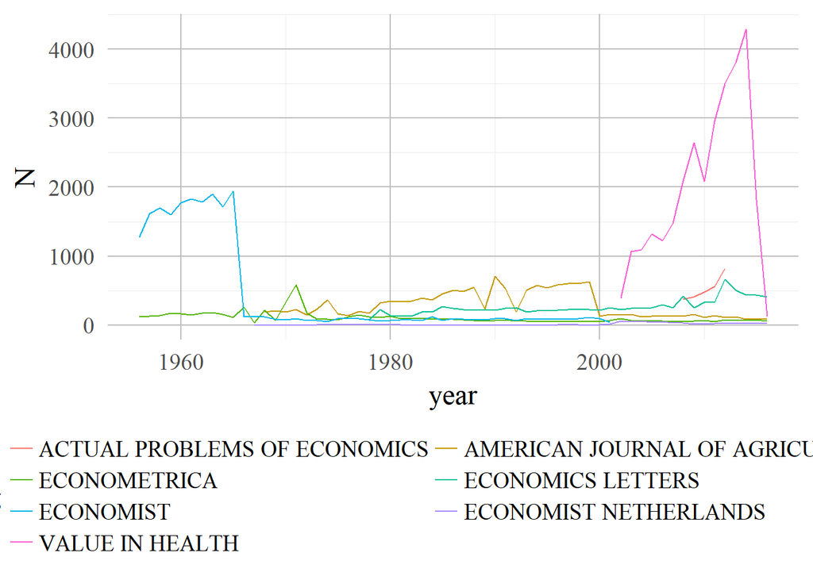

```r
## Fill empty SN with SN when abailable for other entry
nl[J9 %chin% nl[is.na(SN),unique(J9)],SN:=SN[!is.na(SN)][1],by=J9]
## Create table with more than 1 SN refers to a J9
SN2_J9 <- nl[!is.na(SN),SN,by=J9][,unique(.SD)][,.N,by=J9][N>1]
## Create table with more than 1 J9 refers to a SN
SN2_SN <- nl[!is.na(SN),SN,by=J9][J9 %chin% SN2_J9$J9][,unique(.SD)][order(-SN)]
## Create table where more than 1 J9 or SN refers to one or more J9 or SN.
## Selects from two serial numbers that refer to the same J9, those which also refers to two J9, creates a recoding table.
SN2_SN_J9 <- nl[!is.na(SN),SN,by=J9][,unique(.SD)][J9 %chin% SN2_SN$J9 | SN %chin% SN2_SN$SN][order(-SN)][,SN2_n:=.N,by=SN][,.SD][,SN2:=ifelse(length(SN) != 1,SN[SN2_n == 2],SN[1]),by=J9][,SN2:=ifelse(is.na(SN2),SN[1],SN2),by=J9][,SN:=SN2][,c("SN2_n","SN2"):=NULL][,unique(.SD)]
## Recode SN that only one SN
for (i in SN2_SN_J9[,J9]) nl[J9 == i,SN:=SN2_SN_J9[J9 == i,SN]]
## Selects from two J9/journal that refer to one SN the one with the higher year and replaces the older J9/journal
nl[!is.na(SN),journal:=journal[max(year) == year][1],by=SN]
nl[!is.na(SN),J9:=J9[max(year) == year][1],by=SN]

nl[,.N,.(year,journal_orig)][,.SD[journal_orig %chin% .SD[N>500,c("ECONOMIST NETHERLANDS",unique(journal_orig))]]][,ggplot(.SD,aes(y=N,x=year,color=journal_orig))+geom_line() + guides(color=guide_legend(nrow=4,byrow=TRUE))]
```

```r
nl[,.N,.(year,journal_orig)][,.SD[journal_orig %chin% .SD[N>500,c("ECONOMIST NETHERLANDS",unique(journal_orig))]]][order(-N)][,datatable(.SD)]
```

|  | year | journal_orig | N |
| --- | --- | --- | --- |
| 1 | 2014 | VALUE IN HEALTH | 4292 |
| 2 | 2013 | VALUE IN HEALTH | 3807 |
| 3 | 2012 | VALUE IN HEALTH | 3505 |
| 4 | 2011 | VALUE IN HEALTH | 2959 |
| 5 | 2009 | VALUE IN HEALTH | 2647 |
| 6 | 2008 | VALUE IN HEALTH | 2089 |
| 7 | 2010 | VALUE IN HEALTH | 2085 |
| 8 | 1965 | ECONOMIST | 1942 |
| 9 | 1963 | ECONOMIST | 1897 |
| 10 | 1961 | ECONOMIST | 1832 |

[output cut: 237 more lines]

```r
# Remove Economist before 1965 and "value in health for high number of articles per year
## Economist
nl[year <=1965 & journal_orig == "ECONOMIST"][,.N,.(journal_orig,year)][,datatable(.SD)]
```

|  | journal_orig | year | N |
| --- | --- | --- | --- |
| 1 | ECONOMIST | 1956 | 1273 |
| 2 | ECONOMIST | 1957 | 1621 |
| 3 | ECONOMIST | 1958 | 1694 |
| 4 | ECONOMIST | 1959 | 1600 |
| 5 | ECONOMIST | 1960 | 1776 |
| 6 | ECONOMIST | 1961 | 1832 |
| 7 | ECONOMIST | 1962 | 1786 |
| 8 | ECONOMIST | 1963 | 1897 |
| 9 | ECONOMIST | 1964 | 1713 |
| 10 | ECONOMIST | 1965 | 1942 |

```r
data.table(arts=nl[PID %chin% nl[year <=1965 & journal_orig == "ECONOMIST",PID],.N],citations=el[tPID %chin% nl[PID %chin% nl[year <=1965 & journal_orig == "ECONOMIST",PID],PID],.N],references=el[sPID %chin% nl[PID %chin% nl[year <=1965 & journal_orig == "ECONOMIST",PID],PID],.N])
```

```
##     arts citations references
## 1: 17134        13         12
```

```r
nl <- nl[!PID %chin% nl[year <=1965 & journal_orig == "ECONOMIST",PID]]
## Value in health
data.table(arts=nl[journal == "VALUE IN HEALTH",.N],citations=el[tPID %chin% nl[journal == "VALUE IN HEALTH",PID],.N],references=el[sPID %chin% nl[journal == "VALUE IN HEALTH",PID],.N])
```

```
##     arts citations references
## 1: 29903      3913       5718
```

```r
nl <- nl[journal != "VALUE IN HEALTH"]

# Manuel Checking
## export list with journal & j9 for manuel correction
write.csv(nl[,.N,by=c("J9","journal","year")][,first_year:=min(year),by=journal][,last_year:=max(year),by=journal][,J9n:=.N,by=J9][,journaln:=.N,by=journal][,N:=sum(N),by=journal][order(J9)][,-"year"][,unique(.SD)],
        "../../Daten/selection_lists/journal/recode.csv",row.names=F)
## Import manually recoded journals
recode <- as.data.table(read_xlsx("../../Daten/selection_lists/journal/recode_man3.xlsx"))[,merge_j:=ifelse(nchar(merge_j)==0,NA,merge_j)][!is.na(merge_j)]
## Recode journals where the names have been changed.
recode <- recode[!merge_j=="remove"]
recode[,journal_new:=journal][!is.na(merge_j),journal_new:=journal[last_year == max(last_year)][1],by=merge_j][!is.na(merge_j),J9_new:=J9[last_year == max(last_year)][1],by=merge_j]
recode <- recode[,data.table(journal,journal_new,J9,J9_new)][,unique(.SD)]
## add "JOURNAL OF ECONOMICS ZEITSCHRIFT FUR NATIONALOKONOMIE"
recode <- rbind(recode,data.table(journal="JOURNAL OF ECONOMICS ZEITSCHRIFT FUR NATIONALOKONOMIE", journal_new="JOURNAL OF ECONOMICS", J9="J ECON", J9_new="J ECON"))
## Recode
nl <- merge(nl,recode[,journal,journal_new][,unique(.SD)],by="journal",all.x=T)[,journal:=ifelse(is.na(journal_new),journal,journal_new)]
nl <- merge(nl,recode[,J9,J9_new][,unique(.SD)],by="J9",all.x=T)[,J9:=ifelse(is.na(J9_new),J9,J9_new)]
## stat
data.table(J=nl[,.N,journal][,.N],j2016=nl[year ==2016,.N,journal][,.N],j2014=nl[year ==2014,.N,journal][,.N])
```

```
##      J j2016 j2014
## 1: 548   435   343
```

```r
## Make list with journals that have been available for less then four years.
journal_keep <- nl[,data.table(first_year=min(year),last_year=max(year),dur=max(year)-min(year)+1),by=journal][order(dur)]

jour <- nl[,.N,.(year,journal)][,.(year=paste0(year,collapse=","),arts=sum(N),years=.N),.(journal)]
jour <- merge(journal_keep,jour,by="journal",all=T)
jourel <- merge(el,nl,by.x="tPID",by.y="PID")[,.(cits=.N),journal]
jour <- merge(jour,jourel,by="journal",all=T)
jourel <- merge(el,nl,by.x="sPID",by.y="PID")[,.(refs=.N),journal]
jour <- merge(jour,jourel,by="journal",all=T)
jour[,cits:=ifelse(is.na(cits),0,cits)][,refs:=ifelse(is.na(refs),0,refs)]
jour[,keep:=ifelse(arts<10 | refs <100 | years/dur<1/4 | years <2,F,T)]
datatable(merge(jour,nl[,henho,journal][,unique(.SD)],by="journal",all.x=T,all.y=F))
```

|  | journal | first_year | last_year | dur | year | arts | years | cits | refs | keep | henho |
| --- | --- | --- | --- | --- | --- | --- | --- | --- | --- | --- | --- |
| 1 | ACTA OECONOMICA | 1969 | 2016 | 48 | 2007,2008,2009,2010,2011,2012,2013,2014,2015,2016,1969,1970,1973,1974,1975,1976,1977,1978,1979,1980,1981,1982,1983,1984,1985,1986,1987,1988,1989,1990,1991,1992,1993,1994,1995 | 1738 | 35 | 869 | 2425 | True | 0 |
| 2 | ACTUAL PROBLEMS OF ECONOMICS | 2008 | 2012 | 5 | 2008,2009,2010,2011,2012 | 2652 | 5 | 0 | 1858 | True | 0 |
| 3 | ACTUALITE ECONOMIQUE | 1956 | 1978 | 23 | 1956,1957,1958,1959,1960,1961,1962,1963,1964,1965,1966,1967,1968,1969,1970,1971,1972,1973,1974,1975,1976,1977,1978 | 1563 | 23 | 39 | 371 | True | 0 |
| 4 | ADVANCES IN ECONOMETRICS | 1996 | 2006 | 11 | 1998,2000,2002,2003,2004,2006,1996 | 119 | 7 | 1012 | 1196 | True | 0 |
| 5 | AESTIMUM | 2015 | 2016 | 2 | 2015,2016 | 12 | 2 | 0 | 27 | False | 0 |
| 6 | AFRICAN JOURNAL OF AGRICULTURAL AND RESOURCE ECONOMICS AFJARE | 2015 | 2016 | 2 | 2015,2016 | 37 | 2 | 5 | 355 | True | 0 |
| 7 | AFRICAN REVIEW OF ECONOMICS AND FINANCE AREF | 2015 | 2015 | 1 | 2015 | 15 | 1 | 0 | 75 | False | 0 |
| 8 | AGENDA A JOURNAL OF POLICY ANALYSIS AND REFORM | 2015 | 2015 | 1 | 2015 | 6 | 1 | 0 | 18 | False | 0 |
| 9 | AGENT MEDIATED ELECTRONIC COMMERCE DESIGNING MECHANISMS AND SYSTEMS | 2002 | 2002 | 1 | 2002 | 20 | 1 | 2 | 32 | False | 0 |
| 10 | AGREKON | 2008 | 2016 | 9 | 2008,2009,2010,2011,2012,2013,2014,2015,2016 | 220 | 9 | 141 | 1147 | True | 0 |

[output cut: 538 more lines]

```r
data.table(J=nl[,.N,journal][,.N],j2016=nl[year ==2016,.N,journal][,.N],j2014=nl[year ==2014,.N,journal][,.N])
```

```
##      J j2016 j2014
## 1: 548   435   343
```

In total we remove 115 of 548, 22803 articles and 8700 citations. The removed journals are in total only 1141 cited.

```r
# stats
data.table(J9_J=nl[,.N,.(J9,journal)][,.N], J9_J_9=nl[,J9,journal][,unique(.SD)][,.N,by=journal][,.N], J9_J_J9=nl[,J9,by=journal][,unique(.SD)][,.N,by=J9][,.N])
```

```
##    J9_J J9_J_9 J9_J_J9
## 1:  548    548     548
```

```r
data.table(J=nl[,.N,journal][,.N],j2016=nl[year ==2016,.N,journal][,.N],j2014=nl[year ==2014,.N,journal][,.N])
```

```
##      J j2016 j2014
## 1: 548   435   343
```

```r
data.table(arts=nl[,.N],remarts=nl[,.N] - nl[journal %chin% jour[keep==T,journal],.N],cits=el[,.N])
```

```
##      arts remarts    cits
## 1: 607671   22803 3564765
```

```r
data.table(jou_keep=nl[journal %chin% jour[keep==T,journal]][,.N,journal][,.N],jour_keep2014=nl[journal %chin% jour[keep==T,journal]][year==2014,.N,journal][,.N],jour_keep2016=nl[journal %chin% jour[keep==T,journal]][year==2016,.N,journal][,.N])
```

```
##    jou_keep jour_keep2014 jour_keep2016
## 1:      433           342           384
```

```r
data.table(
    ## Citations of removed journals
    cit_rem=el[sPID %chin% nl[,PID] & tPID %chin% nl[,PID],.N] - el[sPID %chin% nl[journal %chin% jour[keep==T,journal],PID] & tPID %chin% nl[journal %chin% jour[keep==T,journal],PID],.N],
    ## Citations to removed journals
    cit_remJ=el[sPID %chin% nl[,PID] & tPID %chin% nl[journal %chin% jour[keep==F,journal],PID],.N],
    ## References from removed journals
    ref_remJ=el[sPID %chin% nl[journal %chin% jour[keep==F,journal],PID] & tPID %chin% nl[,PID],.N]
)
```

```
##    cit_rem cit_remJ ref_remJ
## 1:    8700     1141     7800
```

```r
## Remove articles from dataset
nl <- nl[journal %chin% jour[keep==T,journal]]
el <- el[sPID %chin% nl[,PID] & tPID %chin% nl[,PID]]

# stats
data.table(J9_J=nl[,.N,.(J9,journal)][,.N], J9_J_9=nl[,J9,journal][,unique(.SD)][,.N,by=journal][,.N], J9_J_J9=nl[,J9,by=journal][,unique(.SD)][,.N,by=J9][,.N])
```

```
##    J9_J J9_J_9 J9_J_J9
## 1:  433    433     433
```

```r
data.table(J=nl[,.N,journal][,.N],j2016=nl[year ==2016,.N,journal][,.N],j2014=nl[year ==2014,.N,journal][,.N])
```

```
##      J j2016 j2014
## 1: 433   384   342
```

```r
data.table(arts=nl[,.N],remarts=nl[,.N] - nl[journal %chin% jour[keep==T,journal],.N],cits=el[,.N])
```

```
##      arts remarts    cits
## 1: 584868       0 3548472
```

```r
data.table(jou_kee=nl[journal %chin% jour[keep==T,journal]][,.N,journal][,.N],jour_keep2014=nl[journal %chin% jour[keep==T,journal]][year==2014,.N,journal][,.N],jour_keep2016=nl[journal %chin% jour[keep==T,journal]][year==2016,.N,journal][,.N])
```

```
##    jou_kee jour_keep2014 jour_keep2016
## 1:     433           342           384
```

```r
data.table(
    ## Citations of removed journals
    cit_rem=el[sPID %chin% nl[,PID] & tPID %chin% nl[,PID],.N] - el[sPID %chin% nl[journal %chin% jour[keep==T,journal],PID] & tPID %chin% nl[journal %chin% jour[keep==T,journal],PID],.N],
    ## Citations to removed journals
    cit_remJ=el[sPID %chin% nl[,PID] & tPID %chin% nl[journal %chin% jour[keep==F,journal],PID],.N],
    ## References from removed journals
    ref_remJ=el[sPID %chin% nl[journal %chin% jour[keep==F,journal],PID] & tPID %chin% nl[,PID],.N]
)
```

```
##    cit_rem cit_remJ ref_remJ
## 1:       0        0        0
```

## Remove not needed document types

We keep items of the following item type

ARTICLE, ARTICLE; PROCEEDINGS PAPER, REVIEW, NOTE, ARTICLE; BOOK CHAPTER, REVIEW; BOOK CHAPTER, ARTICLE; RETRACTED PUBLICATION, DATABASE REVIEW, SOFTWARE REVIEW, HARDWARE REVIEW

Further we remove articles with less than 10 citations of the following item type:

EDITORIAL MATERIAL, LETTER, BOOK REVIEW, MEETING ABSTRACT, DISCUSSION, EDITORIAL MATERIAL; BOOK CHAPTER

```r
# stat
data.table(J=nl[,.N,journal][,.N],j2016=nl[year ==2016,.N,journal][,.N],j2014=nl[year ==2014,.N,journal][,.N])
```

```
##      J j2016 j2014
## 1: 433   384   342
```

```r
data.table(arts=nl[,.N],cits=el[,.N])
```

```
##      arts    cits
## 1: 584868 3548472
```

```r
# Read types
DT_k <- fread("../../Daten/selection_lists/document_type_keep.csv",header=F)[,V1]
DT_thr <- fread("../../Daten/selection_lists/document_type_thres.csv",header=T)[,x]
## Cote articles to remove
nl[,remDT:=ifelse(DT %chin% DT_k,"keep","remove")]
nl[,remDT:=ifelse(PID %chin% el[,.N,tPID][N>9][tPID %chin% nl[DT %chin% DT_thr,PID]][,tPID],"keep",remDT)]

# Create overview table
xt <- merge(nl[,.(Frequency=.N),DT],merge(el,nl[,DT,PID],by.x="tPID",by.y="PID")[,.(Citations=.N),DT],by="DT",all=T)[,Citations:=ifelse(is.na(Citations),0,Citations)][,`Citations per item`:=Citations/Frequency]
zero_cit <- nl[!PID %chin% el[,tPID]][,.(`Items with 0 citations`=.N),DT]
xt <- merge(xt,zero_cit,by="DT",all=T)[,`Items with 0 citations`:=ifelse(is.na(`Items with 0 citations`),0,`Items with 0 citations`)]
removed_arts <- nl[remDT=="remove",.(`Removed items`=.N),DT]
xt <- merge(xt,removed_arts,by="DT",all=T)[,`Removed items`:=ifelse(is.na(`Removed items`),0,`Removed items`)]
removed_cit <- merge(nl[remDT=="remove",PID,DT],el,by.x="PID",by.y="tPID")[,.(`Removed citations`=.N),DT]
xt <- merge(xt,removed_cit,by="DT",all=T)[,`Removed citations`:=ifelse(is.na(`Removed citations`),0,`Removed citations`)]
xt[,gr:=ifelse(DT %chin% DT_k,1,NA)][,gr:=ifelse(DT %chin% DT_thr,2,gr)][,gr:=ifelse(is.na(gr),3,gr)]
setorder(xt,gr,-Frequency)
xt[,gr:=NULL]
fltoupper <- function(x) gsub("(^|[[:space:]]|,|;)([[:alpha:]])", "\\1\\U\\2", tolower(x), perl=TRUE)
xt[,DT:=fltoupper(DT)]

xt <- rbind(xt,xt[,-1][,lapply(.SD,sum)][,DT:="All items"][,.SD][,`Citations per item`:=xt[,mean(`Citations per item`)]],fill=T)
setnames(xt,"DT","Research Item")
## Export table to word with overview on removed items.
doc <- docx(title = "tables_report", list.definition = getOption("ReporteRs-list-definition"))
doc <- addParagraph( doc,c("","",""));doc <- addFlexTable(doc, FlexTable( data = xt,add.rownames=T))
writeDoc(doc, file = paste0("../../../WU Intern/Research/Report_WP1/export_word/removed_items_2016EC.docx"))

## Settings
dig <- matrix(c(rep(0,4*dim(xt)[1]),rep(2,dim(xt)[1]),rep(0,3*dim(xt)[1])),ncol=8)
alg <- c("L{5cm}","R{1.3cm}","R{1.3cm}","R{1.3cm}","R{1.3cm}","R{1.3cm}","R{1.3cm}")
cap <- "Overview on research items"
lab <- c("table:res_item")
## for formatting (will be removed later again)
xt[,`Research Item`:=ifelse(`Research Item` %chin% fltoupper(DT_k),paste0("1_inkl_",`Research Item`),`Research Item`)][,`Research Item`:=ifelse(`Research Item` %chin% fltoupper(DT_thr),paste0("2_thres_",`Research Item`),`Research Item`)]
bold.somerows <- function(x) {x <- gsub('1_inkl_(.*)',paste('\\\\textbf{\\1','}'),x); x <- gsub('2_thres_(.*)',paste('\\\\textit{\\1','}'),x) }
## Print
xt <- xtable(xt,caption=cap,align=c("r",alg),label=lab,digits=dig) #
print(xt,type="latex",hline.after=c(-1,-1,0,10,16,26,27,27),table.placement="!htbp",
        file="../EconConcentration/export_latex/annex_research_items.tex", size="\\scriptsize", sanitize.text.function = bold.somerows,
        include.rownames=F,format.args=list(big.mark = ","))

## word file
doc <- officer::read_docx()

# Word Export
doc <- body_add_break(doc, pos = "after")
doc <- body_add_par(doc, paste0("Table 7: ", cap), style = NULL, pos = "after")
doc <- body_add_par(doc, "", style = NULL, pos = "after")
doc <- body_add_flextable(doc, value = xtable_to_flextable(xt), pos = "after")
doc <- body_add_par(doc, "", style = NULL, pos = "after")
doc <- body_add_par(doc, "", style = NULL, pos = "after")
print(doc, target = "export_word/tables.docx")
```

```
## [1] "C:/Files/Dropbox/1 Projekte/1 Citations/Citation Analysis/Auswertungen/EconConcentration/export_word/tables.docx"
```

```r
## total
data.table(arts=nl[remDT=="remove",.N],ref=el[sPID %chin% nl[remDT=="remove",PID],.N],cits=el[tPID %chin% nl[remDT=="remove",PID],.N])
```

```
##      arts   ref  cits
## 1: 164018 49962 21071
```

```r
## remove total
data.table(remarts=nl[remDT=="remove",.N],remref=el[sPID %chin% nl[remDT=="remove",PID],.N],remcits=el[tPID %chin% nl[remDT=="remove",PID],.N])
```

```
##    remarts remref remcits
## 1:  164018  49962   21071
```

```r
data.table(keeparts=nl[remDT=="keep",.N],keepref=el[sPID %chin% nl[remDT=="keep",PID],.N],keepcits=el[tPID %chin% nl[remDT=="keep",PID],.N])
```

```
##    keeparts keepref keepcits
## 1:   420850 3498510  3527401
```

```r
## remove because of threshold
data.table(arts=nl[DT %chin% DT_thr,.N],refs=el[sPID %chin% nl[DT %chin% DT_thr,PID],.N],cits=el[tPID %chin% nl[DT %chin% DT_thr,PID],.N])
```

```
##      arts  refs  cits
## 1: 159888 50729 34088
```

```r
data.table(remarts=nl[remDT=="remove"  & DT %chin% DT_thr,.N],remref=el[sPID %chin% nl[remDT=="remove"  & DT %chin% DT_thr,PID],.N],remcits=el[tPID %chin% nl[remDT=="remove"  & DT %chin% DT_thr,PID],.N])
```

```
##    remarts remref remcits
## 1:  159259  46178   18564
```

```r
data.table(keeparts=nl[remDT=="keep"  & DT %chin% DT_thr,.N],keepref=el[sPID %chin% nl[remDT=="keep"  & DT %chin% DT_thr,PID],.N],keepcits=el[tPID %chin% nl[remDT=="keep"  & DT %chin% DT_thr,PID],.N])
```

```
##    keeparts keepref keepcits
## 1:      629    4551    15524
```

```r
## remove category
data.table(arts=nl[!DT %chin% DT_thr,.N],ref=el[sPID %chin% nl[!DT %chin% DT_thr,PID],.N],cits=el[tPID %chin% nl[!DT %chin% c(DT_thr,DT_k),PID],.N])
```

```
##      arts     ref cits
## 1: 424980 3497743 2507
```

```r
data.table(remarts=nl[remDT=="remove"  & !DT %chin% DT_thr,.N],remref=el[sPID %chin% nl[remDT=="remove"  & !DT %chin% c(DT_thr,DT_k),PID],.N],remcits=el[tPID %chin% nl[remDT=="remove"  & !DT %chin% DT_thr,PID],.N])
```

```
##    remarts remref remcits
## 1:    4759   3784    2507
```

```r
data.table(keeparts=nl[remDT=="keep"  & !DT %chin% DT_thr,.N],keepref=el[sPID %chin% nl[remDT=="keep"  & !DT %chin% c(DT_thr,DT_k),PID],.N],keepcits=el[tPID %chin% nl[remDT=="keep"  & !DT %chin% DT_thr,PID],.N])
```

```
##    keeparts keepref keepcits
## 1:   420221       0  3511877
```

```r
datatable(xt)
```

|  | Research Item | Frequency | Citations | Citations per item | Items with 0 citations | Removed items | Removed citations |
| --- | --- | --- | --- | --- | --- | --- | --- |
| 1 | 1_inkl_Article | 375571 | 3154999 | 8.40053944527133 | 130809 | 0 | 0 |
| 2 | 1_inkl_Article; Proceedings Paper | 20192 | 215260 | 10.6606576862124 | 4779 | 0 | 0 |
| 3 | 1_inkl_Note | 18618 | 70188 | 3.76990009668063 | 10661 | 0 | 0 |
| 4 | 1_inkl_Review | 4925 | 68507 | 13.9100507614213 | 1843 | 0 | 0 |
| 5 | 1_inkl_Article; Book Chapter | 508 | 2072 | 4.07874015748031 | 167 | 0 | 0 |
| 6 | 1_inkl_Software Review | 363 | 270 | 0.743801652892562 | 258 | 0 | 0 |
| 7 | 1_inkl_Review; Book Chapter | 36 | 576 | 16 | 4 | 0 | 0 |
| 8 | 1_inkl_Article; Retracted Publication | 4 | 5 | 1.25 | 0 | 0 | 0 |
| 9 | 1_inkl_Database Review | 2 | 0 | 0 | 2 | 0 | 0 |
| 10 | 1_inkl_Hardware Review | 2 | 0 | 0 | 2 | 0 | 0 |

[output cut: 17 more lines]

```r
## Remove references of not used document type
nl <- nl[remDT=="keep"][,remDT:=NULL]
el <- el[sPID %chin% nl[,PID] & tPID %chin% nl[,PID]]

#stat
data.table(J=nl[,.N,journal][,.N],j2016=nl[year ==2016,.N,journal][,.N],j2014=nl[year ==2014,.N,journal][,.N])
```

```
##      J j2016 j2014
## 1: 433   384   342
```

```r
## Top 20 items within the threshold subset of document types
datatable(merge(el,nl[DT %chin% DT_thr][,.(PID,author,title,DT)],by.x="tPID",by.y="PID")[,.N,.(author,title,DT)][order(-N)][1:20])
```

|  | author | title | DT | N |
| --- | --- | --- | --- | --- |
| 1 | MODIGLIANI_F,MILLER_MH | CORPORATE-INCOME TAXES AND THE COST OF CAPITAL - A CORRECTION | BOOK REVIEW | 376 |
| 2 | PAULY_MV | ECONOMICS OF MORAL HAZARD - REPLY | LETTER | 210 |
| 3 | CHRISTENSEN_LR,LAU_LJ,JORGENSON_DW | CONJUGATE DUALITY AND TRANSCENDENTAL LOGARITHMIC FUNCTION | MEETING ABSTRACT | 207 |
| 4 | HENDRY_DF | ECONOMETRIC MODELING WITH COINTEGRATED VARIABLES - AN OVERVIEW | EDITORIAL MATERIAL | 159 |
| 5 | SVENSSON_J | EIGHT QUESTIONS ABOUT CORRUPTION | EDITORIAL MATERIAL | 153 |
| 6 | NELSON_CR,SCHWERT_GW | SHORT-TERM INTEREST-RATES AS PREDICTORS OF INFLATION - TESTING HYPOTHESIS THAT REAL RATE OF INTEREST IS CONSTANT | LETTER | 149 |
| 7 | LUCAS_RE | MACROECONOMIC PRIORITIES | EDITORIAL MATERIAL | 148 |
| 8 | GOODWIN_PB | A REVIEW OF NEW DEMAND ELASTICITIES WITH SPECIAL REFERENCE TO SHORT AND LONG-RUN EFFECTS OF PRICE CHANGES | EDITORIAL MATERIAL | 137 |
| 9 | THALER_RH | ANOMALIES - SAVING, FUNGIBILITY, AND MENTAL ACCOUNTS | EDITORIAL MATERIAL | 136 |
| 10 | BARRETT_CB,REARDON_T,WEBB_P | NONFARM INCOME DIVERSIFICATION AND HOUSEHOLD LIVELIHOOD STRATEGIES IN RURAL AFRICA: CONCEPTS, DYNAMICS, AND POLICY IMPLICATIONS | EDITORIAL MATERIAL | 131 |

[output cut: 10 more lines]

## Author Recoding

```r
# Replace authors according to recoding list
fun.clean.auth <- function(x) gsub("[^_,A-z]","",gsub("; ",",",gsub(", ","_",x)))
nl[,author:=fun.clean.auth(author_orig)]

## Read dictionary with recoded authors
au <- fread("../../Daten/selection_lists/author_recoding.csv")[!is.na(merge),c(4,5)]
## CreateReplacement column
au[,author_repl:=author[1],by=merge]
au <- au[author != author_repl]
## Create data frame with PID and author
aut <- nl[,strsplit(author,","),by=PID][,auth_position:=1:.N,by=c("PID")][,data.table(PID,author=V1,auth_position)]
## Merge with recode data and melt
aut <- merge(aut[!is.na(author) & author != "[ANONYMOUS]"],au,by="author",all.x=T)[,author:=ifelse(is.na(author_repl),author,author_repl)][order(auth_position),paste0(author,collapse=","),by=PID][,data.table(PID,author_new=V1)]
## merge with nl list
nl <- merge(nl,aut,by="PID",all.x=T)[,author:=ifelse(is.na(author_new),author,author_new)][,author_new:=NULL]
```

## Region and institutions recoding

```r
# Incites
nl[,cou_incites:=cou][,inst_incites:=inst][,cou:=NULL][,inst:=NULL]


# Adapt Incites Inst and C1 / RPAF
inst_inc <- nl[,strsplit(inst_incites,","),PID]
## remove non-unis
non_uni <- c("UNIVER_LONDON","CENTRE_ECONOM_POLICY_RESEAR_UK","instoth","ASIA_PACIFI","UNIVER_COLLEG_LONDON")
inst_inc <- inst_inc[!V1 %chin% non_uni]
## Recode institutions
inst_inc_C1_rec <- fread("../../Daten/selection_lists/inst_adapt_C1_Incites_man.csv")[recode==1 & inst_inc != inst_recode][,.(inst_inc,inst_recode)][,unique(.SD)]
### Merge Manually recoded
pasteNA <- function(x) paste(x[!is.na(x)],collapse=",")
inst_inc <- merge(inst_inc,inst_inc_C1_rec,by.x="V1",by.y="inst_inc",all.x=T)[,inst:=ifelse(is.na(inst_recode),V1,inst_recode)][,pasteNA(inst),PID][,.(PID,inst_incites=ifelse(nchar(V1)<1,NA,V1))]
nl <- merge(nl[,inst_incites:=NULL],inst_inc,by="PID",all.x=T)


# Adapt Incites Cou and C1 / RPAF and add Region to incites
cou_inc <- nl[,strsplit(cou_incites,","),PID]
cou_repl <- data.table(cou_inc=c("ABB","BP","CENT_AFR_REPUBL","CHINA_MAINLAND","CONGO_PEOPLES_REP","EON","FRENCH_GUIANA","GERMANY_FED_REP_GER","GERMANY_GER_DEM_REP","MACAU","MAURITANIA","SAMOA","SAP"), cou_recode=c(NA,NA,"CENT_AFR_REPUBL","CHINA","CONGO_DEMOCRATIC_REPUBLIC",NA,NA,"GERMANY","GERMANY",NA,"MAURITIUS",NA,NA))
cou_inc <- merge(cou_inc,cou_repl,by.x="V1",by.y="cou_inc",all.x=T)[,cou:=ifelse(is.na(cou_recode),V1,cou_recode)][,(c("V1","cou_recode")):=NULL]
cou_inc <- merge(cou_inc,fread("../../Daten/selection_lists/country_region_conc.csv"),by.x="cou",by.y="cou",all.x=T)
cou_inc <- cou_inc[,lapply(.SD,pasteNA),by="PID",.SDcols=c("cou","reg")][,.SD][,.(PID,cou_incites=ifelse(nchar(cou)<1,NA,cou),reg_incites=ifelse(nchar(reg)<1,NA,reg))]
nl <- merge(nl[,cou_incites:=NULL][,reg_incites:=NULL],cou_inc,by="PID",all.x=T)
```

## Finalise Article and Citation Dataset

```r
# Times Cited
nl[,TCm:=NULL]
nl <- merge(nl,el[,.N,by=tPID][,data.table(PID=tPID,TCm=N)],by="PID",all=T)

# Number of references
nl[,NRm:=NULL]
nl <- merge(nl,el[,.N,by=sPID][,data.table(PID=sPID,NRm=N)],by="PID",all=T)

# Update duplicated keys column
nl[,key_level_dupl:=NULL]
nl[!is.na(key) & dupl(key),key_level_dupl:=TRUE]

# Overview on Articles and Citations with, without and only duplicates
cols <- c("Articles","Citations")
stats <- list()
## All Entries
stat <- nl[!is.na(key),data.table(Articles=.N,Citations=sum(TCm,na.rm=T),sample="withdups"),by=key_level]
stats[["withdups"]] <- rbind(stat,stat[,c(key_level="total",lapply(.SD,sum),sample="withdups"),.SDcols=cols])
## Without Duplicates
stat <- nl[is.na(key_level_dupl) & !is.na(key),data.table(Articles=.N,Citations=sum(TCm,na.rm=T),sample="withoutdups"),by=key_level]
stats[["withoutdups"]] <- rbind(stat,stat[,c(key_level="total",lapply(.SD,sum),sample="withoutdups"),.SDcols=cols])
## Only Duplicates
stat <- nl[!is.na(key_level_dupl),data.table(Articles=.N,Citations=sum(TCm,na.rm=T),sample="dups"),by=key_level]
stats[["dups"]] <-  rbind(stat,stat[,c(key_level="total",lapply(.SD,sum),sample="dups"),.SDcols=cols])
```

The following table gives an overview on the final dataset.

|  | key_level | Articles | Citations | sample |
| --- | --- | --- | --- | --- |
| 1 | key_fyjvpd | 235630 | 2931172 | withdups |
| 2 | key_fyjvp | 47522 | 524066 | withdups |
| 3 | key_fyjv | 4707 | 6250 | withdups |
| 4 | key_fyjv_ADDX | 511 | 421 | withdups |
| 5 | key_d | 315 | 1117 | withdups |
| 6 | key_fyjvd | 1532 | 16908 | withdups |
| 7 | key_fyjvp_ADDX | 13 | 86 | withdups |
| 8 | key_fyjvpd_ADDX | 3 | 11 | withdups |
| 9 | total | 290233 | 3480031 | withdups |
| 10 | key_fyjvpd | 235630 | 2931172 | withoutdups |

[output cut: 9 more lines]

```r
# Export Local
# Export Citations
# write.csv(el,"C:/Users/ernes/Documents/CA/el_SJ_afterPP_ECON2016.csv",row.names=F)
write.csv(el,"C:/Files/Files/CA/el_SJ_afterPP_ECON2016.csv",row.names=F)
# Export Articles
# write.csv(nl,"C:/Users/ernes/Documents/CA/nl_SJ_afterPP_ECON2016.csv",row.names=F)
write.csv(nl,"C:/Files/Files/CA/nl_SJ_afterPP_ECON2016.csv",row.names=F)

# Export to Dropbox
## Export Citations
# write.csv(el[,data.table(source=sPID,target=tPID,ELID)],"C:/Files/Files/CA/el_ECON2016.csv",row.names=F)
## Export Articles
# cols <- c("PID","author","year","journal","doi","title","keywords","keywordsEd","jel","abstract","region","cou","inst","henho","hencat","volume","TC","NR","DT","WC","TCm")
# write.csv(nl[,cols,with=F],"../../Daten/nl.csv",row.names=F)
```

## Reload data and select used columns

```r
# Load Data
# el <- fread("../../Daten/el.csv",verbose=F)
# el <- fread("C:/Files/Files/CA/el.csv",verbose=F)
el <- fread("C:/Files/Files/CA/el_SJ_afterPP_ECON2016.csv",verbose=F)[,.(source=sPID,target=tPID,ELID)]
# nl <- fread("../../Daten/nl.csv",verbose=F)
# nl <- fread("C:/Files/Files/CA/nl.csv",verbose=F)

names_old <- c("PID", "author", "year", "journal", "doi", "title", "region", "cou", "inst", "henho",
"hencat", "volume", "TC", "NR", "DT", "WC", "TCm")
nl <- fread("C:/Files/Files/CA/nl_SJ_afterPP_ECON2016.csv",verbose=F)
setnames(nl,"cou_incites","cou")
setnames(nl,"inst_incites","inst")
setnames(nl,"reg_incites","region")
nl <- nl[,names_old,with=F]

nl[,henho:=ifelse(henho==1,"het","ort")]
nl <- nl[grepl("ECONOMICS",WC) & year <=2016]
el <- el[source %chin% nl[,PID] & target %chin% nl[,PID]]
```

## Create subsamples

```r
# Subsamples
NLs <- list()
NLs[["ECON_2016"]] <- nl[journal %chin% nl[year == 2016,unique(journal)] & grepl("ECONOMICS",WC)]


NLs[["ECON"]] <- nl[grepl("ECONOMICS",WC) & year <=2016]
NLs[["ECON_1980"]] <- nl[grepl("ECONOMICS",WC) & year >= 1980 & year <= 2014]
# Subsamples of Edgelists
ELs <- list()
ELs[["ECON_2016"]] <-  el[target %chin% NLs[["ECON_2016"]][,PID] & source %chin% NLs[["ECON_2016"]][,PID]]
ELs[["ECON"]] <- el[target %chin% NLs[["ECON"]][,PID] & source %chin% NLs[["ECON"]][,PID]]
ELs[["ECON_1980"]] <- el[target %chin% NLs[["ECON_1980"]][,PID] & source %chin% NLs[["ECON_1980"]][,PID]]
```

# Data Overview

## Table: Overview on the three discussed subsamples

```r
# Create Table
fun.ovw.tab <- function(x=nl,y=el) {
                        y <- y[target %chin% x[,PID] & source %chin% x[,PID]]
                        data.table(x[!PID %chin% y[,target],.N] / x[,.N]*100, # zero cit
                                   x[PID %chin% y[,target],.N],  # cited articles
                                   y[,.N], # total citations
                                   x[!PID %chin% y[,.N,target][,target],Gini(c(rep(0,.N),y[,.N,target][,N]))], # gini of citations per article
                                   y[,.N,target][,Gini(N)], # gini of citations
                                   x[!PID %chin% y[,.N,target][,target],max(c(rep(0,.N),y[,.N,target][,N]))], # most cited article
                                   x[!PID %chin% y[,.N,target][,target],mean(c(rep(0,.N),y[,.N,target][,N]))], # mean citations
                                   x[!PID %chin% y[,.N,target][,target],median(c(rep(0,.N),y[,.N,target][,N]))], #median citations
                                   x[!PID %chin% y[,.N,target][,target],sd(c(rep(0,.N),y[,.N,target][,N]))], # standard diviation
                                   # y[,.N,target][,sd(N)],  # standard diviation
                                   x[,.N] # total articles
                                    )
                                }
xt <- rbindlist(lapply(seq_along(NLs), function(x) fun.ovw.tab(NLs[[x]],el)))
xt <- as.data.frame(t(xt))
## Name
cols <- c("Share of articles with zero citations",
                    "Cited articles",
                    "Total citations",
                    "Gini of citations per article",
                    "Gini of citations per cited article",
                    "Citations of the most highly cited article",
                    "Mean citations per article",
                    "Median citations per article",
                    "Standard deviation of citations per article",
                    "Total articles")
rownames(xt) <- unlist(cols)
xt <- xt[,c(2,1,3)]
colnames(xt) <- c("All journals","2016 journals","1980-2014")
## Sort
 xt <- xt[c(10,2,3,1,7,8,6,9,4,5),]
# Make xtable
dig <- matrix(c(rep(0,10),rep(c(0,0,0,2,2,0,0,2,2,2),3)),ncol=4)
cap <- "Overview on the three discussed subsamples"
alg <- c("l","r","r","r")
lab <- c("table:annex_ovw")

xt <- xtable(xt,align=alg,digits=dig,caption=cap,label=lab)
print(xt,type="latex",hline.after=c(-1,-1,0,dim(xt)[1],dim(xt)[1]),table.placement="!htbp",
        file="export_latex/annex_ovw.tex", size="\\scriptsize",
        format.args=list(big.mark = ","))


# Word Export
doc <- body_add_break(doc, pos = "after")
doc <- body_add_par(doc, paste0("Table 1: ", cap), style = NULL, pos = "after")
doc <- body_add_par(doc, "", style = NULL, pos = "after")
doc <- body_add_flextable(doc, value = xtable_to_flextable(xt), pos = "after")
doc <- body_add_par(doc, "", style = NULL, pos = "after")
doc <- body_add_par(doc, "Notes", style = NULL, pos = "after")
doc <- body_add_par(doc, "a The total sample of all articles and citations listed in the Web of Science subject category economics between 1956 and 2016. This sample is used for the analysis for article, journal, and author concentration.", style = NULL, pos = "after")
doc <- body_add_par(doc, "b The restricted sample covering all articles and citations of journals that were still being published in 2016. This sample is used for the analysis of paradigmatic concentration.", style = NULL, pos = "after")
doc <- body_add_par(doc, "c The sample covers the time period for which data on affiliation is available in the InCites database.", style = NULL, pos = "after")
doc <- body_add_par(doc, "This sample is used for the analysis of geographic and institutional concentration.", style = NULL, pos = "after")
doc <- body_add_par(doc, "", style = NULL, pos = "after")
doc <- body_add_par(doc, "", style = NULL, pos = "after")

print(doc, target = "export_word/tables.docx")
```

```
## [1] "C:/Files/Dropbox/1 Projekte/1 Citations/Citation Analysis/Auswertungen/EconConcentration/export_word/tables.docx"
```

```r
# Plot
datatable(xt)
```

|  | All journals | 2016 journals | 1980-2014 |
| --- | --- | --- | --- |
| Total articles | 420850 | 383961 | 318094 |
| Cited articles | 269635 | 262121 | 207711 |
| Total citations | 3480031 | 3416455 | 2462698 |
| Share of articles with zero citations | 35.9308542235951 | 31.732389487474 | 34.7013775802121 |
| Mean citations per article | 8.26905310680766 | 8.89792192436212 | 7.74204480436601 |
| Median citations per article | 1 | 2 | 2 |
| Citations of the most highly cited article | 4386 | 4301 | 3963 |
| Standard deviation of citations per article | 37.0214446598516 | 38.1361484992421 | 31.7880565292496 |
| Gini of citations per article | 0.817123442722359 | 0.803826732757156 | 0.803485926355521 |
| Gini of citations per cited article | 0.714563765348359 | 0.712640788552502 | 0.699053262745512 |

## Figure: Number of articles and citations each year, 1956-2016

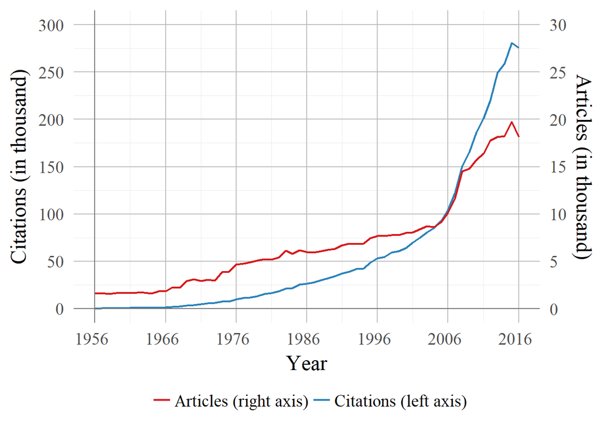

```r
xt <- merge(NLs[["ECON"]][,.N,by=year],
            merge(ELs[["ECON"]],NLs[["ECON"]][,PID,year],by.x="source",by.y="PID")[,.N,by=year],
            by="year")
setnames(xt,2:3,c("pub_art_sou","cit_sou"))

g <-
ggplot(xt,aes(x=year)) +
    geom_line(aes(y = cit_sou/1000,color="Citations (left axis)"),size=0.8) +
    geom_line(aes(y = pub_art_sou/100,color="Articles (right axis)"),size=0.8) +
    scale_x_continuous(breaks=seq(1956, 2016, 10)) +
    scale_y_continuous(breaks=c(seq(0,300,50)), limits =c(0,300), sec.axis = sec_axis(~./10,name = "Articles (in thousand)",breaks=seq(0,30,5))) +
    scale_colour_manual(name="",values=c("#d7191c", "#2b83ba")) +
    ylab("Citations (in thousand)") + xlab("Year") +
    theme(axis.text.x = element_text(hjust = 0.6)) +
    geom_hline(yintercept = 0,color="#777777") +
    geom_vline(xintercept = 1956,color="#777777") +
    theme(axis.text.x = element_text(hjust = 0.6))
g$vp = grid::viewport(height=1, width=1)
## Plot
g
```

```r
ggsave(file="export_latex/ovw_pub_cit_2ax.pdf",width=20,height=20,units="cm",dpi = 600, device = "pdf")
ggsave(file="export_tiff/fig1.tiff",width=20,height=20,units="cm",dpi = 600, device = "tiff")
doc <- body_add_break(doc, pos = "after")
doc <- body_add_par(doc, "Figure 1: Number of articles and citations each year, 1956-2016", style = NULL, pos = "after")
doc <- body_add_gg(doc, g , style = "centered",width=4,height=4)
doc <- body_add_par(doc, "", style = NULL, pos = "after")
print(doc, target = "export_word/tables.docx")
```

```
## [1] "C:/Files/Dropbox/1 Projekte/1 Citations/Citation Analysis/Auswertungen/EconConcentration/export_word/tables.docx"
```

```r
datatable(xt)
```

|  | year | pub_art_sou | cit_sou |
| --- | --- | --- | --- |
| 1 | 1956 | 1575 | 15 |
| 2 | 1957 | 1631 | 133 |
| 3 | 1958 | 1545 | 234 |
| 4 | 1959 | 1641 | 336 |
| 5 | 1960 | 1664 | 506 |
| 6 | 1961 | 1621 | 699 |
| 7 | 1962 | 1684 | 807 |
| 8 | 1963 | 1669 | 846 |
| 9 | 1964 | 1608 | 847 |
| 10 | 1965 | 1826 | 1066 |

[output cut: 51 more lines]

## Figure: Number of published and cited journals each year, 1956-2016

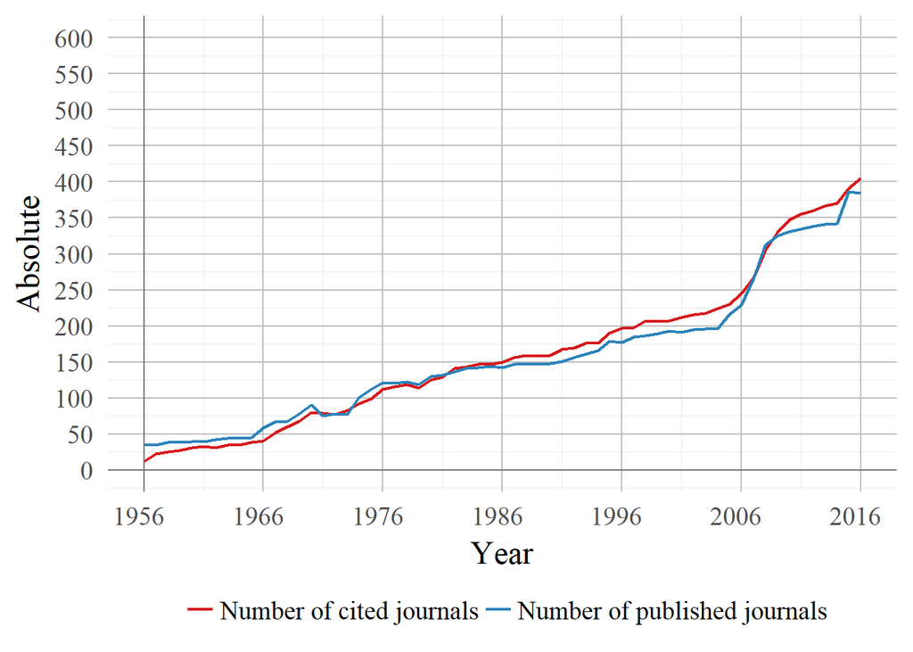

```r
jou_pub <- unique(NLs[["ECON"]][,data.table(year,journal)])[,.N,by=year]
jou_cit <- merge(ELs[["ECON"]],NLs[["ECON"]][,PID,journal],by.x="target",by.y="PID")[,data.table(source,journal)]
jou_cit <- merge(jou_cit,NLs[["ECON"]][,PID,year],by.x="source",by.y="PID")[,unique(data.table(year,journal))][,.N,by=year]
jou <- merge(jou_pub,jou_cit,by="year",suffixes=c("pubs","cits"))
jou <- melt(jou,id.vars="year")
jou[,variable:=factor(variable,levels=sort(unique(variable),decreasing=T))]
setorder(jou,-variable)
## Plot
g <-
ggplot(jou) + geom_line(aes(y = value,x=year,color=variable,group=variable),size=0.8) +
    scale_x_continuous(breaks=seq(1956, 2016, 10)) +
    scale_colour_manual(name="",
                        values=c("#d7191c", "#2b83ba"),
                        labels=c("Number of cited journals","Number of published journals")) +
    ylab("Absolute") + xlab("Year") +
    scale_y_continuous(breaks=c(seq(0,600,50)), limits =c(0,600)) +
    geom_hline(yintercept = 0,color="#777777") +
    geom_vline(xintercept = 1956,color="#777777") +
    theme(axis.text.x = element_text(hjust = 0.6))
## Plot
g
```

```r
ggsave(file="export_latex/ovw_joupub_joucit.pdf",width=20,height=20,units="cm")
ggsave(file="export_tiff/fig2.tiff",width=20,height=20,units="cm",dpi = 600, device = "tiff")
doc <- body_add_break(doc, pos = "after")
doc <- body_add_par(doc, "Figure 2: Number of published and cited journals eachyear, 1956-2016", style = NULL, pos = "after")
doc <- body_add_gg(doc, g , style = "centered",width=4,height=4)
doc <- body_add_par(doc, "", style = NULL, pos = "after")
print(doc, target = "export_word/tables.docx")
```

```
## [1] "C:/Files/Dropbox/1 Projekte/1 Citations/Citation Analysis/Auswertungen/EconConcentration/export_word/tables.docx"
```

```r
datatable(jou)
```

|  | year | variable | value |
| --- | --- | --- | --- |
| 1 | 1956 | Npubs | 35 |
| 2 | 1957 | Npubs | 35 |
| 3 | 1958 | Npubs | 38 |
| 4 | 1959 | Npubs | 38 |
| 5 | 1960 | Npubs | 39 |
| 6 | 1961 | Npubs | 39 |
| 7 | 1962 | Npubs | 42 |
| 8 | 1963 | Npubs | 44 |
| 9 | 1964 | Npubs | 44 |
| 10 | 1965 | Npubs | 45 |

[output cut: 112 more lines]

# Article Concentration

## Figure: Share of cumulative articles in the respective year cited at least once, 1956-2016

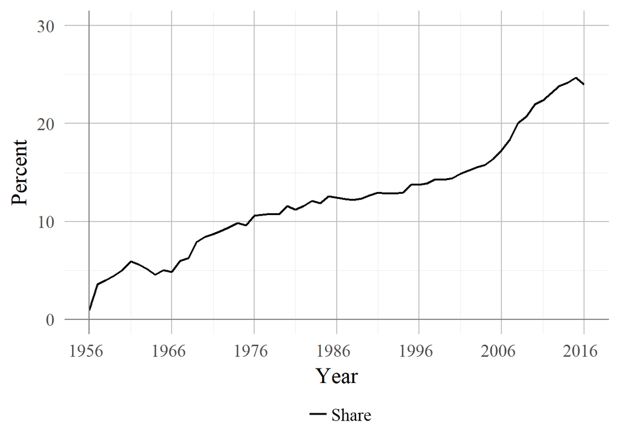

```r
# Calculate Table
citeable <- NLs[["ECON"]][,.N,by=year]
setorder(citeable,year)
citeable <- citeable[,data.table(year,Ncum=cumsum(N))]
cited <- merge(NLs[["ECON"]][,PID,year],ELs[["ECON"]],by.x="PID",by.y="source")[,unique(data.table(year,target))][,.N,by=year]
xt <- merge(cited,citeable,by="year")[,data.table(year,share=N/Ncum*100,var="Share of cited articles")]

# Make Plot
g <-ggplot(xt) + geom_line(aes(y=share,x=year,group=var,color="Share"),size=0.8) +
                scale_x_continuous(breaks=seq(1956, 2016, 10)) +
                ylab("Percent") + xlab("Year") +
                scale_y_continuous(breaks=c(seq(0,30,10)), limits =c(0,30)) +
                geom_hline(yintercept = 0,color="#777777") +
                geom_vline(xintercept = 1956,color="#777777") +
                theme(axis.text.x = element_text(hjust = 0.6)) +
                scale_colour_manual(name="",values="black") #+
                #guides(color=guide_legend(nrow=1,byrow=TRUE))
g$vp = grid::viewport(height=1, width=1)
## Plot
g
```

```r
ggsave(file="export_latex/ovw_citeable_articles.pdf",width=20,height=20,units="cm",dpi = 600, device = "pdf")
ggsave(file="export_tiff/fig3.tiff",width=20,height=20,units="cm",dpi = 600, device = "tiff")
doc <- body_add_break(doc, pos = "after")
doc <- body_add_par(doc, "Figure 3: Share of cumulative articles in the respective year cited at least once, 1956-2016", style = NULL, pos = "after")
doc <- body_add_gg(doc, g , style = "centered",width=4,height=4)
doc <- body_add_par(doc, "", style = NULL, pos = "after")
print(doc, target = "export_word/tables.docx")
```

```
## [1] "C:/Files/Dropbox/1 Projekte/1 Citations/Citation Analysis/Auswertungen/EconConcentration/export_word/tables.docx"
```

```r
datatable(xt)
```

|  | year | share | var |
| --- | --- | --- | --- |
| 1 | 1956 | 0.952380952380952 | Share of cited articles |
| 2 | 1957 | 3.55583281347473 | Share of cited articles |
| 3 | 1958 | 3.97810987160598 | Share of cited articles |
| 4 | 1959 | 4.45869837296621 | Share of cited articles |
| 5 | 1960 | 5.05213505461768 | Share of cited articles |
| 6 | 1961 | 5.93159036891599 | Share of cited articles |
| 7 | 1962 | 5.60690080098583 | Share of cited articles |
| 8 | 1963 | 5.13430544896393 | Share of cited articles |
| 9 | 1964 | 4.54297035114087 | Share of cited articles |
| 10 | 1965 | 5.02308066083576 | Share of cited articles |

[output cut: 51 more lines]

## Figure: Share of citations to the top 1, 5, 10, 50 percent of articles each year, 1956-2016

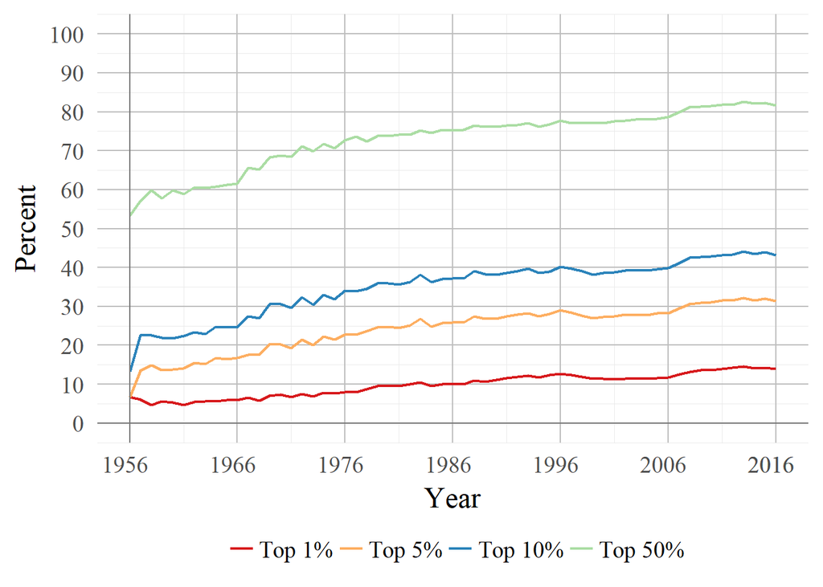

```r
## Calculate Top Percent Shares
xt <- merge(NLs[["ECON"]][,PID,year],ELs[["ECON"]],by.x="PID",by.y="source")[,.N,by=c("year","target")][order(year,-N)][,Nperc:=N/sum(N),by=year][,Ncum:=cumsum(N),by=year][,NcumPerc:=Ncum/sum(N),by=year][,Arank:=1:.N,by=year][,paste0("perc",c(1,5,10,50)):=lapply(c(0.01,0.05,0.1,0.5), function(x) NcumPerc[Arank == ceiling(.N*x)]*100),by=year][,unique(data.table(year,perc1,perc5,perc10,perc50))]

# Plot
xt <- melt(xt,id.var="year",variable.factor=T)

g <-
ggplot(xt,aes(year)) +
    geom_line(aes(y = value,color=variable,group=variable), position = "identity",size=0.8) +
    scale_x_continuous(breaks=c(seq(1956, 2016, 10),2016)) +
    scale_color_manual(name="",
                         labels=c("Top 1%", "Top 5%", "Top 10%", "Top 50%"),
                         values=c("#d7191c", "#fdae61", "#2b83ba","#abdda4")) +
    ylab("Percent") + xlab("Year") +
    scale_y_continuous(breaks=c(seq(0,100,10)), limits =c(0,100)) +
    geom_hline(yintercept = 0,color="#777777") +
    geom_vline(xintercept = 1956,color="#777777") +
    theme(axis.text.x = element_text(hjust = 0.6))
g
```

```r
ggsave(file="export_latex/share_top_perc.pdf",width=20,height=20,units="cm")
ggsave(file="export_tiff/fig4.tiff",width=20,height=20,units="cm",dpi = 600, device = "tiff")
doc <- body_add_break(doc, pos = "after")
doc <- body_add_par(doc, "Figure 4: Share of citations to the top 1, 5, 10, 50 percent of articles each year, 1956-2016", style = NULL, pos = "after")
doc <- body_add_gg(doc, g , style = "centered",width=4,height=4)
doc <- body_add_par(doc, "", style = NULL, pos = "after")
print(doc, target = "export_word/tables.docx")
```

```
## [1] "C:/Files/Dropbox/1 Projekte/1 Citations/Citation Analysis/Auswertungen/EconConcentration/export_word/tables.docx"
```

```r
datatable(xt)
```

|  | year | variable | value |
| --- | --- | --- | --- |
| 1 | 1956 | perc1 | 6.66666666666667 |
| 2 | 1957 | perc1 | 6.01503759398496 |
| 3 | 1958 | perc1 | 4.7008547008547 |
| 4 | 1959 | perc1 | 5.65476190476191 |
| 5 | 1960 | perc1 | 5.33596837944664 |
| 6 | 1961 | perc1 | 4.72103004291846 |
| 7 | 1962 | perc1 | 5.45229244114002 |
| 8 | 1963 | perc1 | 5.55555555555556 |
| 9 | 1964 | perc1 | 5.54899645808737 |
| 10 | 1965 | perc1 | 5.90994371482176 |

[output cut: 234 more lines]

## Figure: Gini coefficients for the distribution of citations among the cited articles in the respective year, 1956-2016

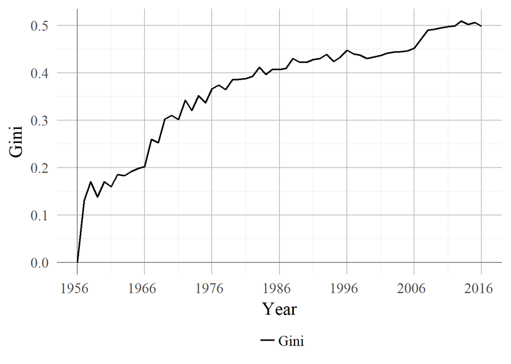

```r
## Calculate Gini Coefficients
art_FT <- merge(ELs[["ECON"]][,source,target],NLs[["ECON"]][,PID,year],by.x="source",by.y="PID")[,data.table(year,target)][,.N,by=c("year","target")]
xt <- art_FT[,data.table(gini=Gini(N),herf=Herfindahl(N)),by=year][order(year)]
xt[,year:=as.numeric(year)]
## Plot
g <- ggplot(xt,aes(x=year)) +
    geom_line(aes(y = gini),size=0.8) +
    # geom_line(aes(y = herf*100,color="Herfindahl")) +
    scale_x_continuous(breaks=seq(1956, 2016, 10)) +
    # scale_y_continuous(breaks=c(seq(0,1,.1)), limits =c(0,1), sec.axis = sec_axis(~./100,name = "Herfindahl Index",breaks=seq(0,.01,.001))) +
    ylab("Gini") + xlab("Year") +
    theme(axis.text.x = element_text(hjust = 0.6)) +
    geom_hline(yintercept = 0,color="#777777") +
    geom_vline(xintercept = 1956,color="#777777") +
    geom_line(aes(y = gini,color="Gini"),size=0.8) +
    scale_colour_manual(name="",values="black") +
    guides(color=guide_legend(nrow=1,byrow=TRUE))
g$vp = grid::viewport(height=1, width=1)
g
```

```r
ggsave(file="export_latex/gini.pdf",width=20,height=20,units="cm")
ggsave(file="export_tiff/fig5.tiff",width=20,height=20,units="cm",dpi = 600, device = "tiff")
doc <- body_add_break(doc, pos = "after")
doc <- body_add_par(doc, "Figure 5: Gini coefficients for the distribution of citations among the cited articles in the respective year, 1956-2016", style = NULL, pos = "after")
doc <- body_add_gg(doc, g , style = "centered",width=4,height=4)
doc <- body_add_par(doc, "", style = NULL, pos = "after")
print(doc, target = "export_word/tables.docx")
```

```
## [1] "C:/Files/Dropbox/1 Projekte/1 Citations/Citation Analysis/Auswertungen/EconConcentration/export_word/tables.docx"
```

```r
datatable(xt)
```

|  | year | gini | herf |
| --- | --- | --- | --- |
| 1 | 1956 | 0 | 0.0666666666666667 |
| 2 | 1957 | 0.130391768895924 | 0.010571541636045 |
| 3 | 1958 | 0.170080947858726 | 0.00693987873475053 |
| 4 | 1959 | 0.138366750208855 | 0.00458829365079365 |
| 5 | 1960 | 0.169902205475328 | 0.00315580621475105 |
| 6 | 1961 | 0.15960331583696 | 0.00228202562008674 |
| 7 | 1962 | 0.185262781120455 | 0.00214817988204205 |
| 8 | 1963 | 0.183220430620488 | 0.0020846257454074 |
| 9 | 1964 | 0.191810103771826 | 0.0021507954318945 |
| 10 | 1965 | 0.198019015814751 | 0.0017670518745886 |

[output cut: 51 more lines]

# Journal concentration

## Code Articles

```r
# Journals
## Big5j
joubig5 <- fread("../../Daten/selection_lists/jbig5.csv",quote="\"",header=F)[,V1]
NLs[["ECON"]][,jbig5:=ifelse(journal %chin% joubig5,"jbig5","jbig5oth")]
NLs[["ECON"]][,journalbig5:=ifelse(journal %chin% joubig5,journal,"journalbig5oth")]
## Big5jcit
joubig5cit <- names(tail(merge(el,NLs[["ECON"]][,PID,journal],by.x="target",by.y="PID")[,sort(table(journal))],5))
NLs[["ECON"]][,jbig5cit:=ifelse(journal %chin% joubig5cit,"jbig5cit","jbig5citoth")]
NLs[["ECON"]][,journalbig5cit:=ifelse(journal %chin% joubig5cit,journal,"journalbig5citoth")]
## Big5citjou_h
joubig5cith <- names(tail(merge(el,NLs[["ECON"]][henho=="het",PID,journal],by.x="target",by.y="PID")[,sort(table(journal))],5))
NLs[["ECON"]][,jbig5cith:=ifelse(journal %chin% joubig5cith,"jbig5cith","jbig5cithoth")]
NLs[["ECON"]][,journalbig5cith:=ifelse(journal %chin% joubig5cith,journal,"journalbig5cithoth")]
```

## Table: The ‘Top Five’ journals in economics, 1956-2016

```r
# Table: Calculate data
xt <- list(
    NLs[["ECON"]][,data.table(art=.N),by=journal][,art_share:=art/sum(art)*100][journal %chin% joubig5],
    merge(ELs[["ECON"]],NLs[["ECON"]][,data.table(PID,journal)],by.x="target",by.y="PID")[,data.table(cit=.N),by=journal][,cit_share:=cit/sum(cit)*100][journal %chin% joubig5],
    merge(ELs[["ECON"]],NLs[["ECON"]][,data.table(PID,journal)],by.x="target",by.y="PID")[,.N,by=c("journal","target")][order(-N)][1:100,top100:=.N/100*100,by=journal][1:500,top500:=.N/500*100,by=journal][1:1000,top1000:=.N/1000*100,by=journal][journal %chin% joubig5 & !is.na(top100),unique(data.table(journal,top100,top500,top1000))]
)
xt <- Reduce(merge,xt)
## Add total column
xt <- rbind(xt,data.table(journal="total",xt[,lapply(.SD,sum),.SDcols=names(xt)[-1]]))
## Calculate mean cit per art
xt[,cit_per_art:=cit/art]

# Name and sort table
xt[,journal:=c("AER","Ectra","JPE","QJE","REStud","Total")]
xt <- xt[,c(1,2,4,9,3,5,6,7,8)]
setnames(xt,c("","Articles","Citations","Citations per article","Share of articles","Share of citations",
               "Share of top 100 articles","Share of top 500 articles","Share of top 1000 articles"))

# Latex Table
dig <- c(0,0,0,2,2,2,0,2,2)
cap <- "The 'Top Five' journals in economics, 1956-2016"
lab <- c("table:journal")
bold <- function(x) {paste('{\\textbf{',x,'}}', sep ='')}
alg <- c(" l","  R{1cm}","  R{1.18cm}","  R{1.2cm}","  R{1.25cm}","  R{1.28cm}"," R{1.25cm}"," R{1.25cm}"," R{1.33cm}")
## Export Table
xt <- xtable(xt,caption=cap,align=c("r",alg),label=lab,digits=c(0,dig))
print(xt,type="latex",hline.after=c(-1,-1,0,5,6,6),table.placement="!htbp",
        file="export_latex/journal.tex",size="\\scriptsize",#sanitize.colnames.function = bold,
        include.rownames=F, align=alg,format.args=list(big.mark = ","))

# Word Export
doc <- body_add_break(doc, pos = "after")
doc <- body_add_par(doc, paste0("Table 2: ", cap), style = NULL, pos = "after")
doc <- body_add_par(doc, "", style = NULL, pos = "after")
doc <- body_add_flextable(doc, value = xtable_to_flextable(xt), pos = "after")
doc <- body_add_par(doc, "", style = NULL, pos = "after")
doc <- body_add_par(doc, "Notes. Top 100, 500, and 1000 articles refers to the most-cited articles in the data set.", style = NULL, pos = "after")
doc <- body_add_par(doc, "", style = NULL, pos = "after")
doc <- body_add_par(doc, "", style = NULL, pos = "after")


print(doc, target = "export_word/tables.docx")
```

```
## [1] "C:/Files/Dropbox/1 Projekte/1 Citations/Citation Analysis/Auswertungen/EconConcentration/export_word/tables.docx"
```

```r
# Plot table
datatable(xt)
```

|  | Var.2 | Articles | Citations | Citations per article | Share of articles | Share of citations | Share of top 100 articles | Share of top 500 articles | Share of top 1000 articles |
| --- | --- | --- | --- | --- | --- | --- | --- | --- | --- |
| 1 | AER | 9704 | 315230 | 32.4845424567189 | 2.30580967090412 | 9.05825264200233 | 12 | 15.4 | 14.8 |
| 2 | Ectra | 4076 | 240788 | 59.0745829244357 | 0.968516098372342 | 6.91913376633714 | 29 | 19 | 15.9 |
| 3 | JPE | 3530 | 194115 | 54.9900849858357 | 0.838778662231199 | 5.57796755258789 | 18 | 16.4 | 13.7 |
| 4 | QJE | 2889 | 146375 | 50.6663205261336 | 0.686467862658905 | 4.20614069242487 | 8 | 9.2 | 9.6 |
| 5 | REStud | 2636 | 94325 | 35.7833839150228 | 0.62635143162647 | 2.71046436080598 | 4 | 4.6 | 4.2 |
| 6 | Total | 22835 | 990833 | 43.3909787606744 | 5.42592372579304 | 28.4719590141582 | 71 | 64.6 | 58.2 |

```r
# Calculate data
## Citation Share
cit_share <- merge(ELs[["ECON"]][,source,target],NLs[["ECON"]][,PID,year],by.x="source",by.y="PID")[,data.table(year,target)][,.N,by=c("year","target")]
cit_share <- merge(unique(cit_share),NLs[["ECON"]][,PID,jbig5],by.x="target",by.y="PID")[,data.table(year,jbig5,N)][,sum(N),by=c("year","jbig5")][order(year)]
cit_share <- dcast(cit_share,year~jbig5)[,data.table(year,cit_share=jbig5/(jbig5 + jbig5oth))]
```

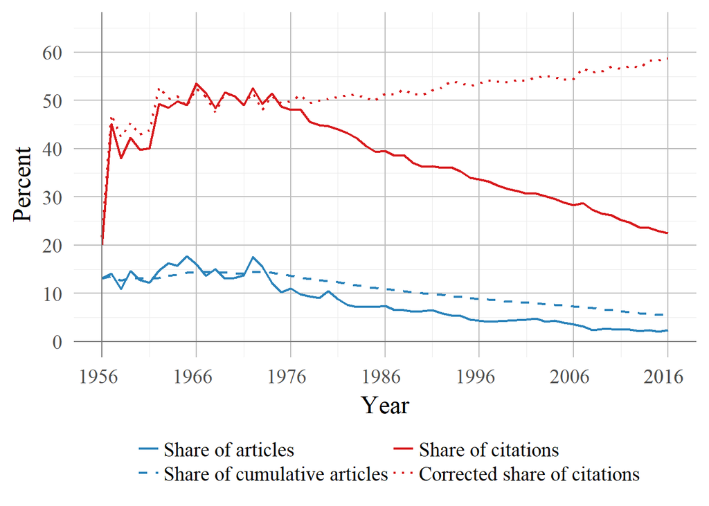

```r
## Publication Share
pub_share <- NLs[["ECON"]][,year,jbig5][,.N,by=c("year","jbig5")][order(year,jbig5)][,data.table(year,pub_cumsum=cumsum(N),pub_sum=N),by=c("jbig5")]
pub_share <- dcast(pub_share,year~jbig5,value.var=c("pub_sum","pub_cumsum"))[,data.table(year, pub_share=pub_sum_jbig5/(pub_sum_jbig5 + pub_sum_jbig5oth),pub_cumsum_share=pub_cumsum_jbig5/(pub_cumsum_jbig5 + pub_cumsum_jbig5oth))]
## Corrected Share
xt <- merge(cit_share,pub_share)[,pub_cumsum_share_norm:=pub_cumsum_share/pub_cumsum_share[year==1970]][,cit_to_pub_share:=cit_share/pub_cumsum_share_norm]

# Plot
xt <- melt(xt[,-"pub_cumsum_share_norm"],id.vars="year",variable.factor=F)
xt[,variable:=factor(variable,levels=c("pub_share","pub_cumsum_share","cit_share","cit_to_pub_share"))]
labs <- c("Share of articles","Share of cumulative articles","Share of citations","Corrected share of citations")
g <-
ggplot(xt,aes(y = value*100,x=year,color=variable,linetype=variable)) + geom_line(size=0.8) +
    scale_colour_manual(name="",values=c("#2b83ba","#2b83ba","#d7191c","#d7191c"),labels=labs) +
    scale_linetype_manual(name="",values=c(1,2,1,3),labels=labs) +
    scale_x_continuous(breaks=c(seq(1956, 2016, 10),2016)) +
    ylab("Percent") + xlab("Year") +
    scale_y_continuous(breaks=c(seq(0,65,10)), limits =c(0,65))+#, sec.axis = sec_axis(~./10,name = "Corrected share of citations",breaks=seq(0,10,1))) +
    geom_hline(yintercept = 0,color="#777777") +
    geom_vline(xintercept = 1956,color="#777777") +
    theme(axis.text.x = element_text(hjust = 0.6)) +
    guides(color=guide_legend(nrow=2,byrow=FALSE),linetype=guide_legend(nrow=2,byrow=FALSE))
g
```

```r
ggsave(file="export_latex/j_citation_to_cum_pub_share_ratio.pdf",width=20,height=20,units="cm")
ggsave(file="export_tiff/fig6.tiff",width=20,height=20,units="cm",dpi = 600, device = "tiff")
doc <- body_add_break(doc, pos = "after")
doc <- body_add_par(doc, "Figure 6: Share of citations and articles of Top Five journals, 1956-2014; corrected share normalised to 1970", style = NULL, pos = "after")
doc <- body_add_gg(doc, g , style = "centered",width=4,height=4)
doc <- body_add_par(doc, "", style = NULL, pos = "after")
print(doc, target = "export_word/tables.docx")
```

```
## [1] "C:/Files/Dropbox/1 Projekte/1 Citations/Citation Analysis/Auswertungen/EconConcentration/export_word/tables.docx"
```

```r
datatable(xt)
```

|  | year | variable | value |
| --- | --- | --- | --- |
| 1 | 1956 | cit_share | 0.2 |
| 2 | 1957 | cit_share | 0.451127819548872 |
| 3 | 1958 | cit_share | 0.38034188034188 |
| 4 | 1959 | cit_share | 0.422619047619048 |
| 5 | 1960 | cit_share | 0.397233201581028 |
| 6 | 1961 | cit_share | 0.400572246065808 |
| 7 | 1962 | cit_share | 0.493184634448575 |
| 8 | 1963 | cit_share | 0.484633569739953 |
| 9 | 1964 | cit_share | 0.498229043683589 |
| 10 | 1965 | cit_share | 0.4906191369606 |

[output cut: 234 more lines]

## Figure: Share of `Top Five` journals in 100, 500, 1000 most-cited articles each year, 5-year weighted moving average, 1956-2016

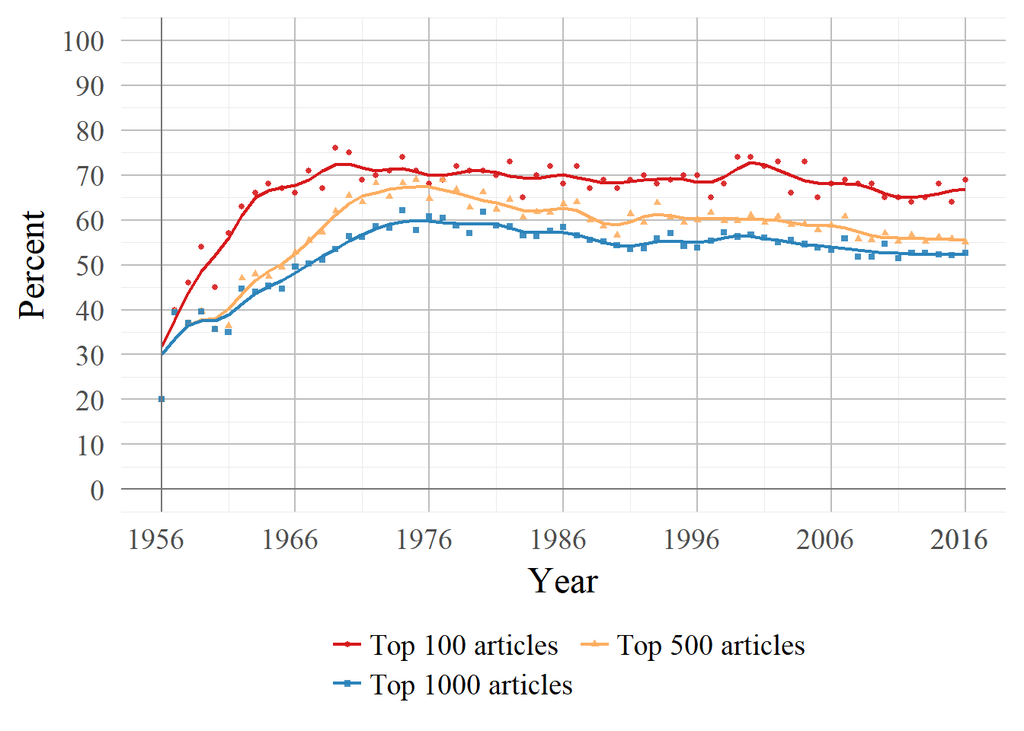

```r
# Calculate Data
xt <- merge(NLs[["ECON"]][,PID,year],ELs[["ECON"]],by.x="PID",by.y="source")[,.N,by=c("year","target")][order(year,-N)]
xt <- merge(xt,NLs[["ECON"]][,PID,jbig5],by.x="target",by.y="PID")[order(year,-N)][,Nrank:=1:.N,by=year][,int:=1][,top100:=sum(int[Nrank <=100 & jbig5 == "jbig5"])/min(sum(int),100)*100,by=year][,top500:=sum(int[Nrank <=500 & jbig5 == "jbig5"])/min(sum(int),500)*100,by=year][,top1000:=sum(int[Nrank <=1000 & jbig5 == "jbig5"])/min(sum(int),1000)*100,by=year][,unique(data.table(year,top100,top500,top1000))]
## Reshape
xt <- melt(xt,id.vars="year")

# Smooth Data
setkey(xt,variable,year)
fun.wm <- function(x) weighted.mean(x,w=c(0.1,0.25,0.3,0.25,0.1),na.rm = T)
xt <- xt[CJ(unique(xt$variable), seq(min(1954), max(2018)))][,
    average:=rollapply(value, 5, fun.wm, fill = NA,align ="center"), by=variable][year <= 2016 & year >=1956]

# Plot
labs <- c("Top 100 articles","Top 500 articles","Top 1000 articles")
g <- ggplot(xt,aes(x=year,color=variable,group=variable))  +
    geom_point(aes(y = value,shape=variable), alpha = 0.9,size=1.1) +
    geom_line(aes(y = average),size=0.8) +
    scale_color_manual(name="",labels=labs,values=c("#d7191c", "#fdae61", "#2b83ba")) +
    scale_shape_discrete(name="",labels=labs) +
    scale_x_continuous(breaks=c(seq(1956, 2016, 10),2016)) +
    scale_y_continuous(breaks=c(seq(0,100,10))) +
    coord_cartesian(ylim=c(0, 100)) +
    geom_hline(yintercept = 0,color="#777777") +
    geom_vline(xintercept = 1956,color="#777777") +
    theme(axis.text.x = element_text(hjust = 0.6))  +
    ylab("Percent") + xlab("Year") +
    guides(color=guide_legend(nrow=2,byrow=TRUE))
g
```

```r
ggsave(file="export_latex/j_share_in_top_abs.pdf",width=20,height=20,units="cm")
ggsave(file="export_tiff/fig7.tiff",width=20,height=20,units="cm",dpi = 600, device = "tiff")
doc <- body_add_break(doc, pos = "after")
doc <- body_add_par(doc, "Figure 7: Share of Top Five journals in 100, 500, 1000 most-cited articles each year, 5-year weighted moving average, 1956-2016", style = NULL, pos = "after")
doc <- body_add_gg(doc, g , style = "centered",width=4,height=4)
doc <- body_add_par(doc, "", style = NULL, pos = "after")
print(doc, target = "export_word/tables.docx")
```

```
## [1] "C:/Files/Dropbox/1 Projekte/1 Citations/Citation Analysis/Auswertungen/EconConcentration/export_word/tables.docx"
```

```r
#values for text
xt[year %in% 1972:1976,mean(value),by=variable]
```

```
##    variable   V1
## 1:   top100 70.8
## 2:   top500 67.1
## 3:  top1000 59.5
```

```r
xt[year %in% 2012:2016,mean(value),by=variable]
```

```
##    variable   V1
## 1:   top100 66.0
## 2:   top500 55.8
## 3:  top1000 52.5
```

```r
datatable(xt)
```

|  | year | variable | value | average |
| --- | --- | --- | --- | --- |
| 1 | 1956 | top100 | 20 | 31.6923076923077 |
| 2 | 1957 | top100 | 40 | 37.6666666666667 |
| 3 | 1958 | top100 | 46 | 43.8 |
| 4 | 1959 | top100 | 54 | 48.65 |
| 5 | 1960 | top100 | 45 | 52.15 |
| 6 | 1961 | top100 | 57 | 56.1 |
| 7 | 1962 | top100 | 63 | 60.95 |
| 8 | 1963 | top100 | 66 | 64.95 |
| 9 | 1964 | top100 | 68 | 66.55 |
| 10 | 1965 | top100 | 67 | 67.3 |

[output cut: 173 more lines]

## Figure: Gini coefficients of citations to cited journals in the respective year, 1956-2016

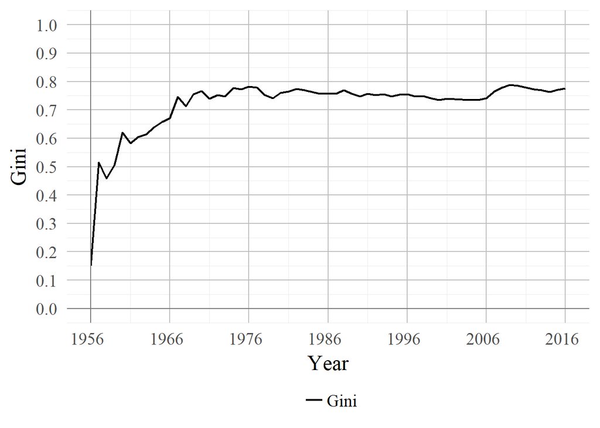

```r
# Calculate Data
art_FT <- merge(ELs[["ECON"]][,source,target],NLs[["ECON"]][,PID,year],by.x="source",by.y="PID")[,data.table(year,target)][,.N,by=c("year","target")]
xt <- merge(art_FT,NLs[["ECON"]][,PID,journal],by.x="target",by.y="PID")[,data.table(year,journal,N)][,sum(N),by=c("year","journal")][,data.table(gini=Gini(V1)),by=year][order(year)][,year:=as.numeric(year)]

# Plot
g <-
ggplot(xt,aes(x=year)) +
    geom_line(aes(y = gini,color="Gini"),size=0.8) +
    # geom_line(aes(y = herf*100,color="Herfindahl")) +
    scale_x_continuous(breaks=seq(1956, 2016, 10)) +
    scale_y_continuous(breaks=c(seq(0,1,.1)), limits =c(0,1))+#, sec.axis = sec_axis(~./100,name = "Herfindahl Index",breaks=seq(0,.01,.001))) +
    # scale_colour_discrete(name="") +
    ylab("Gini") + xlab("Year") +
    theme(axis.text.x = element_text(hjust = 0.6)) +
    scale_colour_manual(name="",values="black") +
    geom_hline(yintercept = 0,color="#777777") +
    geom_vline(xintercept = 1956,color="#777777") +
    guides(color=guide_legend(nrow=1,byrow=TRUE))
g$vp = grid::viewport(height=1, width=1)
g
```

```r
ggsave(file="export_latex/j_gini.pdf",width=20,height=20,units="cm")
ggsave(file="export_tiff/fig8.tiff",width=20,height=20,units="cm",dpi = 600, device = "tiff")
doc <- body_add_break(doc, pos = "after")
doc <- body_add_par(doc, "Figure 8: Gini coefficients of citations to cited journals in the respective year, 1956-2016", style = NULL, pos = "after")
doc <- body_add_gg(doc, g , style = "centered",width=4,height=4)
doc <- body_add_par(doc, "", style = NULL, pos = "after")
print(doc, target = "export_word/tables.docx")
```

```
## [1] "C:/Files/Dropbox/1 Projekte/1 Citations/Citation Analysis/Auswertungen/EconConcentration/export_word/tables.docx"
```

```r
datatable(xt)
```

|  | year | gini |
| --- | --- | --- |
| 1 | 1956 | 0.15 |
| 2 | 1957 | 0.515721120984279 |
| 3 | 1958 | 0.458461538461538 |
| 4 | 1959 | 0.504850088183421 |
| 5 | 1960 | 0.61978834629606 |
| 6 | 1961 | 0.583257467377639 |
| 7 | 1962 | 0.604389015469481 |
| 8 | 1963 | 0.614454576156704 |
| 9 | 1964 | 0.638826108955979 |
| 10 | 1965 | 0.658339093512393 |

[output cut: 51 more lines]

# Region

## Code Articles

```r
reg <- NLs[["ECON_1980"]][,unique(unlist(strsplit(region,split=",")))]
reg <- reg[nchar(reg) > 3 & !is.na(reg) ] # firm names in region/country coding
## Create variable for each region
for (i in reg) NLs[["ECON_1980"]][,paste0("region_",i):=ifelse(grepl(i,region),TRUE,FALSE)] # Seperate
## Create variable for articles without region.
NLs[["ECON_1980"]][,region_NA:=ifelse(is.na(region),TRUE,FALSE)]
regs <- grep("region_",names(NLs[["ECON_1980"]]),value=T)
```

## Table: Eight world regions in economics, 1980-2014

```r
# Calculate Data
xt <- rbind(
    NLs[["ECON_1980"]][,int:=1][,lapply(.SD,function(x) c(sum(int[x == T]),(sum(int[x == T])/sum(int))*100)),.SDcols=regs],
    merge(ELs[["ECON_1980"]],NLs[["ECON_1980"]][,c("PID",regs),with=F],by.x="target",by.y="PID")[,int:=1][,lapply(.SD,function(x) c(sum(int[x == T]),(sum(int[x == T])/sum(int))*100)),.SDcols=regs]
)
xt <- transpose(xt)[,regions:=regs][order(regions)]
## Calculate citations per article
xt[,cit_mean:=V3/V1,by=regions]

# Rename and reoder
## Rename rows
regs_fn <- c("Africa","Asia","Eastern Europe","Latin America","Middle East","Not Assigned","North America","Oceania","Western Europe")
xt[,regions:=regs_fn]
## Rename cols
xt <- xt[,c(5,1,3,6,2,4)]
setnames(xt,c("World Region","Articles","Citations","Citations per article","Share of articles","Share of citations"))
setorder(xt,-`Share of articles`)
xt <- as.data.frame(xt[c(1,2,4,5,6,7,8,9,3),])

region_order <- unlist(xt[,1]) # save order for the graphik later
rownames(xt) <- unlist(xt[,1])

# Make xtable
dig <- c(0,0,0,2,2,2)
alg <- c("l","R{1.7cm}","R{1.7cm}","R{1.7cm}","R{1.7cm}","R{1.7cm}")
cap <- "Eight world regions in economics, 1980-2014"
lab <- c("table:region")
xt <- xtable(xt,caption=cap,align=c("r",alg),label=lab,digits=c(0,dig)) #
print(xt,type="latex",hline.after=c(-1,-1,0,8,9,9),table.placement="!htbp",
        file="export_latex/region.tex",
        size="\\scriptsize",#sanitize.colnames.function = bold,
        include.rownames=F,format.args=list(big.mark = ","))


# Word Export
doc <- body_add_break(doc, pos = "after")
doc <- body_add_par(doc, paste0("Table 3: ", cap), style = NULL, pos = "after")
doc <- body_add_par(doc, "", style = NULL, pos = "after")
doc <- body_add_flextable(doc, value = xtable_to_flextable(xt), pos = "after")
doc <- body_add_par(doc, "", style = NULL, pos = "after")
doc <- body_add_par(doc, "Notes.", style = NULL, pos = "after")
doc <- body_add_par(doc, "a The shares do not sum to 100 percent as co-authored articles are counted once for each region.", style = NULL, pos = "after")
doc <- body_add_par(doc, "b 13.07 percent of articles could not be assigned to a region.", style = NULL, pos = "after")
doc <- body_add_par(doc, "", style = NULL, pos = "after")
print(doc, target = "export_word/tables.docx")
```

```
## [1] "C:/Files/Dropbox/1 Projekte/1 Citations/Citation Analysis/Auswertungen/EconConcentration/export_word/tables.docx"
```

```r
# Plot
datatable(xt)
```

|  | World Region | Articles | Citations | Citations per article | Share of articles | Share of citations |
| --- | --- | --- | --- | --- | --- | --- |
| North America | North America | 150339 | 1780341 | 11.8421766807016 | 47.262444434664 | 72.2922989339334 |
| Western Europe | Western Europe | 91404 | 592854 | 6.4860837600105 | 28.7349022615956 | 24.0733536958247 |
| Asia | Asia | 27065 | 101166 | 3.73789026417883 | 8.50849120071426 | 4.10793365650193 |
| Oceania | Oceania | 15243 | 67728 | 4.44321983861445 | 4.79197972926242 | 2.75015450534333 |
| Eastern Europe | Eastern Europe | 14333 | 22117 | 1.54308239726505 | 4.50590077147007 | 0.898080073155539 |
| Middle East | Middle East | 4981 | 57845 | 11.6131298935957 | 1.56588932831176 | 2.34884667141485 |
| Latin America | Latin America | 4907 | 16368 | 3.33564295903811 | 1.54262576471106 | 0.664636914473476 |
| Africa | Africa | 3256 | 7012 | 2.15356265356265 | 1.02359679843065 | 0.284728375139786 |
| Not Assigned | Not Assigned | 41584 | 146541 | 3.52397556752597 | 13.0728652536672 | 5.95042510287498 |

## Figure: Share of articles by world region each year, 1980-2014

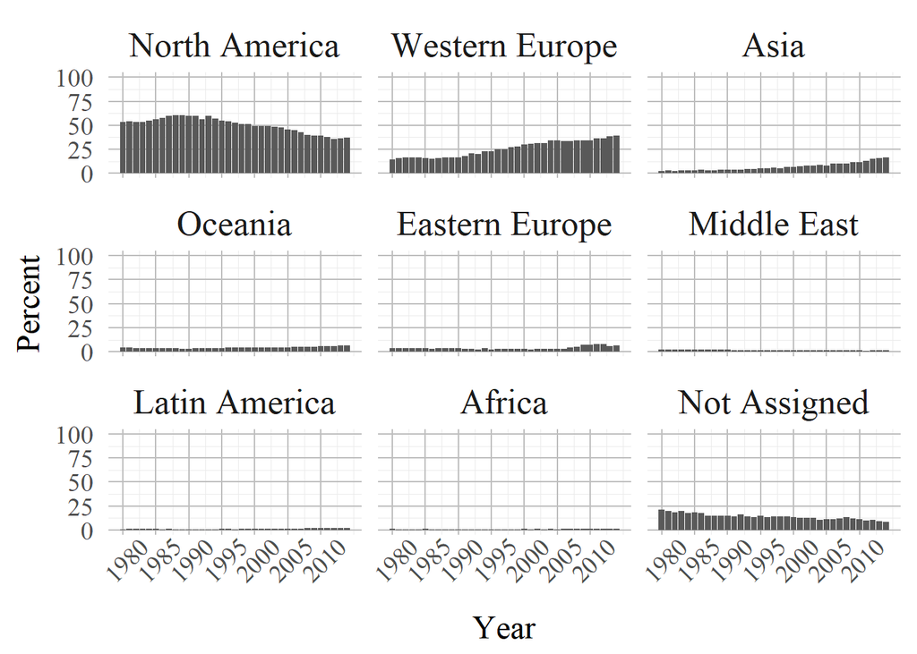

```r
art_share <- NLs[["ECON_1980"]][,int:=1][,lapply(.SD,function(x) (sum(int[x == TRUE])/sum(int))*100),.SDcols=regs,by=year]
art_share <- art_share[,order(names(art_share)),with=F]
setnames(art_share,c(regs_fn,"year"))
art_share <- melt(art_share,id.vars="year",variable.factor=F)
art_share[,variable:=factor(variable,levels=region_order)]

g <-
ggplot(art_share) + geom_bar(aes(y=value,x=year),stat="identity") + facet_wrap(~ variable)  +
        scale_x_continuous(breaks=c(seq(1980, 2014, 5))) +
        theme(axis.text.x = element_text(angle = 45, hjust = 0.6,size=14),
            text = element_text(size=24),axis.text.y = element_text(size=14),
            axis.title = element_text(size=18)) +
        ylim(0,100) + ylab("Percent") + xlab("Year")

g
```

```r
ggsave(file="export_latex/r_share_art.pdf",width=20,height=20,units="cm")
ggsave(file="export_tiff/fig9.tiff",width=20,height=20,units="cm",dpi = 600, device = "tiff")
doc <- body_add_break(doc, pos = "after")
doc <- body_add_par(doc, "Figure 9: Share of articles by world region each year, 1980-2014", style = NULL, pos = "after")
doc <- body_add_gg(doc, g , style = "centered",width=4,height=4)
doc <- body_add_par(doc, "", style = NULL, pos = "after")
print(doc, target = "export_word/tables.docx")
```

```
## [1] "C:/Files/Dropbox/1 Projekte/1 Citations/Citation Analysis/Auswertungen/EconConcentration/export_word/tables.docx"
```

```r
datatable(art_share)
```

|  | year | variable | value |
| --- | --- | --- | --- |
| 1 | 1997 | Africa | 0.729641693811075 |
| 2 | 1998 | Africa | 0.849202264539372 |
| 3 | 1996 | Africa | 0.754226267880364 |
| 4 | 1999 | Africa | 0.669499163126046 |
| 5 | 2000 | Africa | 1.07459702611521 |
| 6 | 2001 | Africa | 0.758140691026597 |
| 7 | 2002 | Africa | 1.08773607458762 |
| 8 | 2003 | Africa | 0.885362768770841 |
| 9 | 2004 | Africa | 1.05764760576476 |
| 10 | 2006 | Africa | 1.38435676851577 |

[output cut: 305 more lines]

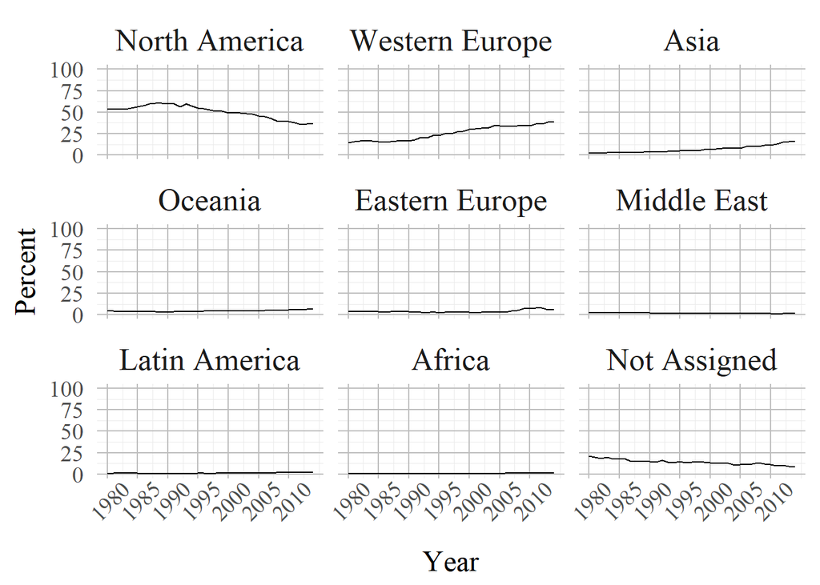

```r
## with lines (for revision letter)
g <-
ggplot(art_share) + geom_line(aes(y=value,x=year),stat="identity") + facet_wrap(~ variable)  +
        scale_x_continuous(breaks=c(seq(1980, 2014, 5))) +
        theme(axis.text.x = element_text(angle = 45, hjust = 0.6,size=14),
            text = element_text(size=24),axis.text.y = element_text(size=14),
            axis.title = element_text(size=18)) +
        ylim(0,100) + ylab("Percent") + xlab("Year")
g
```

```r
ggsave(file="export_latex/r_share_art_lines.pdf",width=20,height=20,units="cm")
ggsave(file="export_latex/r_share_art_lines.png",width=20,height=20,units="cm")
```

## Figure: Share of citations to world region each year, 1980-2014

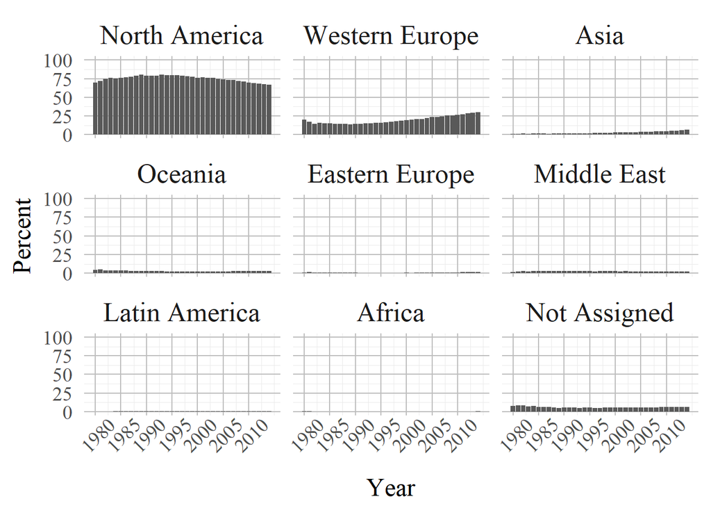

```r
cit_share <- merge(NLs[["ECON_1980"]][,PID,year],ELs[["ECON_1980"]],by.x="PID",by.y="source")
cit_share <- merge(cit_share,NLs[["ECON_1980"]][,c("PID",regs),with=F],by.x="target",by.y="PID")[,int:=1][,lapply(.SD,function(x) (sum(int[x == TRUE])/sum(int))*100),.SDcols=regs,by=year]#[,sample:="cit_share"]
cit_share <- cit_share[,order(names(cit_share)),with=F]
setnames(cit_share,c(regs_fn,"year"))
cit_share <- melt(cit_share,id.vars="year",variable.factor=F)
cit_share[,variable:=factor(variable,levels=region_order)]

g <-
ggplot(cit_share) + geom_bar(aes(y=value,x=year),stat="identity") + facet_wrap(~ variable)  +
        scale_x_continuous(breaks=c(seq(1980, 2014, 5))) +
        theme(axis.text.x = element_text(angle = 45, hjust = 0.6,size=14),
            text = element_text(size=24),axis.text.y = element_text(size=14),
            axis.title = element_text(size=18)) +
        ylim(0,100) + ylab("Percent") + xlab("Year")
g
```

```r
ggsave(file="export_latex/r_share_cit.pdf",width=20,height=20,units="cm")
ggsave(file="export_tiff/fig10.tiff",width=20,height=20,units="cm",dpi = 600, device = "tiff")
doc <- body_add_break(doc, pos = "after")
doc <- body_add_par(doc, "Figure 10: Share of citations to world region each year, 1980-2014", style = NULL, pos = "after")
doc <- body_add_gg(doc, g , style = "centered",width=4,height=4)
doc <- body_add_par(doc, "", style = NULL, pos = "after")
print(doc, target = "export_word/tables.docx")
```

```
## [1] "C:/Files/Dropbox/1 Projekte/1 Citations/Citation Analysis/Auswertungen/EconConcentration/export_word/tables.docx"
```

```r
datatable(cit_share)
```

|  | year | variable | value |
| --- | --- | --- | --- |
| 1 | 2000 | Africa | 0.234708643631102 |
| 2 | 2001 | Africa | 0.192136917736336 |
| 3 | 1999 | Africa | 0.246606803335781 |
| 4 | 2003 | Africa | 0.232286440794447 |
| 5 | 2010 | Africa | 0.302083631882147 |
| 6 | 2004 | Africa | 0.240012387736141 |
| 7 | 2006 | Africa | 0.31611233985728 |
| 8 | 1997 | Africa | 0.173355291670278 |
| 9 | 2012 | Africa | 0.334681691226043 |
| 10 | 2002 | Africa | 0.211602366370125 |

[output cut: 305 more lines]

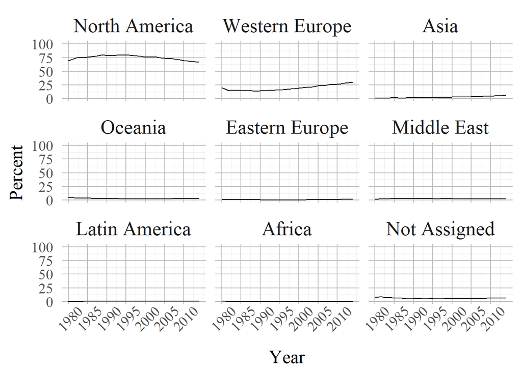

```r
## With lines (for revisions letter)
ggplot(cit_share) + geom_line(aes(y=value,x=year),stat="identity") + facet_wrap(~ variable)  +
        scale_x_continuous(breaks=c(seq(1980, 2014, 5))) +
        theme(axis.text.x = element_text(angle = 45, hjust = 0.6,size=14),
            text = element_text(size=24),axis.text.y = element_text(size=14),
            axis.title = element_text(size=18)) +
        ylim(0,100) + ylab("Percent") + xlab("Year")
```

```r
ggsave(file="export_latex/r_share_cit_lines.pdf",width=20,height=20,units="cm")
ggsave(file="export_latex/r_share_cit_lines.png",width=20,height=20,units="cm")
```

# Institutions

```r
# Code Variables
NLs[["ECON_1980"]][is.na(inst),inst:="instoth"]
sel <- NLs[["ECON_1980"]][,PID]
insbig100cit <- merge(ELs[["ECON_1980"]],NLs[["ECON_1980"]][,PID,inst],by.x="target",by.y="PID",all=F)[,data.table(unlist(lapply(strsplit(inst,split=","),unique)))][,.N,by=V1][order(-N)][1:100,V1]
non_uni <- c("UNIVER_LONDON","CENTRE_ECONOM_POLICY_RESEAR_UK","instoth","ASIA_PACIFI")
insbig100cit <- insbig100cit[!insbig100cit %chin% non_uni]
## Create variables for five most cited institutions
NLs[["ECON_1980"]][,instbig5cit:=ifelse(grepl(paste(insbig100cit[1:5],collapse="|"),inst),TRUE,FALSE)] ## Merged
## Create variables for twenty most cited institutions
NLs[["ECON_1980"]][,instbig20cit:=ifelse(grepl(paste(insbig100cit[1:20],collapse="|"),inst),TRUE,FALSE)] # Merged
for (i in insbig100cit[1:20]) NLs[["ECON_1980"]][,paste0("instbig20cit_",i):=ifelse(grepl(i,inst),TRUE,FALSE)] # Seperate
## List with institute columns
insts <- grep("instb",names(NLs[["ECON_1980"]]),value=T)
```

## Table: The top 20 institutions in economics, 1980-2014

```r
# Calculate Data
xt <- rbind(
    NLs[["ECON_1980"]][,int:=1][,lapply(.SD,function(x) c(sum(int[x == T]),(sum(int[x == T])/sum(int))*100)),.SDcols=insts],
    merge(ELs[["ECON_1980"]][,.N,by=target][order(-N)][,cit_rank:=1:.N][,int:=1],NLs[["ECON_1980"]][,c("PID",insts),with=F],by.x="target",by.y="PID")[,lapply(.SD,function(x) c(sum(N[x == T]),(sum(N[x == T])/sum(N))*100,(sum(int[cit_rank <= 100 & x == T])/sum(int[cit_rank <= 100]))*100,(sum(int[cit_rank <= 500 & x == T])/sum(int[cit_rank <= 500]))*100,(sum(int[cit_rank <= 1000 & x == T])/sum(int[cit_rank <= 1000]))*100)),.SDcols=insts]
)

xt <- transpose(xt)[,institutions:=insts][order(institutions)]
## Calculate citations per article
xt[,cit_mean:=V3/V1,by=institutions]

# Add Rank and Order
## Add Rank
xt[,institutions:=gsub("instbig20cit_","",institutions)]
dt_rank <- data.table(insbig100cit)
dt_rank[,Rank:=1:.N]
xt <- merge(xt,dt_rank,by.x="institutions",by.y="insbig100cit",all.x=T,all.y=F)
## Order and have total in the end
xt[is.na(Rank),Rank:=as.integer(c(23,22))]
setorder(xt,Rank)

# Add full institution name and column names
inst_names <- fread("../../Daten/selection_lists/institutions_manuel.csv",header=T)
inst_names <- rbind(inst_names,data.table(inst_shortname=c("instbig20cit","instbig5cit"),inst_manuelname=c("Top 20","Top 5")),fill=T)
xt <- merge(xt,inst_names[,inst_shortname,inst_manuelname],by.x="institutions",by.y="inst_shortname",all.x=T)
xt <- xt[order(Rank),c(10,11,2,4,9,3,5,6,7,8)]
setnames(xt,c("Rank","Institution","Articles","Citations","Citations per article","Share of articles","Share of citations",
              "Share of top 100 articles","Share of top 500 articles","Share of top 1000 articles"))

# Latex Table
xt <- as.data.frame(xt)
xt[21:22,1] <- c("","")
names(xt)[1] <- ""
## Settings
dig <- c(0,0,0,0,2,2,2,0,2,2)
alg <- c("R{0.1cm}"," l","  R{1cm}","  R{1.17cm}","  R{1.5cm}","  R{0.9cm}"," R{0.9cm}"," R{1.1cm}"," R{1.1cm}"," R{1.25cm}")
cap <- "The top 20 institutions in economics, 1980-2014"
lab <- c("table:top_inst")
## Save
xt <- xtable(xt,caption=cap,align=c("r",alg),label=lab,digits=c(0,dig)) #
print(xt,type="latex",hline.after=c(-1,-1,0,20,22,22),table.placement="!htbp",
         file="export_latex/i_institutions.tex",size="\\scriptsize",
         include.rownames=F,#sanitize.colnames.function = bold,
         format.args=list(big.mark = ","))

# Word Export
doc <- body_add_break(doc, pos = "after")
doc <- body_add_par(doc, paste0("Table 4: ", cap), style = NULL, pos = "after")
doc <- body_add_par(doc, "", style = NULL, pos = "after")
doc <- body_add_flextable(doc, value = xtable_to_flextable(xt), pos = "after")
doc <- body_add_par(doc, "", style = NULL, pos = "after")
doc <- body_add_par(doc, "Notes. Citations per article specifies the mean number of citations an article receives. Top 100, 500, and 1000 articles refers to the most-cited articles in the data set.", style = NULL, pos = "after")
doc <- body_add_par(doc, "", style = NULL, pos = "after")
print(doc, target = "export_word/tables.docx")
```

```
## [1] "C:/Files/Dropbox/1 Projekte/1 Citations/Citation Analysis/Auswertungen/EconConcentration/export_word/tables.docx"
```

```r
# Plot
datatable(xt)
```

|  | Var.2 | Institution | Articles | Citations | Citations per article | Share of articles | Share of citations | Share of top 100 articles | Share of top 500 articles | Share of top 1000 articles |
| --- | --- | --- | --- | --- | --- | --- | --- | --- | --- | --- |
| 1 | 1 | Harvard | 5410 | 151669 | 28.0349353049908 | 1.70075512269958 | 6.15865201498519 | 13 | 13.4 | 12.9 |
| 2 | 2 | Chicago | 3265 | 119975 | 36.7457886676876 | 1.02642615076047 | 4.87168950476266 | 17 | 13.4 | 11.5 |
| 3 | 3 | MIT | 3232 | 105099 | 32.518254950495 | 1.01605185888448 | 4.26763655145698 | 11 | 8.8 | 8.4 |
| 4 | 4 | Princeton | 2352 | 84992 | 36.1360544217687 | 0.739404075524845 | 3.45117428121516 | 9 | 7.6 | 8.2 |
| 5 | 5 | Stanford | 3453 | 81410 | 23.5766000579206 | 1.08552817720548 | 3.30572404736594 | 6 | 6.8 | 6.3 |
| 6 | 6 | Penn State University | 3417 | 78414 | 22.9482001755926 | 1.07421076788622 | 3.1840688545652 | 3 | 4 | 4.6 |
| 7 | 7 | UC Berkeley | 3952 | 75907 | 19.2072368421053 | 1.24240004526964 | 3.08226993321958 | 5 | 5.6 | 4.7 |
| 8 | 8 | Northwestern | 2814 | 69172 | 24.5813788201848 | 0.884644161788654 | 2.80878938465049 | 5 | 6.2 | 5.1 |
| 9 | 9 | Yale | 2618 | 63140 | 24.1176470588235 | 0.823027155494917 | 2.56385476416516 | 11 | 7.2 | 5.4 |
| 10 | 10 | LSE | 3727 | 62003 | 16.6361685001342 | 1.17166623702428 | 2.51768588759158 | 6 | 3.2 | 3.9 |

[output cut: 12 more lines]

## Figure: Share of articles and citations of top 20 institutions, 1980-2014; corrected share normalised to 1995

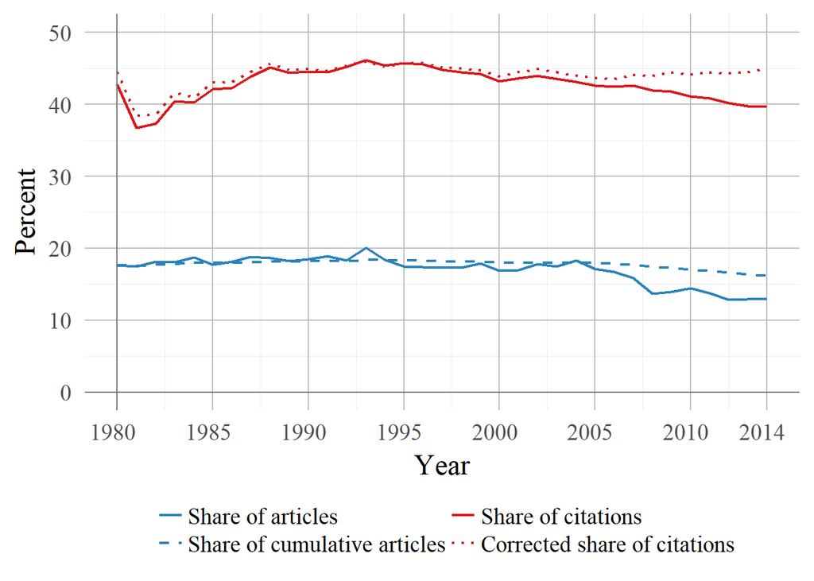

```r
# Calculate Data
## Citation Share
cit_share <- merge(NLs[["ECON_1980"]][,PID,year],ELs[["ECON_1980"]],by.x="PID",by.y="source")
cit_share <- merge(cit_share,NLs[["ECON_1980"]][,c("PID","instbig20cit"),with=F],by.x="target",by.y="PID")[,int:=1][,lapply(.SD,function(x) (sum(int[x == TRUE])/sum(int))*100),.SDcols="instbig20cit",by=year][,data.table(year,cit_share=instbig20cit)]
## Article Share
art_share <- NLs[["ECON_1980"]][,int:=1][,lapply(.SD,function(x) (sum(int[x == TRUE])/sum(int))*100),.SDcols="instbig20cit",by=year][order(year)][,data.table(year,art_share=instbig20cit)]
## Cumulative Aritlce Share
cum_share <- NLs[["ECON_1980"]][,.N,by=c("year","instbig20cit")][order(year)][,Nyear_cum:=cumsum(N),by=c("instbig20cit")][,cum_share:=Nyear_cum/sum(Nyear_cum)*100,by=year][instbig20cit == TRUE][,cum_share_norm:=cum_share/cum_share[year == 1995]][instbig20cit == TRUE][,data.table(year,cum_share,cum_share_norm)]
## Merge
xt <- Reduce(merge,list(cit_share,art_share,cum_share))
xt[,cit_share_corr:=cit_share/cum_share_norm]

# Plot
xt <- melt(xt[,-"cum_share_norm"],id.vars="year",variable.factor=F)
xt[,variable:=factor(variable,levels=c("art_share","cum_share","cit_share","cit_share_corr"))]
labs <- c("Share of articles","Share of cumulative articles","Share of citations","Corrected share of citations")
g <-
ggplot(xt,aes(y = value,x=year,color=variable,linetype=variable)) + geom_line(size=0.8) +
    scale_colour_manual(name="",values=c("#2b83ba","#2b83ba","#d7191c","#d7191c"),labels=labs) +
    scale_linetype_manual(name="",values=c(1,2,1,3),labels=labs) +
    scale_x_continuous(breaks=c(seq(1980, 2014, 5),2014)) +
    ylab("Percent") + xlab("Year") +
    scale_y_continuous(breaks=c(seq(0,50,10)), limits =c(0,50))+#, sec.axis = sec_axis(~./10,name = "Corrected share of citations",breaks=seq(0,5,1))) +
    geom_hline(yintercept = 0,color="#777777") +
    geom_vline(xintercept = 1980,color="#777777") +
    theme(axis.text.x = element_text(hjust = 0.6)) +
    guides(color=guide_legend(nrow=2,byrow=FALSE),linetype=guide_legend(nrow=2,byrow=FALSE))
g
```

```r
ggsave(file="export_latex/i_citation_to_cum_pub_share_ratio.pdf",width=20,height=20,units="cm")
ggsave(file="export_tiff/fig11.tiff",width=20,height=20,units="cm",dpi = 600, device = "tiff")
doc <- body_add_break(doc, pos = "after")
doc <- body_add_par(doc, "Figure 11: Share of articles and citations of top 20 institutions, 1980-2014; corrected share normalised to 1995", style = NULL, pos = "after")
doc <- body_add_gg(doc, g , style = "centered",width=4,height=4)
doc <- body_add_par(doc, "", style = NULL, pos = "after")
print(doc, target = "export_word/tables.docx")
```

```
## [1] "C:/Files/Dropbox/1 Projekte/1 Citations/Citation Analysis/Auswertungen/EconConcentration/export_word/tables.docx"
```

```r
datatable(xt)
```

|  | year | variable | value |
| --- | --- | --- | --- |
| 1 | 1980 | cit_share | 42.816091954023 |
| 2 | 1981 | cit_share | 36.7496339677892 |
| 3 | 1982 | cit_share | 37.3497508062152 |
| 4 | 1983 | cit_share | 40.4234527687296 |
| 5 | 1984 | cit_share | 40.2290358330255 |
| 6 | 1985 | cit_share | 42.1347331583552 |
| 7 | 1986 | cit_share | 42.2805846131019 |
| 8 | 1987 | cit_share | 43.8833480621134 |
| 9 | 1988 | cit_share | 45.1394759087067 |
| 10 | 1989 | cit_share | 44.3937111655056 |

[output cut: 130 more lines]

## Figure: Share of top 20 institutions in the 100, 500, 1000 most-cited articles each year, 5-year weighted moving average, 1980-2014

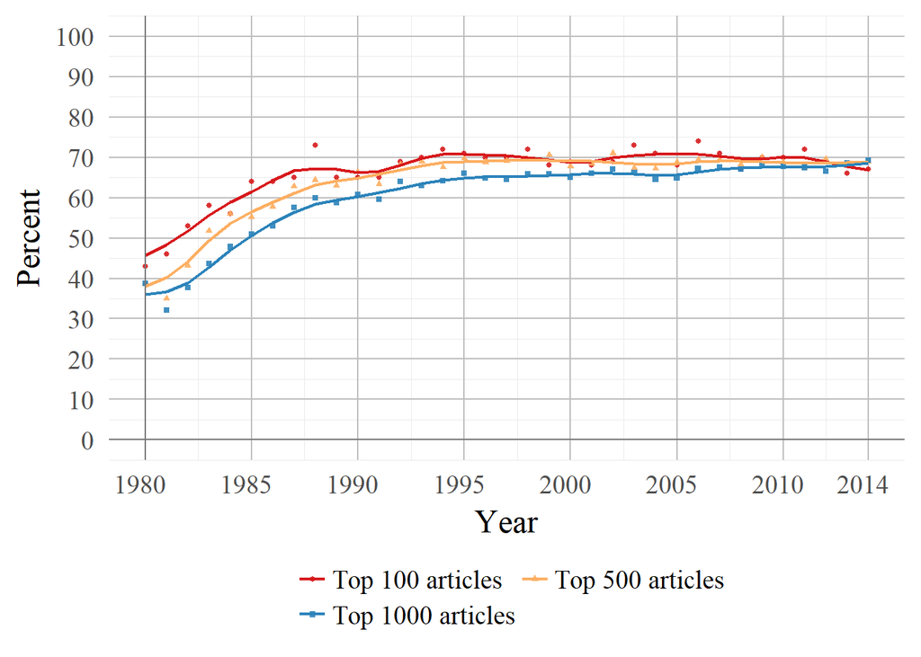

```r
# Calculate Data
xt <- merge(NLs[["ECON_1980"]][,PID,year],ELs[["ECON_1980"]],by.x="PID",by.y="source")[,.N,by=c("year","target")][order(year,-N)]
xt <- merge(xt,NLs[["ECON_1980"]][,PID,instbig20cit],by.x="target",by.y="PID")[order(year,-N)][,Nrank:=1:.N,by=year][,int:=1][,top100:=sum(int[Nrank <=100 & instbig20cit == TRUE])/min(sum(int),100)*100,by=year][,top500:=sum(int[Nrank <=500 & instbig20cit == TRUE])/min(sum(int),500)*100,by=year][,top1000:=sum(int[Nrank <=1000 & instbig20cit == TRUE])/min(sum(int),1000)*100,by=year][,unique(data.table(year,top100,top500,top1000))]
## Reshape
xt <- melt(xt,id.vars="year")

# Smooth Data
setkey(xt,variable,year)
fun.wm <- function(x) weighted.mean(x,w=c(0.1,0.25,0.3,0.25,0.1),na.rm = T)
xt <- xt[CJ(unique(xt$variable), seq(min(1978), max(2016)))][,
    average:=rollapply(value, 5, fun.wm, fill = NA,align ="center"), by=variable][year <= 2014 & year >=1980]

# Plot
labs <- c("Top 100 articles","Top 500 articles","Top 1000 articles")
ggplot(xt,aes(x=year,color=variable,group=variable))  +
    geom_point(aes(y = value,shape=variable), alpha = 0.9,size=1.1) +
    geom_line(aes(y = average),size=0.8) +
    scale_color_manual(name="",labels=labs,values=c("#d7191c", "#fdae61", "#2b83ba")) +
    scale_shape_discrete(name="",labels=labs) +
    scale_x_continuous(breaks=c(seq(1980, 2014, 5),2014)) +
    scale_y_continuous(breaks=c(seq(0,100,10))) +
    coord_cartesian(ylim=c(0, 100)) +
    geom_hline(yintercept = 0,color="#777777") +
    geom_vline(xintercept = 1980,color="#777777") +
    theme(axis.text.x = element_text(hjust = 0.6))  +
    ylab("Percent") + xlab("Year") +
    guides(color=guide_legend(nrow=2,byrow=TRUE))
```

```r
ggsave(file="export_latex/i_share_in_top_abs.pdf",width=20,height=20,units="cm")
ggsave(file="export_tiff/fig12.tiff",width=20,height=20,units="cm",dpi = 600, device = "tiff")
doc <- body_add_break(doc, pos = "after")
doc <- body_add_par(doc, "Figure 12: Share of top 20 institutions in the 100, 500, 1000 most-cited articles each year, 5-year weighted moving average, 1980-2014", style = NULL, pos = "after")
doc <- body_add_gg(doc, g , style = "centered",width=4,height=4)
doc <- body_add_par(doc, "", style = NULL, pos = "after")
print(doc, target = "export_word/tables.docx")
```

```
## [1] "C:/Files/Dropbox/1 Projekte/1 Citations/Citation Analysis/Auswertungen/EconConcentration/export_word/tables.docx"
```

```r
datatable(xt)
```

|  | year | variable | value | average |
| --- | --- | --- | --- | --- |
| 1 | 1980 | top100 | 43 | 45.6923076923077 |
| 2 | 1981 | top100 | 46 | 48.4444444444444 |
| 3 | 1982 | top100 | 53 | 51.8 |
| 4 | 1983 | top100 | 58 | 55.65 |
| 5 | 1984 | top100 | 56 | 59 |
| 6 | 1985 | top100 | 64 | 61.5 |
| 7 | 1986 | top100 | 64 | 64.35 |
| 8 | 1987 | top100 | 65 | 66.65 |
| 9 | 1988 | top100 | 73 | 67.3 |
| 10 | 1989 | top100 | 65 | 67 |

[output cut: 95 more lines]

# Author

## Code Variables

```r
# Top Authors
## Update TCm
NLs[["ECON"]][,TCm:=NULL]
NLs[["ECON"]] <- merge(NLs[["ECON"]],ELs[["ECON"]][,.N,by=target][,data.table(PID=target,TCm=N)],by="PID",all=T)
NLs[["ECON"]][is.na(TCm),TCm:=0]

## Identify Top Authors
top_au <- NLs[["ECON"]][order(TCm,decreasing=T),tstrsplit(author,split=",")]
top_au[,TCm:=NLs[["ECON"]][order(TCm,decreasing=T),TCm]]
top_au <- melt(top_au,id.vars="TCm",na.rm=T)
setnames(top_au,3,"author")
top_au[,TCm:=sum(TCm),by=author]
top_au[,Nart:=.N,by=author]

top_au <- top_au[order(-TCm),unique(data.table(author,TCm,Nart,MeanCit=TCm/Nart))]
## aTop10
aut_top10 <- top_au[Nart > 10 & MeanCit > 10,author][1:10]
NLs[["ECON"]][,atop10:=ifelse(grepl(paste(aut_top10,collapse="|"),author),TRUE,FALSE)]
## aTop100
aut_top100 <- top_au[Nart > 10 & MeanCit > 10,author][1:100]
NLs[["ECON"]][,atop100:=ifelse(grepl(paste(aut_top100,collapse="|"),author),TRUE,FALSE)]

auts <-c("atop10","atop100")
write.csv(top_au[!is.na(TCm),data.table(author,TCm,Nartm=Nart,MeanCitm=MeanCit,Rankm=1:.N)],"../../Daten/selection_lists/auth_recode_m.csv",row.names=F)
```

## Table: Overview on the top 10 and 100 authors, 1956-2016

```r
# Calculate Data
xt <- rbind(
    NLs[["ECON"]][,int:=1][,lapply(.SD,function(x) c(sum(int[x == T]),(sum(int[x == T])/sum(int))*100)),.SDcols=auts],
    merge(ELs[["ECON"]][,.N,by=target][order(-N)][,cit_rank:=1:.N][,int:=1],NLs[["ECON"]][,c("PID",auts),with=F],by.x="target",by.y="PID")[,lapply(.SD,function(x) c(sum(N[x == T]),(sum(N[x == T])/sum(N))*100,(sum(int[cit_rank <= 100 & x == T])/sum(int[cit_rank <= 100]))*100,(sum(int[cit_rank <= 500 & x == T])/sum(int[cit_rank <= 500]))*100,(sum(int[cit_rank <= 1000 & x == T])/sum(int[cit_rank <= 1000]))*100)),.SDcols=auts]
)
## Calculate citations per article
xt <- rbind(xt,xt[3]/xt[1])

# Rename and reorder table
xt <- xt[c(1,3,8,2,4,5,6,7)]
xt[,variable:= c("Articles","Citations","Citations per article","Share of articles","Share of citations",
               "Share of top 100 articles","Share of top 500 articles","Share of top 1000 articles")]
xt <- xt[,c(3,1,2)]
setnames(xt,c("","Top 10 authors","Top 100 authors"))

# Latex Table
## Settings
alg <- c("l","r","r")
cap <- "Overview on the top 10 and 100 authors, 1956-2016"
lab <- c("table:authors")
dig <- matrix(c(rep(0,8),rep(c(0,0,2,2,2,0,2,2),2)),ncol=3,)
xt <- xtable(xt,caption=cap,align=c("r",alg),label=lab,digits=cbind(matrix(rep(0,8),ncol=1),dig)) #
print(xt,type="latex",hline.after=c(-1,-1,0,8,8),table.placement="!htbp",size="\\scriptsize",
        file="export_latex/authors.tex",#sanitize.colnames.function = bold,
        include.rownames=F,format.args=list(big.mark = ","))

# Word Export
doc <- body_add_break(doc, pos = "after")
doc <- body_add_par(doc, paste0("Table 5: ", cap), style = NULL, pos = "after")
doc <- body_add_par(doc, "", style = NULL, pos = "after")
doc <- body_add_flextable(doc, value = xtable_to_flextable(xt), pos = "after")
doc <- body_add_par(doc, "", style = NULL, pos = "after")
doc <- body_add_par(doc, "Notes. A full list of the 100 top authors can be found in table 8 in the appendix.", style = NULL, pos = "after")
doc <- body_add_par(doc, "", style = NULL, pos = "after")
print(doc, target = "export_word/tables.docx")
```

```
## [1] "C:/Files/Dropbox/1 Projekte/1 Citations/Citation Analysis/Auswertungen/EconConcentration/export_word/tables.docx"
```

```r
# Plot
datatable(xt)
```

|  | Var.2 | Top 10 authors | Top 100 authors |
| --- | --- | --- | --- |
| 1 | Articles | 1057 | 7695 |
| 2 | Citations | 119648 | 540064 |
| 3 | Citations per article | 113.195837275307 | 70.1837556855101 |
| 4 | Share of articles | 0.251158369965546 | 1.82844243792325 |
| 5 | Share of citations | 3.43813029251751 | 15.5189422163193 |
| 6 | Share of top 100 articles | 17 | 69 |
| 7 | Share of top 500 articles | 13 | 52.6 |
| 8 | Share of top 1000 articles | 10.7 | 44.2 |

# Paradigmatic concentration

## Code Variables

```r
NLs[["ECON_2016"]][,het:=ifelse(henho=="het",TRUE,FALSE)]
NLs[["ECON_2016"]][,ort:=ifelse(henho=="ort",TRUE,FALSE)]
NLs[["ECON_2016"]][,tot:=TRUE]

parad <- c("ort","het","tot")
```

## Table: Overview on paradigms in economics, 1956-2016

```r
# Calculate Data
xt <- rbind(
    NLs[["ECON_2016"]][,int:=1][,lapply(.SD,function(x) c(sum(int[x == T]),(sum(int[x == T])/sum(int))*100)),.SDcols=parad],
    merge(ELs[["ECON_2016"]][,.N,by=target][order(-N)][,cit_rank:=1:.N][,int:=1],NLs[["ECON_2016"]][,c("PID",parad),with=F],by.x="target",by.y="PID")[,lapply(.SD,function(x) c(sum(N[x == T]),(sum(N[x == T])/sum(N))*100,(sum(int[cit_rank <= 100 & x == T])/sum(int[cit_rank <= 100]))*100,(sum(int[cit_rank <= 500 & x == T])/sum(int[cit_rank <= 500]))*100,(sum(int[cit_rank <= 1000 & x == T])/sum(int[cit_rank <= 1000]))*100,(sum(int[cit_rank <= 5000 & x == T])/sum(int[cit_rank <= 5000]))*100,(sum(int[cit_rank <= 10000 & x == T])/sum(int[cit_rank <= 10000]))*100)),.SDcols=parad]
)
## Calculate citations per article
xt <- rbind(xt,xt[3]/xt[1],NLs[["ECON_2016"]][,data.table(ort=length(unique(journal[ort == TRUE])),het=length(unique(journal[het == TRUE])),tot=length(unique(journal[tot == TRUE])))])

# Rename and reorder table
xt <- xt[c(11,1,3,10,2,4,5,6,7,8,9)]
xt[,variable:= c("Journal","Articles","Citations","Citations per article","Share of articles","Share of citations",
               "Share of top 100 articles","Share of top 500 articles","Share of top 1000 articles","Share of top 5000 articles","Share of top 10000 articles")]
xt <- xt[,c(4,1,2,3)]
setnames(xt,c("","Mainstream","Heterodox","Total"))

# Latex Table
## Settings
dig <- matrix(c(rep(0,11),rep(c(0,0,0,2,2,2,0,0,0,2,2),2),rep(c(0,0,0,2,0,0,0,0,0,0,0),1)),ncol=4,)
alg <- c("l","r","r","r")
cap <- "Overview on paradigms in economics, 1956-2016"
lab <- c("table:school")
xt <- xtable(xt,caption=cap,align=c("r",alg),label=lab,digits=cbind(matrix(rep(0,11),ncol=1),dig)) #
## Print
print(xt,type="latex",hline.after=c(-1,-1,0,11,11),table.placement="!htbp",
         size="\\scriptsize",file="export_latex/school_attr.tex",#sanitize.colnames.function = bold,
         include.rownames=F,format.args=list(big.mark = ","))

# Word Export
doc <- body_add_break(doc, pos = "after")
doc <- body_add_par(doc, paste0("Table 6: ", cap), style = NULL, pos = "after")
doc <- body_add_par(doc, "", style = NULL, pos = "after")
doc <- body_add_flextable(doc, value = xtable_to_flextable(xt), pos = "after")
doc <- body_add_par(doc, "", style = NULL, pos = "after")
doc <- body_add_par(doc, "Notes.", style = NULL, pos = "after")
doc <- body_add_par(doc, "a Refers to all journals that are in the Web of Science subject category economics but are not listed in the Heterodox Economics Directory.", style = NULL, pos = "after")
doc <- body_add_par(doc, "b Refers to all journals that are in the Web of Science subject category economics and are listed in the Heterodox Economics Directory.", style = NULL, pos = "after")
print(doc, target = "export_word/tables.docx")
```

```
## [1] "C:/Files/Dropbox/1 Projekte/1 Citations/Citation Analysis/Auswertungen/EconConcentration/export_word/tables.docx"
```

```r
# Plot
datatable(xt)
```

|  | Var.2 | Mainstream | Heterodox | Total |
| --- | --- | --- | --- | --- |
| 1 | Journal | 344 | 40 | 384 |
| 2 | Articles | 352979 | 30982 | 383961 |
| 3 | Citations | 3321121 | 95334 | 3416455 |
| 4 | Citations per article | 9.40883451990062 | 3.07707701245885 | 8.89792192436211 |
| 5 | Share of articles | 91.9309513205768 | 8.06904867942317 | 100 |
| 6 | Share of citations | 97.209563714435 | 2.79043628556501 | 100 |
| 7 | Share of top 100 articles | 100 | 0 | 100 |
| 8 | Share of top 500 articles | 100 | 0 | 100 |
| 9 | Share of top 1000 articles | 100 | 0 | 100 |
| 10 | Share of top 5000 articles | 99.44 | 0.56 | 100 |

[output cut: 1 more lines]

## Figure: Share of heterodox articles and citations, 1956-2016; corrected share normalised to 1970

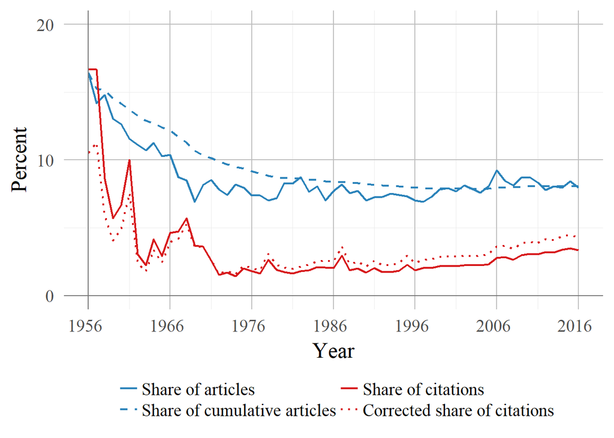

```r
# Calculate Data
## Citation Share
cit_share <- merge(NLs[["ECON_2016"]][,PID,year],ELs[["ECON_2016"]],by.x="PID",by.y="source")
cit_share <- merge(cit_share,NLs[["ECON_2016"]][,c("PID","het"),with=F],by.x="target",by.y="PID")[,int:=1][,lapply(.SD,function(x) (sum(int[x == TRUE])/sum(int))*100),.SDcols="het",by=year][,data.table(year,cit_share=het)]
## Article Share
art_share <- NLs[["ECON_2016"]][,int:=1][,lapply(.SD,function(x) (sum(int[x == TRUE])/sum(int))*100),.SDcols="het",by=year][order(year)][,data.table(year,art_share=het)]
## Cumulative Aritlce Share
cum_share <- NLs[["ECON_2016"]][,.N,by=c("year","het")][order(year)][,Nyear_cum:=cumsum(N),by=c("het")][,cum_share:=Nyear_cum/sum(Nyear_cum)*100,by=year][het == TRUE][,cum_share_norm:=cum_share/cum_share[year == 1970]][het == TRUE][,data.table(year,cum_share,cum_share_norm)]
## Merge
xt <- Reduce(merge,list(cit_share,art_share,cum_share))
xt[,cit_share_corr:=cit_share/cum_share_norm]

# Plot
xt <- melt(xt[,-"cum_share_norm"],id.vars="year",variable.factor=F)
xt[,variable:=factor(variable,levels=c("art_share","cum_share","cit_share","cit_share_corr"))]
labs <- c("Share of articles","Share of cumulative articles","Share of citations","Corrected share of citations")
g <-
ggplot(xt,aes(y = value,x=year,color=variable,linetype=variable)) + geom_line(size=0.8) +
    scale_colour_manual(name="",values=c("#2b83ba","#2b83ba","#d7191c","#d7191c"),labels=labs) +
    scale_linetype_manual(name="",values=c(1,2,1,3),labels=labs) +
    scale_x_continuous(breaks=seq(1956, 2016, 10)) +
    ylab("Percent") + xlab("Year") +
    scale_y_continuous(breaks=c(seq(0,20,10)), limits =c(0,20))+
    geom_hline(yintercept = 0,color="#777777") +
    geom_vline(xintercept = 1956,color="#777777") +
    theme(axis.text.x = element_text(hjust = 0.6)) +
    guides(color=guide_legend(nrow=2,byrow=FALSE),linetype=guide_legend(nrow=2,byrow=FALSE))
g
```

```r
ggsave(file="export_latex/sc_citation_to_cum_pub_share_ratio.pdf",width=20,height=20,units="cm")
ggsave(file="export_tiff/fig13.tiff",width=20,height=20,units="cm",dpi = 600, device = "tiff")
doc <- body_add_break(doc, pos = "after")
doc <- body_add_par(doc, "Figure 13: Share of heterodox articles and citations, 1956-2016; corrected share normalised to 1970", style = NULL, pos = "after")
doc <- body_add_gg(doc, g , style = "centered",width=4,height=4)
doc <- body_add_par(doc, "", style = NULL, pos = "after")
print(doc, target = "export_word/tables.docx")
```

```
## [1] "C:/Files/Dropbox/1 Projekte/1 Citations/Citation Analysis/Auswertungen/EconConcentration/export_word/tables.docx"
```

```r
# Numbers for paper
xt[year %in% c(1956,1972,2016)& variable %in% c("art_share","cit_share")]
```

```
##    year  variable value
## 1: 1956 cit_share 16.67
## 2: 1972 cit_share  1.53
## 3: 2016 cit_share  3.36
## 4: 1956 art_share 16.44
## 5: 1972 art_share  7.84
## 6: 2016 art_share  7.97
```

```r
#
datatable(xt)
```

|  | year | variable | value |
| --- | --- | --- | --- |
| 1 | 1956 | cit_share | 16.6666666666667 |
| 2 | 1957 | cit_share | 16.6666666666667 |
| 3 | 1958 | cit_share | 8.58895705521472 |
| 4 | 1959 | cit_share | 5.70342205323194 |
| 5 | 1960 | cit_share | 6.68693009118541 |
| 6 | 1961 | cit_share | 10 |
| 7 | 1962 | cit_share | 3.05466237942122 |
| 8 | 1963 | cit_share | 2.24550898203593 |
| 9 | 1964 | cit_share | 4.17956656346749 |
| 10 | 1965 | cit_share | 2.90556900726392 |

[output cut: 234 more lines]

## Figure: Share of top 1, 5, 10, 50 percent of articles that were published in heterodox journals, 1956-2016

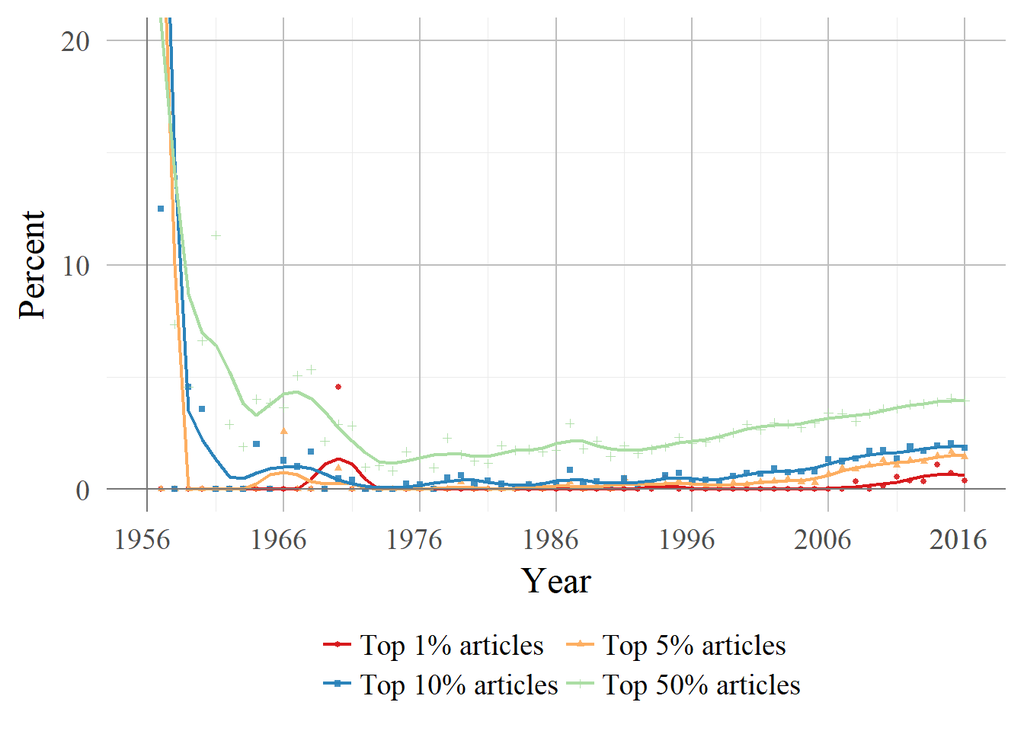

```r
# Calculate Data
xt <- merge(NLs[["ECON_2016"]][,PID,year],ELs[["ECON_2016"]],by.x="PID",by.y="source")[,.N,by=c("year","target")][order(year,-N)]
xt <- merge(xt,NLs[["ECON_2016"]][,PID,het],by.x="target",by.y="PID")[order(year,-N)][,Nrank:=1:.N,by=year][,int:=1][,lapply(c(0.01,0.05,0.1,0.5),function(x) (sum(int[Nrank <= ceiling(max(Nrank)*x) & het == TRUE])/sum(int[Nrank <=ceiling(max(Nrank)*x)]))*100),by=year]
## Reshape
xt <- melt(xt,id.vars="year")

# Smooth Data
setkey(xt,variable,year)
fun.wm <- function(x) weighted.mean(x,w=c(0.1,0.25,0.3,0.25,0.1),na.rm = T)
xt <- xt[CJ(unique(xt$variable), seq(min(1954), max(2018)))][,
    average:=rollapply(value, 5, fun.wm, fill = NA,align ="center"), by=variable][year <= 2016 & year >=1956]

# Plot
labs <- c("Top 1% articles","Top 5% articles","Top 10% articles","Top 50% articles")
g <-
ggplot(xt,aes(x=year,color=variable,group=variable))  +
    geom_point(aes(y = value,shape=variable), alpha = 0.9,size=1.1) +
    geom_line(aes(y = average),size=0.8) +
    scale_color_manual(name="",labels=labs,values=c("#d7191c", "#fdae61", "#2b83ba","#abdda4")) +
    scale_shape_discrete(name="",labels=labs) +
    scale_x_continuous(breaks=c(seq(1956, 2016, 10),2016)) +
    scale_y_continuous(breaks=c(seq(0,100,10))) +
    coord_cartesian(ylim=c(0, 20))  +
    geom_hline(yintercept = 0,color="#777777") +
    geom_vline(xintercept = 1956,color="#777777") +
    theme(axis.text.x = element_text(hjust = 0.6))  +
    ylab("Percent") + xlab("Year") +
    guides(color=guide_legend(nrow=2,byrow=TRUE))
g
```

```r
ggsave(file="export_latex/sc_share_in_top_perc_ma.pdf",width=20,height=20,units="cm")
ggsave(file="export_tiff/fig14.tiff",width=20,height=20,units="cm",dpi = 600, device = "tiff")
doc <- body_add_break(doc, pos = "after")
doc <- body_add_par(doc, "Figure 14: Share of top 1, 5, 10, 50 percent of articles that were published in heterodox journals, 1956-2016", style = NULL, pos = "after")
doc <- body_add_gg(doc, g , style = "centered",width=4,height=4)
doc <- body_add_par(doc, "", style = NULL, pos = "after")
print(doc, target = "export_word/tables.docx")
```

```
## [1] "C:/Files/Dropbox/1 Projekte/1 Citations/Citation Analysis/Auswertungen/EconConcentration/export_word/tables.docx"
```

```r
# Numbers for paper
xt[year %in% c(1956,1975,2016)& variable %in% c("V1","V2","V3","V4")]
```

```
##     year variable   value average
##  1: 1956       V1 100.000  46.154
##  2: 1975       V1   0.000   0.000
##  3: 2016       V1   0.398   0.623
##  4: 1956       V2 100.000  46.154
##  5: 1975       V2   0.000   0.000
##  6: 2016       V2   1.452   1.543
##  7: 1956       V3 100.000  50.962
##  8: 1975       V3   0.254   0.128
##  9: 2016       V3   1.850   1.934
## 10: 1956       V4  33.333  26.911
## 11: 1975       V4   1.679   1.261
## 12: 2016       V4   3.939   3.973
```

```r
#
datatable(xt)
```

|  | year | variable | value | average |
| --- | --- | --- | --- | --- |
| 1 | 1956 | V1 | 100 | 46.1538461538462 |
| 2 | 1957 | V1 | 0 | 27.7777777777778 |
| 3 | 1958 | V1 | 0 | 10 |
| 4 | 1959 | V1 | 0 | 0 |
| 5 | 1960 | V1 | 0 | 0 |
| 6 | 1961 | V1 | 0 | 0 |
| 7 | 1962 | V1 | 0 | 0 |
| 8 | 1963 | V1 | 0 | 0 |
| 9 | 1964 | V1 | 0 | 0 |
| 10 | 1965 | V1 | 0 | 0 |

[output cut: 234 more lines]

# Appendix

## Table: Top 100 Authors, 1956-2016

```r
# Calculate data
## Function to reformat author names
simpleCap <- function(x) {
  s <- strsplit(x, "_")[[1]]
    paste(paste0(toupper(substring(s[1], 1,1)), tolower(substring(s[1], 2))),s[2],
      sep=" ", collapse=" ")
}
xt <- top_au[1:100]
xt[,author:=simpleCap(author),by=author]
# xt[1:10]
setnames(xt,c("Author","Citations","Articles","Citations per article"))

# Excel table
write.xlsx(xt,"export_excel/appendix.xlsx",sheetName="Authors",row.names=F)

# Minor changes
xt[,`R.`:=1:.N]
xt <- xt[,c(5,1,2,3,4)]
xt <- cbind(xt[1:50],xt[51:100])
setnames(xt,c(1,6),c("",""))
xt[41,Author:="La Porta R"]

# Latex table
## Settings
dig <- c(0,0,0,0,0,2,0,0,0,0,2)
alg <- c("C{0.2cm}","L{2.25cm}","R{1.1cm} ","R{0.9cm} ","R{1.4cm} |","C{0.3cm}","L{2.1cm}","R{1.1cm} ","R{0.9cm} ","R{1.4cm} ")
cap <- "Top 100 Authors, 1956-2016"
lab <- c("table:top_auth")
## Print
xt <- xtable(xt,caption=cap,align=c("r",alg),label=lab,digits=dig) #
print(xt,type="latex",hline.after=c(-1,-1,0,50,50),table.placement="!htbp",
        file="export_latex/a_top.tex", size="\\scriptsize",# sanitize.colnames.function = bold,
        include.rownames=F,format.args=list(big.mark = ","))

# Word Export
doc <- body_add_break(doc, pos = "after")
doc <- body_add_par(doc, paste0("Table 8: ", cap), style = NULL, pos = "after")
doc <- body_add_par(doc, "", style = NULL, pos = "after")
names(xt)[6:10] <- paste0(names(xt)[6:10],"-")
doc <- body_add_flextable(doc, value = xtable_to_flextable(xt), pos = "after")
doc <- body_add_par(doc, "", style = NULL, pos = "after")
doc <- body_add_par(doc, "", style = NULL, pos = "after")
print(doc, target = "export_word/tables.docx")
```

```
## [1] "C:/Files/Dropbox/1 Projekte/1 Citations/Citation Analysis/Auswertungen/EconConcentration/export_word/tables.docx"
```

```r
# Plot
datatable(xt)
```

|  | Var.2 | Author | Citations | Articles | Citations per article | - | Author- | Citations- | Articles- | Citations per article- |
| --- | --- | --- | --- | --- | --- | --- | --- | --- | --- | --- |
| 1 | 1 | Shleifer A | 17613 | 132 | 133.431818181818 | 51 | Andrews DWK | 5689 | 81 | 70.2345679012346 |
| 2 | 2 | Stiglitz JE | 16927 | 226 | 74.8982300884956 | 52 | Arellano M | 5529 | 27 | 204.777777777778 |
| 3 | 3 | Heckman JJ | 14171 | 147 | 96.4013605442177 | 53 | Deaton A | 5456 | 71 | 76.8450704225352 |
| 4 | 4 | Engle RF | 13346 | 86 | 155.186046511628 | 54 | Summers LH | 5444 | 91 | 59.8241758241758 |
| 5 | 5 | Barro RJ | 13289 | 101 | 131.574257425743 | 55 | Akerlof GA | 5422 | 54 | 100.407407407407 |
| 6 | 6 | Lucas RE | 12678 | 87 | 145.724137931034 | 56 | West KD | 5414 | 44 | 123.045454545455 |
| 7 | 7 | Becker GS | 11318 | 70 | 161.685714285714 | 57 | Shin YC | 5333 | 53 | 100.622641509434 |
| 8 | 8 | Fama EF | 10987 | 63 | 174.396825396825 | 58 | Feldstein M | 5327 | 171 | 31.1520467836257 |
| 9 | 9 | Tirole J | 9948 | 149 | 66.7651006711409 | 59 | Rosen S | 5305 | 57 | 93.0701754385965 |
| 10 | 10 | Vishny RW | 9665 | 50 | 193.3 | 60 | Diebold FX | 5295 | 69 | 76.7391304347826 |

[output cut: 40 more lines]

## Table: Top 100 Countries, 1980-2014

```r
# Code Variables
cou <- NLs[["ECON_1980"]][,unique(unlist(strsplit(cou,",")))]
for (i in cou) NLs[["ECON_1980"]][,paste0("cou_",i):=ifelse(grepl(paste0("(^|,)",i,"(,|$)"),cou),TRUE,FALSE)] # Seperate
cous <- grep("cou_",names(NLs[["ECON_1980"]]),value=T)

# Calculate Data
xt <- rbind(
    NLs[["ECON_1980"]][,int:=1][,lapply(.SD,function(x) c(sum(int[x == T]))),.SDcols=cous],
    merge(ELs[["ECON_1980"]][,.N,by=target][order(-N)][,cit_rank:=1:.N][,int:=1],NLs[["ECON_1980"]][,c("PID",cous),with=F],by.x="target",by.y="PID")[,lapply(.SD,function(x) c(sum(N[x == T]))),.SDcols=cous]
)
xt <- transpose(xt)[,country:=cous][order(country)]
## Calculate citations per article
xt[,cit_mean:=V2/V1,by=country]

# Minor Changes
## Edit country
xt[,country:=gsub("cou_","",country)]
setnames(xt,c("Articles","Citations","Country","Citations per article"))
## Add Region
supnat <- unique(fread("../../Daten/selection_lists/country_region.csv",header=T)[,2:3])
supnat <- supnat[!(V2 == "EGYPT" & V1 == "AFRICA")]
supnat <- supnat[!(V2 == "REUNION" & V1 == "AFRICA")]
xt <- merge(xt,supnat,by.x="Country",by.y="V2")
## Add Rank
setorder(xt,-Citations)
xt[,R:=1:.N]
## Fix names
xt[,Country:=tools::toTitleCase(tolower(gsub("_"," ",Country)))]
xt[,V1:=tools::toTitleCase(tolower(gsub("_"," ",V1)))]
xt[grep("Usa",Country),Country:="USA"]
xt[grep("Germany Fed Rep Ger",Country),Country:="Germany (FDR)"]
xt[grep("Germany Ger Dem Rep",Country),Country:="Germany (GDR)"]
xt[grep("United Arab Emirates",Country),Country:="U. A. Emirates"]
xt[grep("Dominican Republic",Country),Country:="Dom. Republic"]
xt[grep("Republic of Georgia",Country),Country:="Rep. of Georgia"]
xt[grep("Germany Fed Rep Ger",Country),Country:="Germany (FDR)"]
xt[grep("Netherlands Antilles",Country),Country:="Neth. Antilles"]
xt[grep("Bosnia Herzegovina",Country),Country:="Bosnia Herzegov."]
xt[grep("Germany Fed Rep Ger",Country),Country:="Germany (FDR)"]
xt[grep("w Ind Assoc St",Country),Country:="West Indies AS"]
xt[grep("Congo Democratic Republic",Country),Country:="Congo Dem. Rep."]
xt[grep("Ussr",Country),Country:="USSR"]
xt[,V1:=gsub("[[:lower:]]+| ","",V1)]
xt <- xt[,c(6,5,1,3,2,4),with=F]
setorder(xt,R)
setnames(xt,c(" ","WR","Country","Citations","Articles","Citations per article"))

# Excel Table
write.xlsx(xt,"export_excel/appendix.xlsx",sheetName="Countries",append=T,row.names=F)

# Latex table
## Reorder for two page table
# Latex table
xt <- cbind(xt[1:50],xt[51:100])
## Settings
dig <- c(0,0,0,0,0,0,2,0,0,0,0,0,2)
alg <- c("C{0.1cm}","L{0.2cm}","L{2.2cm}","R{1cm} ","R{0.9cm} ","R{1.35cm} |","C{0.1cm}","L{0.2cm}","L{2.05cm}","R{1cm} ","R{0.9cm} ","R{1.35cm} ")
cap <- "Top 100 Countries, 1980-2014"
lab <- c("table:country_full")
## Print
xt <- xtable(xt,caption=cap,align=c("r",alg),label=lab,digits=dig) #
print(xt,type="latex",hline.after=c(-1,-1,0,50,50),table.placement="!htbp",
        file="export_latex/countries_top100.tex", size="\\scriptsize",# sanitize.colnames.function = bold,
        include.rownames=F,format.args=list(big.mark = ","))


# Word Export
doc <- body_add_break(doc, pos = "after")
doc <- body_add_par(doc, paste0("Table 9: ", cap), style = NULL, pos = "after")
doc <- body_add_par(doc, "", style = NULL, pos = "after")
names(xt)[7:12] <- paste0(names(xt)[7:12],"-")
doc <- body_add_flextable(doc, value = xtable_to_flextable(xt), pos = "after")
doc <- body_add_par(doc, "", style = NULL, pos = "after")
doc <- body_add_par(doc, "Notes. WR: World Region, NA: North America, WE: Western Europe, O: Oceania, ME: Middle East, AS: Asia, EE: Eastern Europe, LA:Latin America, AF: Africa.", style = NULL, pos = "after")
doc <- body_add_par(doc, "", style = NULL, pos = "after")
print(doc, target = "export_word/tables.docx")
```

```
## [1] "C:/Files/Dropbox/1 Projekte/1 Citations/Citation Analysis/Auswertungen/EconConcentration/export_word/tables.docx"
```

```r
# Plot
datatable(xt)
```

|  |  | WR | Country | Citations | Articles | Citations per article | - | WR- | Country- | Citations- | Articles- | Citations per article- |
| --- | --- | --- | --- | --- | --- | --- | --- | --- | --- | --- | --- | --- |
| 1 | 1 | NA | USA | 1690298 | 136468 | 12.3860392179852 | 51 | A | Sri Lanka | 347 | 87 | 3.98850574712644 |
| 2 | 2 | WE | United Kingdom | 239528 | 25257 | 9.48362830106505 | 52 | ME | Kuwait | 345 | 65 | 5.30769230769231 |
| 3 | 3 | NA | Canada | 146648 | 17732 | 8.27024588314911 | 53 | LA | Uruguay | 313 | 114 | 2.74561403508772 |
| 4 | 4 | WE | France | 71599 | 12020 | 5.95665557404326 | 54 | LA | Peru | 309 | 147 | 2.10204081632653 |
| 5 | 5 | WE | Netherlands | 68714 | 11511 | 5.96942055425245 | 55 | A | Ghana | 308 | 112 | 2.75 |
| 6 | 6 | O | Australia | 58348 | 13195 | 4.42197802197802 | 56 | EE | Estonia | 286 | 162 | 1.76543209876543 |
| 7 | 7 | ME | Israel | 57085 | 4715 | 12.1071049840933 | 57 | LA | Costa Rica | 249 | 69 | 3.60869565217391 |
| 8 | 8 | WE | Italy | 48193 | 9745 | 4.94540790148794 | 58 | A | Malawi | 249 | 68 | 3.66176470588235 |
| 9 | 9 | WE | Spain | 47985 | 9407 | 5.10098862549165 | 59 | A | Cote Ivoire | 248 | 49 | 5.06122448979592 |
| 10 | 10 | WE | Sweden | 39183 | 5257 | 7.45349058398326 | 60 | EE | Croatia | 243 | 300 | 0.81 |

[output cut: 40 more lines]

## Table: Top 100 Journals, 1956-2016

```r
## Table for journals (top 100)
fltoupper <- function(x) gsub("(^|[[:space:]]|;|,)([[:alpha:]])", "\\1\\U\\2", tolower(x), perl=TRUE)

xt <- merge(merge(el,NLs[["ECON"]][,.(PID,journal)],by.x="target",by.y="PID")[,.(Citations=.N),journal],NLs[["ECON"]][,.(Articles=.N),journal],by="journal",all=T,fill="0")[,Citations:=ifelse(is.na(Citations),0,Citations)][
            ,`Citations per article`:=Citations/Articles ][order(-Citations),.(` `=1:.N,Journal=fltoupper(journal),Citations,Articles,`Citations per article`)]


write.xlsx(xt,"export_excel/appendix.xlsx",sheetName="Journals",append=T,,row.names=F)

# Latex table
# xt[,Journal:=ifelse(nchar(Journal) >19,gsub("Journal","J",Journal),Journal)][
   # ,Journal:=ifelse(nchar(Journal) >19,gsub("Economic|Economy|Economics","E",Journal),Journal)][
   # ,Journal:=str_trunc(Journal,35)]
# shorten names

## Settings
dig <- c(0,0,0,0,0,2)
alg <- c("C{0.2cm}","L{7cm}","R{1.5cm} ","R{1.5cm} ","R{3cm}")
# alg <- c("C{0.05cm}","L{4cm}","R{0.8cm} ","R{0.8cm} ","R{0.9cm} |","C{0.05cm}","L{4cm}","R{0.8cm} ","R{0.8cm} ","R{0.9cm} ")
cap <- "Top 100 Journals, 1956-2016"
lab <- c("table:top_journals_ap")

# Plot
datatable(xt)
```

|  |  | Journal | Citations | Articles | Citations per article |
| --- | --- | --- | --- | --- | --- |
| 1 | 1 | American Economic Review | 315230 | 9704 | 32.4845424567189 |
| 2 | 2 | Econometrica | 240788 | 4076 | 59.0745829244357 |
| 3 | 3 | Journal Of Political Economy | 194115 | 3530 | 54.9900849858357 |
| 4 | 4 | Quarterly Journal Of Economics | 146375 | 2889 | 50.6663205261336 |
| 5 | 5 | Journal Of Financial Economics | 96005 | 2440 | 39.3463114754098 |
| 6 | 6 | Review Of Economic Studies | 94325 | 2636 | 35.7833839150228 |
| 7 | 7 | Review Of Economics And Statistics | 89730 | 4754 | 18.8746318889356 |
| 8 | 8 | Journal Of Econometrics | 81124 | 3550 | 22.8518309859155 |
| 9 | 9 | Journal Of Economic Theory | 78374 | 4122 | 19.0135856380398 |
| 10 | 10 | Journal Of Monetary Economics | 70426 | 2440 | 28.8631147540984 |

[output cut: 423 more lines]

```r
## Print
xt <- xtable(xt[1:100],caption=cap,align=c("r",alg),label=lab,digits=dig) #
print(xt,type="latex",hline.after=c(-1,-1,0,100),table.placement="!htbp",
        file="export_latex/journal_top100.tex", size="\\scriptsize",# sanitize.colnames.function = bold,
        include.rownames=F,format.args=list(big.mark = ","))


# Word Export
doc <- body_add_break(doc, pos = "after")
doc <- body_add_par(doc, paste0("Table 10: ", cap), style = NULL, pos = "after")
doc <- body_add_par(doc, "", style = NULL, pos = "after")
doc <- body_add_flextable(doc, value = xtable_to_flextable(xt), pos = "after")
doc <- body_add_par(doc, "", style = NULL, pos = "after")
doc <- body_add_par(doc, "", style = NULL, pos = "after")
print(doc, target = "export_word/tables.docx")
```

```
## [1] "C:/Files/Dropbox/1 Projekte/1 Citations/Citation Analysis/Auswertungen/EconConcentration/export_word/tables.docx"
```